# Walmart: Comparing Four Sales Models

ECON 491 | Bo, Shumei, Joyce, Siddharth

# 1 Purpose and main result

We compare three additional specifications with our original OLS benchmark. The outcome is daily units sold across all products in one Walmart store. Each specification is fitted separately to ten stores. This phase asks whether better holiday timing, recent sales, or nonlinear relationships improve predictions enough to justify additional complexity.

**Lowest overall holdout RMSE: LightGBM, at 718.86 units per store-day.** This is an observed result for one test window, not proof that the model is universally best. Positive percentage improvement means lower error than the benchmark; negative improvement means worse performance.

**Retrospective, not a leakage-free forecast.** All four models use the same-day quantity-weighted price, including actual quantities from the test period. This preserves the assignment’s agreed price convention, but the resulting RMSE is conditional on observed sales composition. The lagged models do not additionally use actual test sales as lag inputs. Their fixed-origin recursion does not remove the existing price-information limitation.

# 2 Data and evaluation design

The validated modeling dataset has 19,410 store-date observations, ten stores, and 1,941 dates per store. We preserve its weighted prices and all 24 carry-forward price imputations on zero-sales days. No raw files or original benchmark outputs are rewritten.

Training ends April 24, 2016 (1,913 days per store). The final holdout is April 25 through May 22, 2016 (28 days per store, 280 predictions per specification). Models requiring lags use 1,906 training observations because the first seven days have no seven-day lag.

Three expanding-window validation folds cover the last 84 training dates. Each model predicts all 28 validation days from the preceding origin. Folds are chronological, never randomly shuffled. Validation prices retain the same retrospective limitation as test prices.

| fold | start | end |
| --- | --- | --- |
| 1 | 2016-02-01 | 2016-02-28 |
| 2 | 2016-02-29 | 2016-03-27 |
| 3 | 2016-03-28 | 2016-04-24 |

LightGBM searches 12 configurations, with learning rate 0.05, 7 or 15 leaves, minimum leaf size 20 or 50, and 100, 300, or 600 boosting rounds. One configuration is chosen across all stores by pooled validation RMSE. Ties prefer fewer leaves, fewer rounds, then larger minimum leaf size. No final-holdout early stopping or tuning is performed. Seeds are fixed at 491 and LightGBM uses deterministic single-threaded fitting.

| config | n | RMSE | MAE | mean_error | leaves | min_leaf | rounds |
| --- | --- | --- | --- | --- | --- | --- | --- |
| 4 | 840 | 628.971 | 447.389 | 362.106 | 15 | 50 | 100 |

# 3 What each model does

## 3.1 Original OLS benchmark

Let $X_{st}$ contain weighted price, six weekday indicators (Monday reference), eleven month indicators (January reference), and the 30 named events already present in the benchmark. Both calendar event columns are checked. A non-event day has every event indicator equal to zero.

$$Q_{st}=\alpha_s+X_{st}'\beta_s+\varepsilon_{st}.$$

The original predictions are retained and a refit is checked against them. Consequently, our first improvement is not merely adding event indicators: they were already included.

## 3.2 Model 1: Holiday-window OLS

For Christmas, Thanksgiving, Easter, Independence Day, Labor Day, and New Year, $H_t$ contains a separate indicator for days 1-3 before each holiday and another for days 1-3 after it. These 12 indicators supplement, rather than replace, the separate event-day indicators. Calendar windows may overlap, and dates are never duplicated.

$$Q_{st}=\alpha_s+X_{st}'\beta_s+H_t'\eta_s+\varepsilon_{st}.$$

Shopping may shift to the days around a holiday, so a same-day dummy can miss some associated demand. These windows are fixed economic choices, not chosen by searching the test outcomes. The holdout contains none of these six selected holiday windows; direct window effects therefore cannot explain holdout differences. Adding windows can still change other fitted coefficients. Year-round evaluation would be needed to assess their main purpose.

## 3.3 Model 2: Lagged OLS

$$Q_{st}=\alpha_s+X_{st}'\beta_s+H_t'\eta_s+\rho_{1s}Q_{s,t-1}+\rho_{7s}Q_{s,t-7}+\varepsilon_{st}.$$

Yesterday’s quantity captures recent demand, while the seven-day lag captures demand on the same weekday last week. The first holdout prediction uses historical sales for both lags. Later predictions use earlier predicted sales whenever the required lag lies inside the holdout. Errors can propagate through this recursion, making 28-day prediction harder than repeated one-day prediction with observed updates.

## 3.4 Model 3: LightGBM

$$\widehat Q_{st}=f_s(X_{st},H_t,Q_{s,t-1},Q_{s,t-7}).$$

Gradient boosting builds a sequence of decision trees, with later trees correcting errors left by earlier ones. It can capture nonlinear price relationships and interactions without manually specifying every interaction. It uses exactly the lagged model’s explanatory inputs, one-hot calendar encoding, and the same recursive prediction rule.

Makridakis, Spiliotis, and Assimakopoulos (2022) describe the strong performance of LightGBM-based approaches in M5. Our experiment is a simplified store-level application, not a replication of the competition’s winning systems, product-level hierarchy, ensembling, or scoring. Success in that literature does not guarantee success here. Feature importance describes model usage, not causal importance.

# 4 Prediction accuracy

RMSE is $\sqrt{\operatorname{mean}[(Q-\widehat Q)^2]}$. Overall RMSE pools all 280 errors; it is not the average of store RMSEs. MAE gives average absolute error. Mean error is actual minus predicted, so a positive value indicates underprediction. These metrics are measured in units sold, not dollars or percentages.

| model | n | RMSE | MAE | mean_error | improvement_percent |
| --- | --- | --- | --- | --- | --- |
| Benchmark | 280 | 1194.817 | 915.047 | 885.005 | 0.000 |
| Holiday | 280 | 1192.472 | 912.682 | 883.116 | 0.196 |
| Lagged | 280 | 977.034 | 758.472 | 735.436 | 18.227 |
| LightGBM | 280 | 718.864 | 537.614 | 473.105 | 39.835 |

- **Holiday:** pooled RMSE 1,192.47; 0.20% improvement versus baseline; lower RMSE in 8 of 10 stores.
- **Lagged:** pooled RMSE 977.03; 18.23% improvement versus baseline; lower RMSE in 5 of 10 stores.
- **LightGBM:** pooled RMSE 718.86; 39.83% improvement versus baseline; lower RMSE in 10 of 10 stores.

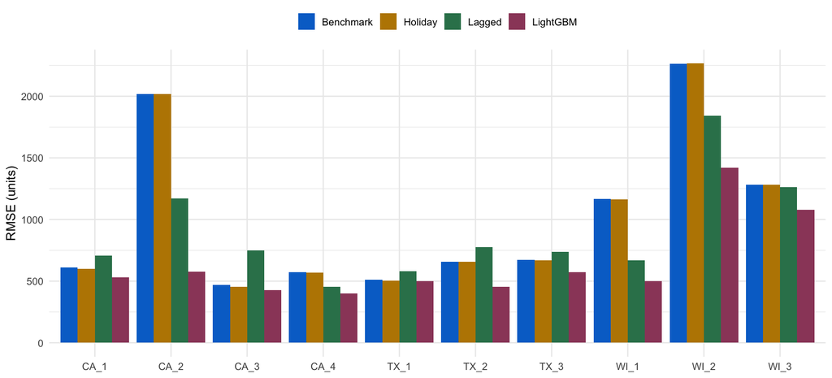

RMSE by store and model

| store_id | model | RMSE | MAE | mean_error | improvement_percent |
| --- | --- | --- | --- | --- | --- |
| CA_1 | Benchmark | 612.689 | 530.229 | 511.974 | 0.000 |
| CA_2 | Benchmark | 2019.235 | 1909.906 | 1909.906 | 0.000 |
| CA_3 | Benchmark | 467.791 | 379.988 | 148.701 | 0.000 |
| CA_4 | Benchmark | 573.106 | 525.647 | 525.647 | 0.000 |
| TX_1 | Benchmark | 511.440 | 432.199 | 383.807 | 0.000 |
| TX_2 | Benchmark | 657.168 | 571.373 | 571.373 | 0.000 |
| TX_3 | Benchmark | 671.265 | 564.040 | 561.550 | 0.000 |
| WI_1 | Benchmark | 1168.378 | 1096.128 | 1096.128 | 0.000 |
| WI_2 | Benchmark | 2264.042 | 1999.275 | 1999.275 | 0.000 |
| WI_3 | Benchmark | 1280.967 | 1141.686 | 1141.686 | 0.000 |
| CA_1 | Holiday | 601.083 | 520.732 | 509.380 | 1.894 |
| CA_2 | Holiday | 2017.624 | 1911.002 | 1911.002 | 0.080 |
| CA_3 | Holiday | 455.058 | 370.802 | 137.090 | 2.722 |
| CA_4 | Holiday | 568.631 | 521.797 | 521.797 | 0.781 |
| TX_1 | Holiday | 503.413 | 425.430 | 377.120 | 1.569 |
| TX_2 | Holiday | 656.436 | 574.005 | 574.005 | 0.111 |
| TX_3 | Holiday | 668.499 | 561.490 | 559.202 | 0.412 |
| WI_1 | Holiday | 1162.440 | 1093.549 | 1093.549 | 0.508 |
| WI_2 | Holiday | 2265.674 | 2002.510 | 2002.510 | -0.072 |
| WI_3 | Holiday | 1281.244 | 1145.502 | 1145.502 | -0.022 |
| CA_1 | Lagged | 706.260 | 607.679 | 595.663 | -15.272 |
| CA_2 | Lagged | 1169.070 | 971.492 | 956.054 | 42.103 |
| CA_3 | Lagged | 749.797 | 643.956 | 596.074 | -60.285 |
| CA_4 | Lagged | 454.025 | 382.620 | 362.107 | 20.778 |
| TX_1 | Lagged | 579.194 | 480.368 | 447.474 | -13.248 |
| TX_2 | Lagged | 775.120 | 677.070 | 677.070 | -17.949 |
| TX_3 | Lagged | 736.641 | 650.306 | 650.306 | -9.739 |
| WI_1 | Lagged | 666.921 | 520.625 | 484.941 | 42.919 |
| WI_2 | Lagged | 1841.832 | 1557.289 | 1496.334 | 18.649 |
| WI_3 | Lagged | 1263.346 | 1093.310 | 1088.336 | 1.376 |
| CA_1 | LightGBM | 532.273 | 475.029 | 439.962 | 13.125 |
| CA_2 | LightGBM | 577.358 | 484.296 | 441.486 | 71.407 |
| CA_3 | LightGBM | 426.911 | 322.048 | 157.127 | 8.739 |
| CA_4 | LightGBM | 399.056 | 356.350 | 342.741 | 30.370 |
| TX_1 | LightGBM | 498.442 | 421.920 | 329.310 | 2.541 |
| TX_2 | LightGBM | 454.041 | 384.978 | 301.494 | 30.909 |
| TX_3 | LightGBM | 574.148 | 475.962 | 454.200 | 14.468 |
| WI_1 | LightGBM | 498.503 | 447.906 | 388.988 | 57.334 |
| WI_2 | LightGBM | 1418.616 | 1118.535 | 998.458 | 37.341 |
| WI_3 | LightGBM | 1079.018 | 889.112 | 877.287 | 15.765 |

## 4.1 Validation performance and tuning

Differences between these earlier windows and the final holdout help identify time-specific performance. We report every searched LightGBM configuration, including unsuccessful ones, rather than hiding models that do not improve the benchmark.

| model | fold | n | RMSE | MAE | mean_error |
| --- | --- | --- | --- | --- | --- |
| Benchmark | 1 | 280 | 882.723 | 666.187 | 636.464 |
| Benchmark | 2 | 280 | 985.182 | 749.567 | 712.051 |
| Benchmark | 3 | 280 | 993.506 | 717.139 | 662.499 |
| Holiday | 1 | 280 | 878.413 | 661.190 | 630.658 |
| Holiday | 2 | 280 | 966.234 | 731.022 | 681.998 |
| Holiday | 3 | 280 | 1013.778 | 741.934 | 682.510 |
| Lagged | 1 | 280 | 807.819 | 611.026 | 577.414 |
| Lagged | 2 | 280 | 791.879 | 588.620 | 515.054 |
| Lagged | 3 | 280 | 820.922 | 602.357 | 509.479 |
| LightGBM | 1 | 280 | 600.762 | 447.762 | 372.978 |
| LightGBM | 2 | 280 | 671.127 | 480.964 | 367.174 |
| LightGBM | 3 | 280 | 612.770 | 413.440 | 346.167 |

| config | n | RMSE | MAE | mean_error | leaves | min_leaf | rounds |
| --- | --- | --- | --- | --- | --- | --- | --- |
| 4 | 840 | 628.971 | 447.389 | 362.106 | 15 | 50 | 100 |
| 2 | 840 | 645.906 | 459.329 | 381.145 | 15 | 20 | 100 |
| 3 | 840 | 645.954 | 464.517 | 377.379 | 7 | 50 | 100 |
| 5 | 840 | 646.202 | 462.152 | 380.775 | 7 | 20 | 300 |
| 1 | 840 | 652.640 | 468.934 | 390.166 | 7 | 20 | 100 |
| 11 | 840 | 654.919 | 465.799 | 376.282 | 7 | 50 | 600 |
| 8 | 840 | 654.993 | 464.945 | 370.345 | 15 | 50 | 300 |
| 7 | 840 | 656.797 | 468.980 | 386.511 | 7 | 50 | 300 |
| 6 | 840 | 660.769 | 473.475 | 385.024 | 15 | 20 | 300 |
| 9 | 840 | 666.827 | 473.978 | 384.880 | 7 | 20 | 600 |
| 10 | 840 | 691.913 | 498.255 | 401.064 | 15 | 20 | 600 |
| 12 | 840 | 709.657 | 494.701 | 393.515 | 15 | 50 | 600 |

## 4.2 Common-sample comparison

Benchmark and holiday OLS are also refitted without the first seven dates, matching the lagged model’s sample. These diagnostic refits are not substitutes for the preserved original benchmark.

| model | store_id | n | RMSE | MAE | mean_error |
| --- | --- | --- | --- | --- | --- |
| Benchmark_common | Overall | 280 | 1195.636 | 916.665 | 888.462 |
| Holiday_common | Overall | 280 | 1193.109 | 914.092 | 886.297 |
| Lagged | Overall | 280 | 977.034 | 758.472 | 735.436 |

# 5 Actual versus predicted sales

Every panel uses the same 28 dates. Individual store figures keep the same vertical scale across their four models. The overview allows different scales across stores, so visual amplitude should not be compared across store rows without checking axes. Negative predictions, if present, are retained rather than clipped.

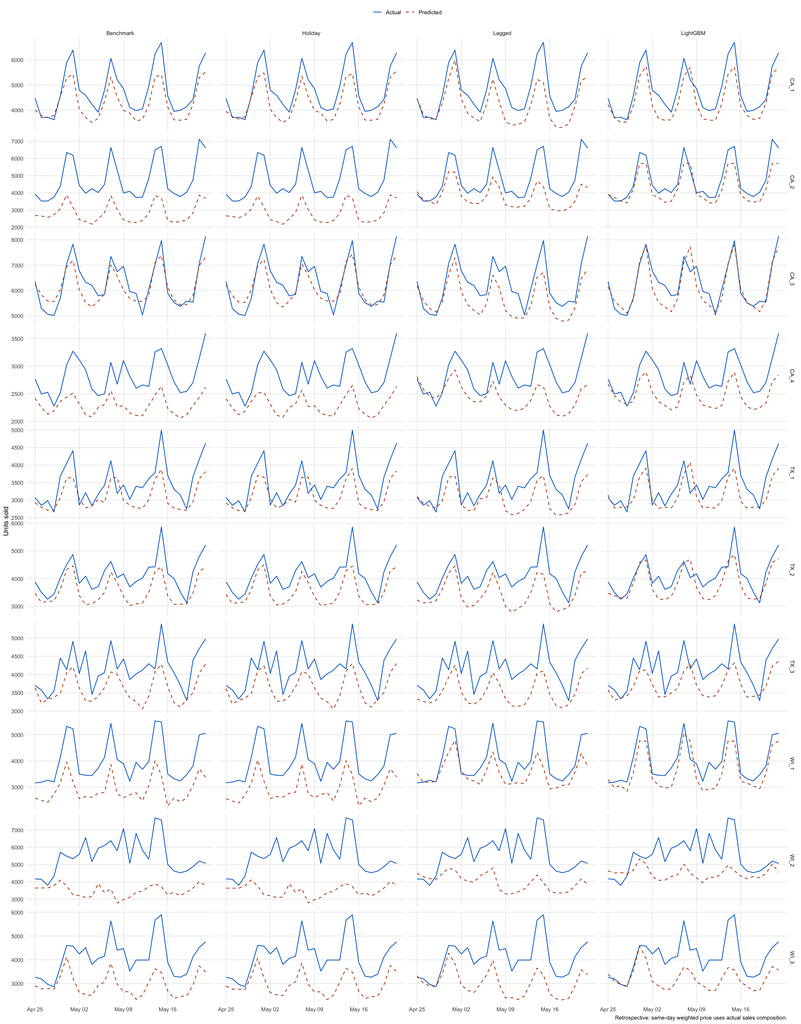

All stores and all four models

## 5.1 CA_1

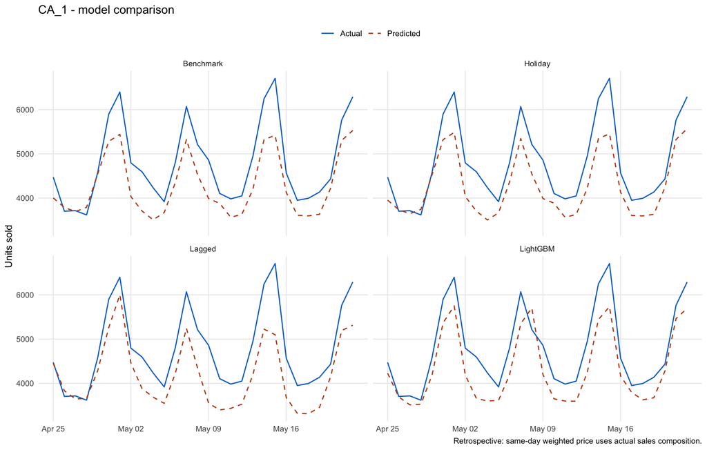

CA_1 model comparison

## 5.2 CA_2

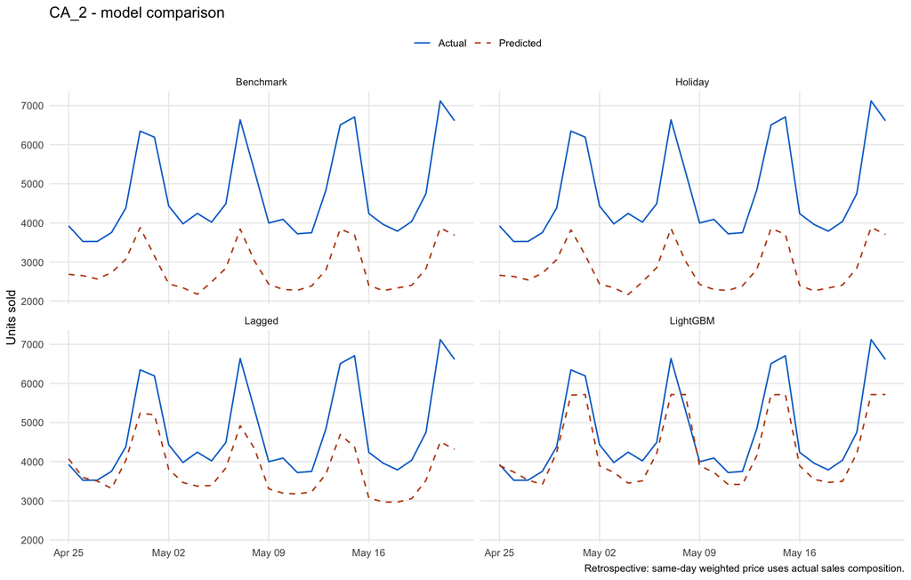

CA_2 model comparison

## 5.3 CA_3

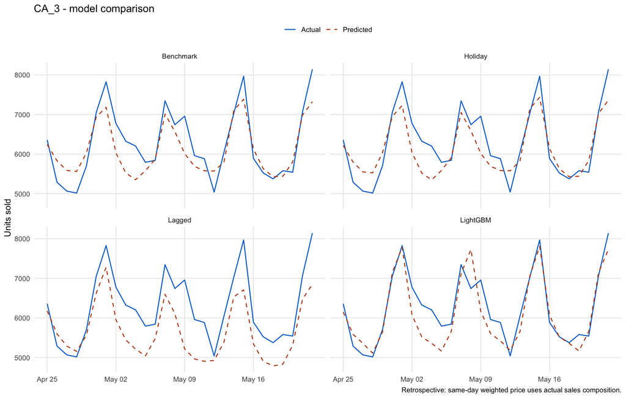

CA_3 model comparison

## 5.4 CA_4

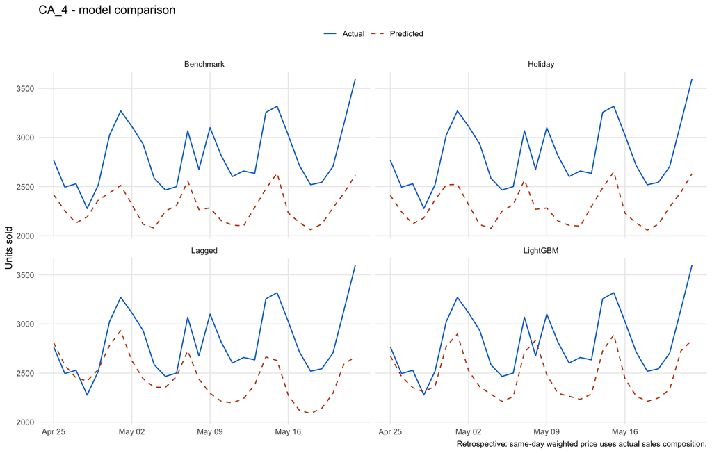

CA_4 model comparison

## 5.5 TX_1

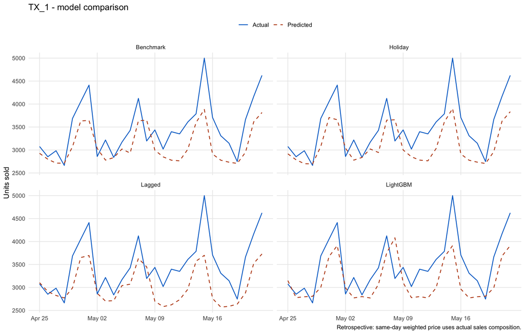

TX_1 model comparison

## 5.6 TX_2

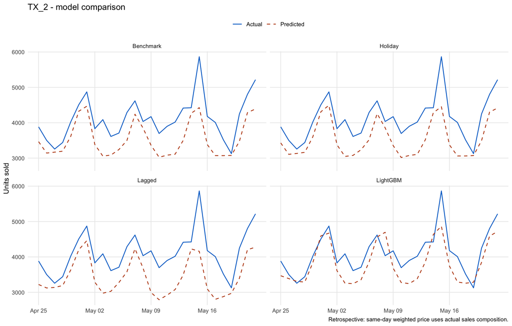

TX_2 model comparison

## 5.7 TX_3

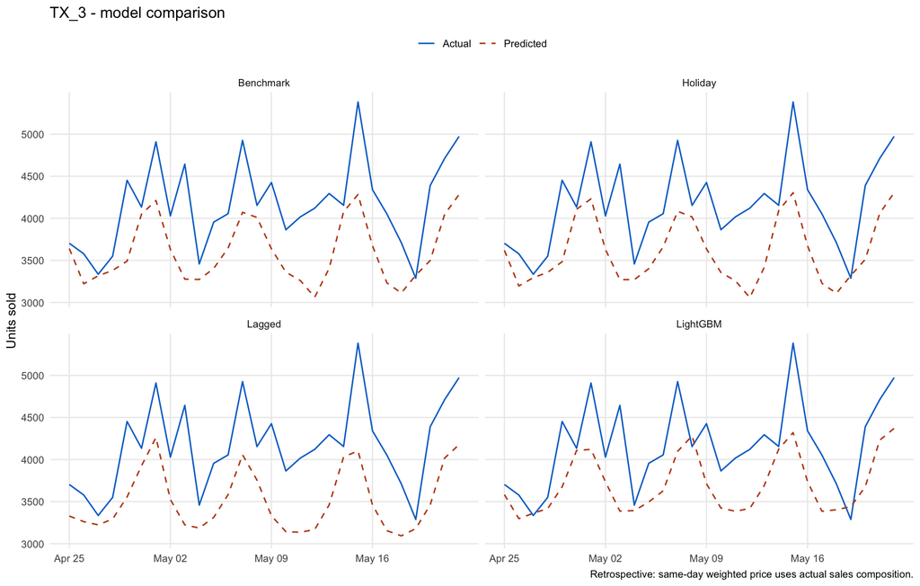

TX_3 model comparison

## 5.8 WI_1

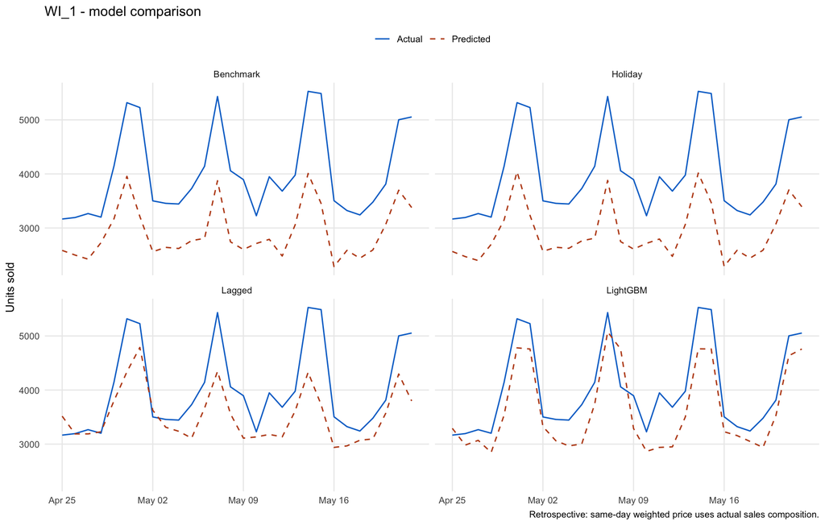

WI_1 model comparison

## 5.9 WI_2

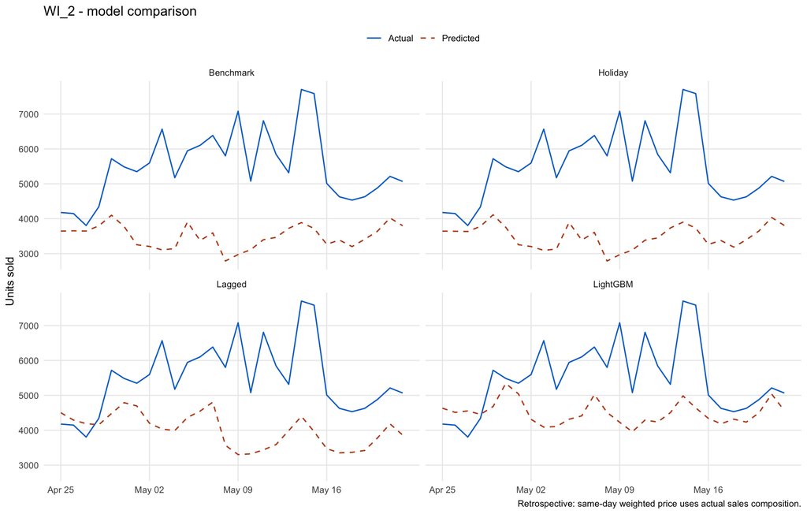

WI_2 model comparison

## 5.10 WI_3

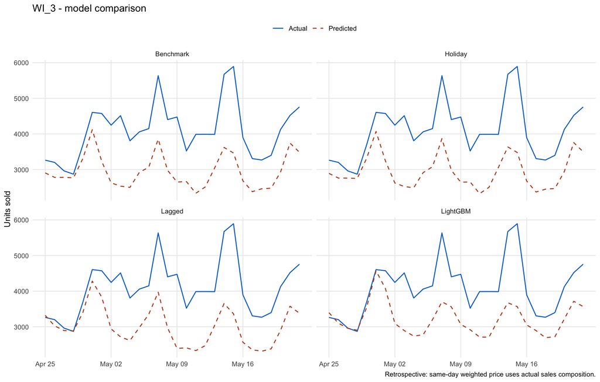

WI_3 model comparison

# 6 Coefficients and model interpretation

OLS coefficients are conditional associations, not causal effects or price elasticities. The weighted price can move because the product mix changes. Reported standard errors, t statistics, and p-values are conventional OLS quantities and do not correct for serial correlation or heteroskedasticity. Lag coefficients describe persistence conditional on the other predictors, not independently identified mechanisms.

| store_id | model | n_train | rank | r_squared | adjusted_r_squared |
| --- | --- | --- | --- | --- | --- |
| CA_1 | Benchmark | 1913 | 49 | 0.641 | 0.632 |
| CA_1 | Holiday | 1913 | 61 | 0.669 | 0.659 |
| CA_1 | Lagged | 1906 | 63 | 0.878 | 0.874 |
| CA_2 | Benchmark | 1913 | 49 | 0.535 | 0.523 |
| CA_2 | Holiday | 1913 | 61 | 0.540 | 0.526 |
| CA_2 | Lagged | 1906 | 63 | 0.891 | 0.888 |
| CA_3 | Benchmark | 1913 | 49 | 0.487 | 0.474 |
| CA_3 | Holiday | 1913 | 61 | 0.510 | 0.494 |
| CA_3 | Lagged | 1906 | 63 | 0.836 | 0.831 |
| CA_4 | Benchmark | 1913 | 49 | 0.399 | 0.383 |
| CA_4 | Holiday | 1913 | 61 | 0.421 | 0.403 |
| CA_4 | Lagged | 1906 | 63 | 0.832 | 0.827 |
| TX_1 | Benchmark | 1913 | 49 | 0.585 | 0.575 |
| TX_1 | Holiday | 1913 | 61 | 0.603 | 0.590 |
| TX_1 | Lagged | 1906 | 63 | 0.754 | 0.746 |
| TX_2 | Benchmark | 1913 | 49 | 0.546 | 0.535 |
| TX_2 | Holiday | 1913 | 61 | 0.563 | 0.549 |
| TX_2 | Lagged | 1906 | 63 | 0.752 | 0.744 |
| TX_3 | Benchmark | 1913 | 49 | 0.601 | 0.591 |
| TX_3 | Holiday | 1913 | 61 | 0.622 | 0.609 |
| TX_3 | Lagged | 1906 | 63 | 0.766 | 0.758 |
| WI_1 | Benchmark | 1913 | 49 | 0.447 | 0.433 |
| WI_1 | Holiday | 1913 | 61 | 0.456 | 0.438 |
| WI_1 | Lagged | 1906 | 63 | 0.880 | 0.876 |
| WI_2 | Benchmark | 1913 | 49 | 0.253 | 0.234 |
| WI_2 | Holiday | 1913 | 61 | 0.271 | 0.247 |
| WI_2 | Lagged | 1906 | 63 | 0.805 | 0.799 |
| WI_3 | Benchmark | 1913 | 49 | 0.444 | 0.430 |
| WI_3 | Holiday | 1913 | 61 | 0.469 | 0.452 |
| WI_3 | Lagged | 1906 | 63 | 0.716 | 0.706 |

## 6.1 CA_1 coefficients

### 6.1.1 Benchmark

| term | estimate | std_error | t_statistic | p_value |
| --- | --- | --- | --- | --- |
| (Intercept) | 830.371 | 217.637 | 3.815 | 0.000 |
| weighted_price | 952.483 | 70.885 | 13.437 | 0.000 |
| weekday_factorTuesday | -343.920 | 53.160 | -6.470 | 0.000 |
| weekday_factorWednesday | -436.196 | 53.631 | -8.133 | 0.000 |
| weekday_factorThursday | -372.447 | 53.461 | -6.967 | 0.000 |
| weekday_factorFriday | 262.204 | 53.009 | 4.946 | 0.000 |
| weekday_factorSaturday | 1270.744 | 52.941 | 24.003 | 0.000 |
| weekday_factorSunday | 1379.429 | 54.291 | 25.408 | 0.000 |
| month_factorFebruary | 61.222 | 70.809 | 0.865 | 0.387 |
| month_factorMarch | 82.614 | 68.011 | 1.215 | 0.225 |
| month_factorApril | 214.422 | 68.862 | 3.114 | 0.002 |
| month_factorMay | 122.035 | 71.640 | 1.703 | 0.089 |
| month_factorJune | 389.731 | 72.091 | 5.406 | 0.000 |
| month_factorJuly | 367.922 | 70.621 | 5.210 | 0.000 |
| month_factorAugust | 453.964 | 70.117 | 6.474 | 0.000 |
| month_factorSeptember | 250.581 | 71.009 | 3.529 | 0.000 |
| month_factorOctober | 234.989 | 71.200 | 3.300 | 0.001 |
| month_factorNovember | 27.599 | 71.627 | 0.385 | 0.700 |
| month_factorDecember | 66.332 | 71.056 | 0.934 | 0.351 |
| event_Chanukah.End | 43.914 | 274.217 | 0.160 | 0.873 |
| event_Christmas | -3715.687 | 274.128 | -13.555 | 0.000 |
| event_Cinco.De.Mayo | 97.752 | 280.605 | 0.348 | 0.728 |
| event_ColumbusDay | 292.638 | 276.404 | 1.059 | 0.290 |
| event_Easter | -906.171 | 267.760 | -3.384 | 0.001 |
| event_Eid.al.Fitr | 10.854 | 271.723 | 0.040 | 0.968 |
| event_EidAlAdha | -35.917 | 271.485 | -0.132 | 0.895 |
| event_Father.s.day | -812.197 | 280.394 | -2.897 | 0.004 |
| event_Halloween | -640.907 | 274.071 | -2.338 | 0.019 |
| event_IndependenceDay | -77.792 | 273.963 | -0.284 | 0.776 |
| event_LaborDay | 1215.088 | 276.276 | 4.398 | 0.000 |
| event_LentStart | -79.551 | 251.039 | -0.317 | 0.751 |
| event_LentWeek2 | -80.111 | 251.035 | -0.319 | 0.750 |
| event_MartinLutherKingDay | 417.661 | 276.356 | 1.511 | 0.131 |
| event_MemorialDay | 279.175 | 276.593 | 1.009 | 0.313 |
| event_Mother.s.day | -905.173 | 276.428 | -3.275 | 0.001 |
| event_NBAFinalsEnd | -284.262 | 278.680 | -1.020 | 0.308 |
| event_NBAFinalsStart | -220.126 | 273.573 | -0.805 | 0.421 |
| event_NewYear | -804.983 | 274.045 | -2.937 | 0.003 |
| event_OrthodoxChristmas | 288.594 | 274.084 | 1.053 | 0.293 |
| event_OrthodoxEaster | -11.490 | 298.865 | -0.038 | 0.969 |
| event_Pesach.End | -47.090 | 274.300 | -0.172 | 0.864 |
| event_PresidentsDay | 219.518 | 253.379 | 0.866 | 0.386 |
| event_Purim.End | -103.485 | 249.988 | -0.414 | 0.679 |
| event_Ramadan.starts | -20.518 | 271.106 | -0.076 | 0.940 |
| event_StPatricksDay | -291.801 | 250.250 | -1.166 | 0.244 |
| event_SuperBowl | -249.908 | 253.444 | -0.986 | 0.324 |
| event_Thanksgiving | -831.159 | 276.825 | -3.002 | 0.003 |
| event_ValentinesDay | -391.558 | 250.887 | -1.561 | 0.119 |
| event_VeteransDay | 257.884 | 274.161 | 0.941 | 0.347 |

### 6.1.2 Holiday

| term | estimate | std_error | t_statistic | p_value |
| --- | --- | --- | --- | --- |
| (Intercept) | 677.945 | 210.464 | 3.221 | 0.001 |
| weighted_price | 984.429 | 68.420 | 14.388 | 0.000 |
| weekday_factorTuesday | -348.642 | 51.274 | -6.800 | 0.000 |
| weekday_factorWednesday | -438.590 | 51.726 | -8.479 | 0.000 |
| weekday_factorThursday | -374.752 | 51.842 | -7.229 | 0.000 |
| weekday_factorFriday | 282.972 | 51.533 | 5.491 | 0.000 |
| weekday_factorSaturday | 1290.034 | 51.502 | 25.048 | 0.000 |
| weekday_factorSunday | 1412.798 | 52.657 | 26.830 | 0.000 |
| month_factorFebruary | 111.678 | 70.162 | 1.592 | 0.112 |
| month_factorMarch | 112.749 | 67.743 | 1.664 | 0.096 |
| month_factorApril | 218.010 | 70.051 | 3.112 | 0.002 |
| month_factorMay | 172.868 | 70.935 | 2.437 | 0.015 |
| month_factorJune | 441.208 | 71.350 | 6.184 | 0.000 |
| month_factorJuly | 298.135 | 73.950 | 4.032 | 0.000 |
| month_factorAugust | 495.694 | 69.767 | 7.105 | 0.000 |
| month_factorSeptember | 260.934 | 73.010 | 3.574 | 0.000 |
| month_factorOctober | 285.428 | 70.517 | 4.048 | 0.000 |
| month_factorNovember | 122.866 | 75.055 | 1.637 | 0.102 |
| month_factorDecember | 130.667 | 76.823 | 1.701 | 0.089 |
| event_Chanukah.End | 63.466 | 265.451 | 0.239 | 0.811 |
| event_Christmas | -3727.804 | 265.689 | -14.031 | 0.000 |
| event_Cinco.De.Mayo | 96.612 | 270.152 | 0.358 | 0.721 |
| event_ColumbusDay | 299.315 | 266.131 | 1.125 | 0.261 |
| event_Easter | -895.618 | 257.899 | -3.473 | 0.001 |
| event_Eid.al.Fitr | 66.180 | 261.805 | 0.253 | 0.800 |
| event_EidAlAdha | -33.757 | 261.440 | -0.129 | 0.897 |
| event_Father.s.day | -835.781 | 269.970 | -3.096 | 0.002 |
| event_Halloween | -639.367 | 263.856 | -2.423 | 0.015 |
| event_IndependenceDay | 47.880 | 264.837 | 0.181 | 0.857 |
| event_LaborDay | 1263.388 | 266.603 | 4.739 | 0.000 |
| event_LentStart | -62.009 | 241.723 | -0.257 | 0.798 |
| event_LentWeek2 | -61.839 | 241.719 | -0.256 | 0.798 |
| event_MartinLutherKingDay | 476.482 | 266.616 | 1.787 | 0.074 |
| event_MemorialDay | 283.840 | 266.315 | 1.066 | 0.287 |
| event_Mother.s.day | -930.681 | 266.151 | -3.497 | 0.000 |
| event_NBAFinalsEnd | -284.683 | 268.296 | -1.061 | 0.289 |
| event_NBAFinalsStart | -207.914 | 263.387 | -0.789 | 0.430 |
| event_NewYear | -755.845 | 264.347 | -2.859 | 0.004 |
| event_OrthodoxChristmas | 345.144 | 264.392 | 1.305 | 0.192 |
| event_OrthodoxEaster | -3.709 | 287.841 | -0.013 | 0.990 |
| event_Pesach.End | 21.997 | 275.686 | 0.080 | 0.936 |
| event_PresidentsDay | 226.028 | 243.969 | 0.926 | 0.354 |
| event_Purim.End | -206.858 | 241.513 | -0.857 | 0.392 |
| event_Ramadan.starts | 28.568 | 261.184 | 0.109 | 0.913 |
| event_StPatricksDay | -272.134 | 240.977 | -1.129 | 0.259 |
| event_SuperBowl | -273.831 | 244.025 | -1.122 | 0.262 |
| event_Thanksgiving | -857.092 | 267.538 | -3.204 | 0.001 |
| event_ValentinesDay | -391.577 | 241.536 | -1.621 | 0.105 |
| event_VeteransDay | 210.696 | 265.109 | 0.795 | 0.427 |
| window_Christmas_before | 329.604 | 160.539 | 2.053 | 0.040 |
| window_Christmas_after | -486.360 | 160.405 | -3.032 | 0.002 |
| window_Thanksgiving_before | 651.632 | 160.308 | 4.065 | 0.000 |
| window_Thanksgiving_after | -1160.920 | 158.969 | -7.303 | 0.000 |
| window_Easter_before | 665.940 | 142.543 | 4.672 | 0.000 |
| window_Easter_after | -27.884 | 149.615 | -0.186 | 0.852 |
| window_IndependenceDay_before | 856.960 | 158.904 | 5.393 | 0.000 |
| window_IndependenceDay_after | 338.633 | 158.933 | 2.131 | 0.033 |
| window_LaborDay_before | 203.690 | 154.984 | 1.314 | 0.189 |
| window_LaborDay_after | 264.184 | 159.280 | 1.659 | 0.097 |
| window_NewYear_before | 69.260 | 160.225 | 0.432 | 0.666 |
| window_NewYear_after | 466.682 | 158.259 | 2.949 | 0.003 |

### 6.1.3 Lagged

| term | estimate | std_error | t_statistic | p_value |
| --- | --- | --- | --- | --- |
| (Intercept) | -296.655 | 132.506 | -2.239 | 0.025 |
| weighted_price | -9.538 | 45.738 | -0.209 | 0.835 |
| weekday_factorTuesday | 467.126 | 36.433 | 12.822 | 0.000 |
| weekday_factorWednesday | 645.047 | 40.523 | 15.918 | 0.000 |
| weekday_factorThursday | 764.011 | 42.152 | 18.125 | 0.000 |
| weekday_factorFriday | 1168.447 | 45.160 | 25.874 | 0.000 |
| weekday_factorSaturday | 1512.240 | 47.547 | 31.805 | 0.000 |
| weekday_factorSunday | 1100.205 | 39.396 | 27.927 | 0.000 |
| month_factorFebruary | 92.898 | 43.239 | 2.148 | 0.032 |
| month_factorMarch | 95.973 | 41.516 | 2.312 | 0.021 |
| month_factorApril | 63.306 | 42.961 | 1.474 | 0.141 |
| month_factorMay | 99.318 | 43.450 | 2.286 | 0.022 |
| month_factorJune | 153.100 | 44.002 | 3.479 | 0.001 |
| month_factorJuly | 8.545 | 45.595 | 0.187 | 0.851 |
| month_factorAugust | 119.031 | 43.238 | 2.753 | 0.006 |
| month_factorSeptember | 34.083 | 44.876 | 0.759 | 0.448 |
| month_factorOctober | 74.021 | 43.327 | 1.708 | 0.088 |
| month_factorNovember | 63.104 | 45.920 | 1.374 | 0.170 |
| month_factorDecember | 164.830 | 47.084 | 3.501 | 0.000 |
| event_Chanukah.End | -180.100 | 161.669 | -1.114 | 0.265 |
| event_Christmas | -3764.559 | 161.674 | -23.285 | 0.000 |
| event_Cinco.De.Mayo | -157.075 | 164.637 | -0.954 | 0.340 |
| event_ColumbusDay | 80.281 | 161.927 | 0.496 | 0.620 |
| event_Easter | -1556.019 | 157.520 | -9.878 | 0.000 |
| event_Eid.al.Fitr | -63.418 | 159.292 | -0.398 | 0.691 |
| event_EidAlAdha | -39.517 | 159.098 | -0.248 | 0.804 |
| event_Father.s.day | -1000.701 | 164.244 | -6.093 | 0.000 |
| event_Halloween | -423.621 | 160.640 | -2.637 | 0.008 |
| event_IndependenceDay | -599.485 | 163.039 | -3.677 | 0.000 |
| event_LaborDay | 1438.270 | 162.320 | 8.861 | 0.000 |
| event_LentStart | -53.091 | 147.073 | -0.361 | 0.718 |
| event_LentWeek2 | 106.244 | 147.154 | 0.722 | 0.470 |
| event_MartinLutherKingDay | 608.378 | 162.303 | 3.748 | 0.000 |
| event_MemorialDay | 773.149 | 162.396 | 4.761 | 0.000 |
| event_Mother.s.day | -1276.548 | 162.052 | -7.877 | 0.000 |
| event_NBAFinalsEnd | -137.279 | 163.269 | -0.841 | 0.401 |
| event_NBAFinalsStart | -225.083 | 160.371 | -1.404 | 0.161 |
| event_NewYear | 200.065 | 175.161 | 1.142 | 0.254 |
| event_OrthodoxChristmas | 136.667 | 160.948 | 0.849 | 0.396 |
| event_OrthodoxEaster | 333.119 | 175.277 | 1.901 | 0.058 |
| event_Pesach.End | -81.373 | 167.738 | -0.485 | 0.628 |
| event_PresidentsDay | 396.096 | 148.755 | 2.663 | 0.008 |
| event_Purim.End | -220.777 | 146.900 | -1.503 | 0.133 |
| event_Ramadan.starts | 132.297 | 158.919 | 0.832 | 0.405 |
| event_StPatricksDay | -324.070 | 146.611 | -2.210 | 0.027 |
| event_SuperBowl | -970.392 | 149.977 | -6.470 | 0.000 |
| event_Thanksgiving | -1534.411 | 164.313 | -9.338 | 0.000 |
| event_ValentinesDay | -632.426 | 147.067 | -4.300 | 0.000 |
| event_VeteransDay | -59.931 | 161.370 | -0.371 | 0.710 |
| window_Christmas_before | -37.734 | 97.934 | -0.385 | 0.700 |
| window_Christmas_after | 341.571 | 101.991 | 3.349 | 0.001 |
| window_Thanksgiving_before | 541.865 | 97.896 | 5.535 | 0.000 |
| window_Thanksgiving_after | -472.258 | 98.665 | -4.786 | 0.000 |
| window_Easter_before | 454.649 | 87.233 | 5.212 | 0.000 |
| window_Easter_after | 183.452 | 91.177 | 2.012 | 0.044 |
| window_IndependenceDay_before | 699.443 | 97.503 | 7.174 | 0.000 |
| window_IndependenceDay_after | 288.260 | 96.774 | 2.979 | 0.003 |
| window_LaborDay_before | 57.711 | 94.379 | 0.611 | 0.541 |
| window_LaborDay_after | -10.028 | 97.870 | -0.102 | 0.918 |
| window_NewYear_before | -7.502 | 97.825 | -0.077 | 0.939 |
| window_NewYear_after | 556.402 | 96.659 | 5.756 | 0.000 |
| lag_1 | 0.549 | 0.017 | 31.834 | 0.000 |
| lag_7 | 0.312 | 0.017 | 18.220 | 0.000 |

## 6.2 CA_2 coefficients

### 6.2.1 Benchmark

| term | estimate | std_error | t_statistic | p_value |
| --- | --- | --- | --- | --- |
| (Intercept) | 646.367 | 255.265 | 2.532 | 0.011 |
| weighted_price | 594.708 | 79.644 | 7.467 | 0.000 |
| weekday_factorTuesday | -87.216 | 54.857 | -1.590 | 0.112 |
| weekday_factorWednesday | -101.396 | 55.332 | -1.832 | 0.067 |
| weekday_factorThursday | -7.364 | 55.192 | -0.133 | 0.894 |
| weekday_factorFriday | 452.650 | 54.725 | 8.271 | 0.000 |
| weekday_factorSaturday | 1425.209 | 54.665 | 26.072 | 0.000 |
| weekday_factorSunday | 1273.116 | 56.113 | 22.688 | 0.000 |
| month_factorFebruary | 39.740 | 73.154 | 0.543 | 0.587 |
| month_factorMarch | 81.496 | 70.295 | 1.159 | 0.246 |
| month_factorApril | 91.974 | 71.139 | 1.293 | 0.196 |
| month_factorMay | -211.774 | 74.028 | -2.861 | 0.004 |
| month_factorJune | 167.682 | 74.905 | 2.239 | 0.025 |
| month_factorJuly | 254.639 | 73.517 | 3.464 | 0.001 |
| month_factorAugust | 296.439 | 72.744 | 4.075 | 0.000 |
| month_factorSeptember | 251.828 | 73.622 | 3.421 | 0.001 |
| month_factorOctober | 165.331 | 73.514 | 2.249 | 0.025 |
| month_factorNovember | -54.164 | 74.007 | -0.732 | 0.464 |
| month_factorDecember | 57.482 | 73.321 | 0.784 | 0.433 |
| event_Chanukah.End | 89.374 | 283.172 | 0.316 | 0.752 |
| event_Christmas | -2019.843 | 304.639 | -6.630 | 0.000 |
| event_Cinco.De.Mayo | 164.548 | 289.745 | 0.568 | 0.570 |
| event_ColumbusDay | 57.050 | 285.407 | 0.200 | 0.842 |
| event_Easter | 144.130 | 276.475 | 0.521 | 0.602 |
| event_Eid.al.Fitr | 119.176 | 280.579 | 0.425 | 0.671 |
| event_EidAlAdha | 14.691 | 280.450 | 0.052 | 0.958 |
| event_Father.s.day | -403.990 | 289.507 | -1.395 | 0.163 |
| event_Halloween | -158.624 | 283.005 | -0.560 | 0.575 |
| event_IndependenceDay | -52.000 | 282.834 | -0.184 | 0.854 |
| event_LaborDay | 1091.645 | 285.281 | 3.827 | 0.000 |
| event_LentStart | 53.413 | 259.257 | 0.206 | 0.837 |
| event_LentWeek2 | 81.058 | 259.297 | 0.313 | 0.755 |
| event_MartinLutherKingDay | 518.928 | 285.448 | 1.818 | 0.069 |
| event_MemorialDay | 750.997 | 285.567 | 2.630 | 0.009 |
| event_Mother.s.day | -642.655 | 285.441 | -2.251 | 0.024 |
| event_NBAFinalsEnd | -90.805 | 287.662 | -0.316 | 0.752 |
| event_NBAFinalsStart | 42.342 | 282.489 | 0.150 | 0.881 |
| event_NewYear | -355.449 | 282.977 | -1.256 | 0.209 |
| event_OrthodoxChristmas | 5.654 | 283.023 | 0.020 | 0.984 |
| event_OrthodoxEaster | -559.325 | 308.613 | -1.812 | 0.070 |
| event_Pesach.End | -225.367 | 283.309 | -0.795 | 0.426 |
| event_PresidentsDay | 498.892 | 261.799 | 1.906 | 0.057 |
| event_Purim.End | 10.903 | 258.116 | 0.042 | 0.966 |
| event_Ramadan.starts | 36.704 | 279.973 | 0.131 | 0.896 |
| event_StPatricksDay | 108.761 | 258.387 | 0.421 | 0.674 |
| event_SuperBowl | -438.400 | 261.680 | -1.675 | 0.094 |
| event_Thanksgiving | -951.818 | 285.458 | -3.334 | 0.001 |
| event_ValentinesDay | -285.706 | 259.008 | -1.103 | 0.270 |
| event_VeteransDay | 229.618 | 283.130 | 0.811 | 0.417 |

### 6.2.2 Holiday

| term | estimate | std_error | t_statistic | p_value |
| --- | --- | --- | --- | --- |
| (Intercept) | 563.552 | 256.024 | 2.201 | 0.028 |
| weighted_price | 617.210 | 79.677 | 7.746 | 0.000 |
| weekday_factorTuesday | -85.566 | 54.810 | -1.561 | 0.119 |
| weekday_factorWednesday | -100.261 | 55.278 | -1.814 | 0.070 |
| weekday_factorThursday | 0.006 | 55.444 | 0.000 | 1.000 |
| weekday_factorFriday | 470.256 | 55.116 | 8.532 | 0.000 |
| weekday_factorSaturday | 1443.477 | 55.085 | 26.204 | 0.000 |
| weekday_factorSunday | 1292.674 | 56.360 | 22.936 | 0.000 |
| month_factorFebruary | 43.975 | 75.076 | 0.586 | 0.558 |
| month_factorMarch | 79.240 | 72.514 | 1.093 | 0.275 |
| month_factorApril | 76.474 | 74.946 | 1.020 | 0.308 |
| month_factorMay | -207.232 | 75.922 | -2.730 | 0.006 |
| month_factorJune | 174.143 | 76.771 | 2.268 | 0.023 |
| month_factorJuly | 228.150 | 79.572 | 2.867 | 0.004 |
| month_factorAugust | 304.098 | 74.955 | 4.057 | 0.000 |
| month_factorSeptember | 270.026 | 78.398 | 3.444 | 0.001 |
| month_factorOctober | 169.421 | 75.422 | 2.246 | 0.025 |
| month_factorNovember | -18.629 | 80.314 | -0.232 | 0.817 |
| month_factorDecember | 69.623 | 82.115 | 0.848 | 0.397 |
| event_Chanukah.End | 98.849 | 283.947 | 0.348 | 0.728 |
| event_Christmas | -1996.992 | 305.994 | -6.526 | 0.000 |
| event_Cinco.De.Mayo | 163.978 | 288.945 | 0.568 | 0.570 |
| event_ColumbusDay | 65.209 | 284.642 | 0.229 | 0.819 |
| event_Easter | 146.711 | 275.832 | 0.532 | 0.595 |
| event_Eid.al.Fitr | 131.248 | 280.021 | 0.469 | 0.639 |
| event_EidAlAdha | 8.532 | 279.746 | 0.030 | 0.976 |
| event_Father.s.day | -414.552 | 288.728 | -1.436 | 0.151 |
| event_Halloween | -157.762 | 282.217 | -0.559 | 0.576 |
| event_IndependenceDay | -17.981 | 283.203 | -0.063 | 0.949 |
| event_LaborDay | 1088.476 | 285.157 | 3.817 | 0.000 |
| event_LentStart | 65.283 | 258.580 | 0.252 | 0.801 |
| event_LentWeek2 | 93.489 | 258.622 | 0.361 | 0.718 |
| event_MartinLutherKingDay | 530.031 | 285.252 | 1.858 | 0.063 |
| event_MemorialDay | 758.569 | 284.800 | 2.664 | 0.008 |
| event_Mother.s.day | -653.913 | 284.674 | -2.297 | 0.022 |
| event_NBAFinalsEnd | -90.801 | 286.864 | -0.317 | 0.752 |
| event_NBAFinalsStart | 46.618 | 281.714 | 0.165 | 0.869 |
| event_NewYear | -351.396 | 282.737 | -1.243 | 0.214 |
| event_OrthodoxChristmas | 13.584 | 282.793 | 0.048 | 0.962 |
| event_OrthodoxEaster | -556.039 | 307.878 | -1.806 | 0.071 |
| event_Pesach.End | -274.990 | 294.898 | -0.932 | 0.351 |
| event_PresidentsDay | 505.570 | 261.102 | 1.936 | 0.053 |
| event_Purim.End | -14.166 | 258.295 | -0.055 | 0.956 |
| event_Ramadan.starts | 50.938 | 279.395 | 0.182 | 0.855 |
| event_StPatricksDay | 116.452 | 257.726 | 0.452 | 0.651 |
| event_SuperBowl | -448.480 | 260.980 | -1.718 | 0.086 |
| event_Thanksgiving | -979.361 | 285.732 | -3.428 | 0.001 |
| event_ValentinesDay | -286.398 | 258.286 | -1.109 | 0.268 |
| event_VeteransDay | 199.837 | 283.589 | 0.705 | 0.481 |
| window_Christmas_before | 104.676 | 171.563 | 0.610 | 0.542 |
| window_Christmas_after | -175.861 | 171.549 | -1.025 | 0.305 |
| window_Thanksgiving_before | 226.490 | 171.445 | 1.321 | 0.187 |
| window_Thanksgiving_after | -570.623 | 170.146 | -3.354 | 0.001 |
| window_Easter_before | 155.436 | 152.458 | 1.020 | 0.308 |
| window_Easter_after | 121.353 | 160.036 | 0.758 | 0.448 |
| window_IndependenceDay_before | 369.355 | 170.034 | 2.172 | 0.030 |
| window_IndependenceDay_after | -41.419 | 169.985 | -0.244 | 0.808 |
| window_LaborDay_before | -56.680 | 165.717 | -0.342 | 0.732 |
| window_LaborDay_after | -88.993 | 170.401 | -0.522 | 0.602 |
| window_NewYear_before | 18.208 | 171.545 | 0.106 | 0.915 |
| window_NewYear_after | 29.606 | 169.252 | 0.175 | 0.861 |

### 6.2.3 Lagged

| term | estimate | std_error | t_statistic | p_value |
| --- | --- | --- | --- | --- |
| (Intercept) | -68.830 | 128.882 | -0.534 | 0.593 |
| weighted_price | -107.804 | 40.499 | -2.662 | 0.008 |
| weekday_factorTuesday | 494.539 | 32.521 | 15.207 | 0.000 |
| weekday_factorWednesday | 564.820 | 34.487 | 16.378 | 0.000 |
| weekday_factorThursday | 622.608 | 35.193 | 17.691 | 0.000 |
| weekday_factorFriday | 821.207 | 38.443 | 21.362 | 0.000 |
| weekday_factorSaturday | 1113.993 | 44.575 | 24.991 | 0.000 |
| weekday_factorSunday | 648.211 | 33.089 | 19.590 | 0.000 |
| month_factorFebruary | 8.360 | 37.042 | 0.226 | 0.821 |
| month_factorMarch | 10.421 | 35.598 | 0.293 | 0.770 |
| month_factorApril | -24.034 | 36.797 | -0.653 | 0.514 |
| month_factorMay | -21.277 | 37.317 | -0.570 | 0.569 |
| month_factorJune | 43.728 | 37.742 | 1.159 | 0.247 |
| month_factorJuly | -21.647 | 39.181 | -0.552 | 0.581 |
| month_factorAugust | 27.736 | 36.973 | 0.750 | 0.453 |
| month_factorSeptember | -10.941 | 38.632 | -0.283 | 0.777 |
| month_factorOctober | 12.221 | 37.037 | 0.330 | 0.741 |
| month_factorNovember | -25.174 | 39.352 | -0.640 | 0.522 |
| month_factorDecember | 103.713 | 40.237 | 2.578 | 0.010 |
| event_Chanukah.End | -26.129 | 138.661 | -0.188 | 0.851 |
| event_Christmas | -3036.053 | 150.091 | -20.228 | 0.000 |
| event_Cinco.De.Mayo | 103.880 | 140.801 | 0.738 | 0.461 |
| event_ColumbusDay | 25.240 | 138.664 | 0.182 | 0.856 |
| event_Easter | 214.016 | 135.049 | 1.585 | 0.113 |
| event_Eid.al.Fitr | 85.945 | 136.447 | 0.630 | 0.529 |
| event_EidAlAdha | 44.053 | 136.277 | 0.323 | 0.747 |
| event_Father.s.day | -375.635 | 140.720 | -2.669 | 0.008 |
| event_Halloween | -270.626 | 137.745 | -1.965 | 0.050 |
| event_IndependenceDay | -316.838 | 138.346 | -2.290 | 0.022 |
| event_LaborDay | 1243.583 | 138.920 | 8.952 | 0.000 |
| event_LentStart | 141.650 | 126.038 | 1.124 | 0.261 |
| event_LentWeek2 | 75.669 | 126.052 | 0.600 | 0.548 |
| event_MartinLutherKingDay | 622.043 | 139.028 | 4.474 | 0.000 |
| event_MemorialDay | 1085.868 | 138.957 | 7.814 | 0.000 |
| event_Mother.s.day | -567.389 | 138.802 | -4.088 | 0.000 |
| event_NBAFinalsEnd | -31.122 | 139.737 | -0.223 | 0.824 |
| event_NBAFinalsStart | 85.034 | 137.399 | 0.619 | 0.536 |
| event_NewYear | 1009.677 | 146.277 | 6.903 | 0.000 |
| event_OrthodoxChristmas | 42.539 | 137.836 | 0.309 | 0.758 |
| event_OrthodoxEaster | -271.595 | 150.123 | -1.809 | 0.071 |
| event_Pesach.End | -90.753 | 143.687 | -0.632 | 0.528 |
| event_PresidentsDay | 702.258 | 127.272 | 5.518 | 0.000 |
| event_Purim.End | -12.086 | 125.820 | -0.096 | 0.923 |
| event_Ramadan.starts | 54.511 | 136.149 | 0.400 | 0.689 |
| event_StPatricksDay | 69.193 | 125.566 | 0.551 | 0.582 |
| event_SuperBowl | -758.450 | 127.372 | -5.955 | 0.000 |
| event_Thanksgiving | -1200.342 | 139.702 | -8.592 | 0.000 |
| event_ValentinesDay | -319.371 | 126.063 | -2.533 | 0.011 |
| event_VeteransDay | 225.745 | 138.195 | 1.634 | 0.103 |
| window_Christmas_before | -58.748 | 83.632 | -0.702 | 0.482 |
| window_Christmas_after | 126.665 | 86.239 | 1.469 | 0.142 |
| window_Thanksgiving_before | 270.713 | 83.596 | 3.238 | 0.001 |
| window_Thanksgiving_after | -221.758 | 83.695 | -2.650 | 0.008 |
| window_Easter_before | 238.004 | 74.477 | 3.196 | 0.001 |
| window_Easter_after | 76.645 | 77.972 | 0.983 | 0.326 |
| window_IndependenceDay_before | 372.662 | 82.972 | 4.491 | 0.000 |
| window_IndependenceDay_after | -31.555 | 82.801 | -0.381 | 0.703 |
| window_LaborDay_before | -126.972 | 80.770 | -1.572 | 0.116 |
| window_LaborDay_after | -137.399 | 83.211 | -1.651 | 0.099 |
| window_NewYear_before | -120.688 | 83.732 | -1.441 | 0.150 |
| window_NewYear_after | 88.637 | 82.551 | 1.074 | 0.283 |
| lag_1 | 0.429 | 0.017 | 24.861 | 0.000 |
| lag_7 | 0.498 | 0.018 | 28.352 | 0.000 |

## 6.3 CA_3 coefficients

### 6.3.1 Benchmark

| term | estimate | std_error | t_statistic | p_value |
| --- | --- | --- | --- | --- |
| (Intercept) | 2829.744 | 306.512 | 9.232 | 0.000 |
| weighted_price | 973.065 | 101.190 | 9.616 | 0.000 |
| weekday_factorTuesday | -392.772 | 76.855 | -5.111 | 0.000 |
| weekday_factorWednesday | -579.400 | 77.533 | -7.473 | 0.000 |
| weekday_factorThursday | -596.915 | 77.334 | -7.719 | 0.000 |
| weekday_factorFriday | -183.854 | 76.726 | -2.396 | 0.017 |
| weekday_factorSaturday | 917.707 | 76.584 | 11.983 | 0.000 |
| weekday_factorSunday | 1275.075 | 78.516 | 16.240 | 0.000 |
| month_factorFebruary | 15.911 | 102.438 | 0.155 | 0.877 |
| month_factorMarch | 50.481 | 98.404 | 0.513 | 0.608 |
| month_factorApril | 97.319 | 99.631 | 0.977 | 0.329 |
| month_factorMay | -41.640 | 103.659 | -0.402 | 0.688 |
| month_factorJune | 554.550 | 104.723 | 5.295 | 0.000 |
| month_factorJuly | 515.324 | 102.414 | 5.032 | 0.000 |
| month_factorAugust | 688.583 | 101.633 | 6.775 | 0.000 |
| month_factorSeptember | 532.315 | 102.863 | 5.175 | 0.000 |
| month_factorOctober | 322.119 | 102.966 | 3.128 | 0.002 |
| month_factorNovember | -137.740 | 103.687 | -1.328 | 0.184 |
| month_factorDecember | -214.421 | 102.792 | -2.086 | 0.037 |
| event_Chanukah.End | -185.914 | 396.668 | -0.469 | 0.639 |
| event_Christmas | -4658.624 | 403.122 | -11.556 | 0.000 |
| event_Cinco.De.Mayo | 109.139 | 405.896 | 0.269 | 0.788 |
| event_ColumbusDay | 394.665 | 399.774 | 0.987 | 0.324 |
| event_Easter | -629.089 | 387.289 | -1.624 | 0.104 |
| event_Eid.al.Fitr | -79.453 | 393.047 | -0.202 | 0.840 |
| event_EidAlAdha | 77.443 | 392.708 | 0.197 | 0.844 |
| event_Father.s.day | -825.884 | 405.557 | -2.036 | 0.042 |
| event_Halloween | -1034.062 | 396.452 | -2.608 | 0.009 |
| event_IndependenceDay | 257.908 | 396.307 | 0.651 | 0.515 |
| event_LaborDay | 1432.039 | 399.643 | 3.583 | 0.000 |
| event_LentStart | 24.364 | 363.130 | 0.067 | 0.947 |
| event_LentWeek2 | -181.318 | 363.131 | -0.499 | 0.618 |
| event_MartinLutherKingDay | 316.539 | 399.765 | 0.792 | 0.429 |
| event_MemorialDay | 302.816 | 400.097 | 0.757 | 0.449 |
| event_Mother.s.day | -798.921 | 399.911 | -1.998 | 0.046 |
| event_NBAFinalsEnd | -407.148 | 402.980 | -1.010 | 0.312 |
| event_NBAFinalsStart | 115.568 | 395.719 | 0.292 | 0.770 |
| event_NewYear | -1470.598 | 396.553 | -3.708 | 0.000 |
| event_OrthodoxChristmas | 191.700 | 396.467 | 0.484 | 0.629 |
| event_OrthodoxEaster | -196.118 | 432.318 | -0.454 | 0.650 |
| event_Pesach.End | -261.513 | 396.734 | -0.659 | 0.510 |
| event_PresidentsDay | 705.183 | 366.485 | 1.924 | 0.054 |
| event_Purim.End | 163.185 | 361.575 | 0.451 | 0.652 |
| event_Ramadan.starts | -27.727 | 392.151 | -0.071 | 0.944 |
| event_StPatricksDay | -79.977 | 361.959 | -0.221 | 0.825 |
| event_SuperBowl | -42.129 | 366.604 | -0.115 | 0.909 |
| event_Thanksgiving | -1330.110 | 399.841 | -3.327 | 0.001 |
| event_ValentinesDay | -805.436 | 362.823 | -2.220 | 0.027 |
| event_VeteransDay | 495.350 | 396.560 | 1.249 | 0.212 |

### 6.3.2 Holiday

| term | estimate | std_error | t_statistic | p_value |
| --- | --- | --- | --- | --- |
| (Intercept) | 2667.221 | 302.204 | 8.826 | 0.000 |
| weighted_price | 1010.967 | 99.499 | 10.161 | 0.000 |
| weekday_factorTuesday | -401.541 | 75.517 | -5.317 | 0.000 |
| weekday_factorWednesday | -589.194 | 76.176 | -7.735 | 0.000 |
| weekday_factorThursday | -607.133 | 76.391 | -7.948 | 0.000 |
| weekday_factorFriday | -157.068 | 75.987 | -2.067 | 0.039 |
| weekday_factorSaturday | 945.338 | 75.898 | 12.455 | 0.000 |
| weekday_factorSunday | 1310.673 | 77.577 | 16.895 | 0.000 |
| month_factorFebruary | 60.206 | 103.405 | 0.582 | 0.560 |
| month_factorMarch | 80.513 | 99.854 | 0.806 | 0.420 |
| month_factorApril | 107.583 | 103.249 | 1.042 | 0.298 |
| month_factorMay | 4.653 | 104.561 | 0.044 | 0.965 |
| month_factorJune | 602.566 | 105.570 | 5.708 | 0.000 |
| month_factorJuly | 387.932 | 109.137 | 3.555 | 0.000 |
| month_factorAugust | 741.443 | 103.013 | 7.198 | 0.000 |
| month_factorSeptember | 541.594 | 107.717 | 5.028 | 0.000 |
| month_factorOctober | 367.307 | 103.898 | 3.535 | 0.000 |
| month_factorNovember | 41.131 | 110.673 | 0.372 | 0.710 |
| month_factorDecember | -109.504 | 113.218 | -0.967 | 0.334 |
| event_Chanukah.End | -148.825 | 391.178 | -0.380 | 0.704 |
| event_Christmas | -4691.146 | 398.139 | -11.783 | 0.000 |
| event_Cinco.De.Mayo | 109.402 | 398.093 | 0.275 | 0.783 |
| event_ColumbusDay | 401.974 | 392.123 | 1.025 | 0.305 |
| event_Easter | -630.441 | 380.011 | -1.659 | 0.097 |
| event_Eid.al.Fitr | -11.030 | 385.789 | -0.029 | 0.977 |
| event_EidAlAdha | 59.516 | 385.259 | 0.154 | 0.877 |
| event_Father.s.day | -853.122 | 397.790 | -2.145 | 0.032 |
| event_Halloween | -1033.339 | 388.822 | -2.658 | 0.008 |
| event_IndependenceDay | 438.455 | 390.300 | 1.123 | 0.261 |
| event_LaborDay | 1478.832 | 392.877 | 3.764 | 0.000 |
| event_LentStart | 47.672 | 356.201 | 0.134 | 0.894 |
| event_LentWeek2 | -158.653 | 356.203 | -0.445 | 0.656 |
| event_MartinLutherKingDay | 368.294 | 392.899 | 0.937 | 0.349 |
| event_MemorialDay | 306.262 | 392.443 | 0.780 | 0.435 |
| event_Mother.s.day | -825.202 | 392.251 | -2.104 | 0.036 |
| event_NBAFinalsEnd | -401.553 | 395.228 | -1.016 | 0.310 |
| event_NBAFinalsStart | 135.276 | 388.119 | 0.349 | 0.727 |
| event_NewYear | -1427.967 | 389.684 | -3.664 | 0.000 |
| event_OrthodoxChristmas | 245.371 | 389.606 | 0.630 | 0.529 |
| event_OrthodoxEaster | -196.650 | 424.168 | -0.464 | 0.643 |
| event_Pesach.End | -255.416 | 406.194 | -0.629 | 0.530 |
| event_PresidentsDay | 713.282 | 359.483 | 1.984 | 0.047 |
| event_Purim.End | 99.885 | 355.856 | 0.281 | 0.779 |
| event_Ramadan.starts | 41.930 | 384.876 | 0.109 | 0.913 |
| event_StPatricksDay | -64.093 | 355.073 | -0.181 | 0.857 |
| event_SuperBowl | -68.151 | 359.587 | -0.190 | 0.850 |
| event_Thanksgiving | -1442.103 | 393.633 | -3.664 | 0.000 |
| event_ValentinesDay | -809.373 | 355.841 | -2.275 | 0.023 |
| event_VeteransDay | 359.870 | 390.651 | 0.921 | 0.357 |
| window_Christmas_before | -160.903 | 236.430 | -0.681 | 0.496 |
| window_Christmas_after | -302.921 | 236.340 | -1.282 | 0.200 |
| window_Thanksgiving_before | 112.952 | 236.167 | 0.478 | 0.633 |
| window_Thanksgiving_after | -1489.266 | 234.278 | -6.357 | 0.000 |
| window_Easter_before | 418.521 | 210.070 | 1.992 | 0.046 |
| window_Easter_after | 50.835 | 220.478 | 0.231 | 0.818 |
| window_IndependenceDay_before | 1247.543 | 234.441 | 5.321 | 0.000 |
| window_IndependenceDay_after | 487.615 | 234.187 | 2.082 | 0.037 |
| window_LaborDay_before | -191.737 | 228.319 | -0.840 | 0.401 |
| window_LaborDay_after | 476.885 | 234.722 | 2.032 | 0.042 |
| window_NewYear_before | -69.525 | 236.173 | -0.294 | 0.768 |
| window_NewYear_after | 415.419 | 233.183 | 1.782 | 0.075 |

### 6.3.3 Lagged

| term | estimate | std_error | t_statistic | p_value |
| --- | --- | --- | --- | --- |
| (Intercept) | 91.429 | 183.696 | 0.498 | 0.619 |
| weighted_price | -43.716 | 60.753 | -0.720 | 0.472 |
| weekday_factorTuesday | 416.873 | 46.720 | 8.923 | 0.000 |
| weekday_factorWednesday | 571.143 | 49.984 | 11.427 | 0.000 |
| weekday_factorThursday | 678.361 | 51.542 | 13.161 | 0.000 |
| weekday_factorFriday | 995.616 | 53.079 | 18.757 | 0.000 |
| weekday_factorSaturday | 1557.757 | 57.296 | 27.188 | 0.000 |
| weekday_factorSunday | 1209.731 | 51.094 | 23.677 | 0.000 |
| month_factorFebruary | 45.288 | 60.521 | 0.748 | 0.454 |
| month_factorMarch | 34.632 | 58.081 | 0.596 | 0.551 |
| month_factorApril | 33.086 | 60.032 | 0.551 | 0.582 |
| month_factorMay | 26.915 | 60.812 | 0.443 | 0.658 |
| month_factorJune | 153.054 | 61.817 | 2.476 | 0.013 |
| month_factorJuly | -38.691 | 63.988 | -0.605 | 0.545 |
| month_factorAugust | 118.577 | 60.737 | 1.952 | 0.051 |
| month_factorSeptember | 26.731 | 63.219 | 0.423 | 0.672 |
| month_factorOctober | 41.945 | 60.623 | 0.692 | 0.489 |
| month_factorNovember | 36.112 | 64.307 | 0.562 | 0.574 |
| month_factorDecember | 91.509 | 65.944 | 1.388 | 0.165 |
| event_Chanukah.End | -272.726 | 226.302 | -1.205 | 0.228 |
| event_Christmas | -5026.494 | 230.729 | -21.785 | 0.000 |
| event_Cinco.De.Mayo | -103.819 | 230.439 | -0.451 | 0.652 |
| event_ColumbusDay | 229.716 | 226.805 | 1.013 | 0.311 |
| event_Easter | -1116.123 | 220.178 | -5.069 | 0.000 |
| event_Eid.al.Fitr | -7.501 | 222.925 | -0.034 | 0.973 |
| event_EidAlAdha | 109.889 | 222.675 | 0.493 | 0.622 |
| event_Father.s.day | -956.111 | 230.149 | -4.154 | 0.000 |
| event_Halloween | -655.807 | 224.869 | -2.916 | 0.004 |
| event_IndependenceDay | -422.352 | 228.281 | -1.850 | 0.064 |
| event_LaborDay | 2016.340 | 227.173 | 8.876 | 0.000 |
| event_LentStart | 62.190 | 205.924 | 0.302 | 0.763 |
| event_LentWeek2 | -31.299 | 205.914 | -0.152 | 0.879 |
| event_MartinLutherKingDay | 516.693 | 227.192 | 2.274 | 0.023 |
| event_MemorialDay | 1164.797 | 227.593 | 5.118 | 0.000 |
| event_Mother.s.day | -974.175 | 226.659 | -4.298 | 0.000 |
| event_NBAFinalsEnd | -353.270 | 228.379 | -1.547 | 0.122 |
| event_NBAFinalsStart | -3.851 | 224.645 | -0.017 | 0.986 |
| event_NewYear | 298.675 | 245.288 | 1.218 | 0.224 |
| event_OrthodoxChristmas | 227.520 | 225.213 | 1.010 | 0.313 |
| event_OrthodoxEaster | 53.387 | 245.279 | 0.218 | 0.828 |
| event_Pesach.End | -248.838 | 234.874 | -1.059 | 0.290 |
| event_PresidentsDay | 1028.436 | 208.093 | 4.942 | 0.000 |
| event_Purim.End | 12.236 | 205.614 | 0.060 | 0.953 |
| event_Ramadan.starts | 98.565 | 222.397 | 0.443 | 0.658 |
| event_StPatricksDay | -162.512 | 205.274 | -0.792 | 0.429 |
| event_SuperBowl | -364.773 | 207.997 | -1.754 | 0.080 |
| event_Thanksgiving | -1771.579 | 228.275 | -7.761 | 0.000 |
| event_ValentinesDay | -1115.508 | 205.755 | -5.422 | 0.000 |
| event_VeteransDay | -125.650 | 225.862 | -0.556 | 0.578 |
| window_Christmas_before | -170.139 | 136.620 | -1.245 | 0.213 |
| window_Christmas_after | 915.469 | 140.109 | 6.534 | 0.000 |
| window_Thanksgiving_before | 325.605 | 136.641 | 2.383 | 0.017 |
| window_Thanksgiving_after | -516.636 | 137.432 | -3.759 | 0.000 |
| window_Easter_before | 334.474 | 121.477 | 2.753 | 0.006 |
| window_Easter_after | 256.322 | 127.431 | 2.011 | 0.044 |
| window_IndependenceDay_before | 987.474 | 136.642 | 7.227 | 0.000 |
| window_IndependenceDay_after | 363.087 | 135.651 | 2.677 | 0.008 |
| window_LaborDay_before | -194.940 | 131.916 | -1.478 | 0.140 |
| window_LaborDay_after | 107.681 | 136.734 | 0.788 | 0.431 |
| window_NewYear_before | 24.024 | 136.485 | 0.176 | 0.860 |
| window_NewYear_after | 589.468 | 135.028 | 4.366 | 0.000 |
| lag_1 | 0.578 | 0.017 | 33.713 | 0.000 |
| lag_7 | 0.287 | 0.017 | 16.423 | 0.000 |

## 6.4 CA_4 coefficients

### 6.4.1 Benchmark

| term | estimate | std_error | t_statistic | p_value |
| --- | --- | --- | --- | --- |
| (Intercept) | 212.987 | 119.928 | 1.776 | 0.076 |
| weighted_price | 646.356 | 38.057 | 16.984 | 0.000 |
| weekday_factorTuesday | -140.607 | 29.661 | -4.741 | 0.000 |
| weekday_factorWednesday | -192.209 | 29.938 | -6.420 | 0.000 |
| weekday_factorThursday | -176.285 | 29.847 | -5.906 | 0.000 |
| weekday_factorFriday | -26.929 | 29.650 | -0.908 | 0.364 |
| weekday_factorSaturday | 257.549 | 29.589 | 8.704 | 0.000 |
| weekday_factorSunday | 316.473 | 30.289 | 10.449 | 0.000 |
| month_factorFebruary | -32.354 | 39.530 | -0.818 | 0.413 |
| month_factorMarch | -10.140 | 37.962 | -0.267 | 0.789 |
| month_factorApril | 19.489 | 38.437 | 0.507 | 0.612 |
| month_factorMay | -42.570 | 39.991 | -1.064 | 0.287 |
| month_factorJune | 85.506 | 40.273 | 2.123 | 0.034 |
| month_factorJuly | 75.480 | 39.525 | 1.910 | 0.056 |
| month_factorAugust | 77.175 | 39.155 | 1.971 | 0.049 |
| month_factorSeptember | 128.828 | 39.687 | 3.246 | 0.001 |
| month_factorOctober | 109.053 | 39.752 | 2.743 | 0.006 |
| month_factorNovember | -39.817 | 39.982 | -0.996 | 0.319 |
| month_factorDecember | -83.888 | 39.640 | -2.116 | 0.034 |
| event_Chanukah.End | 80.092 | 153.061 | 0.523 | 0.601 |
| event_Christmas | -2049.882 | 152.949 | -13.402 | 0.000 |
| event_Cinco.De.Mayo | 80.056 | 156.623 | 0.511 | 0.609 |
| event_ColumbusDay | 34.534 | 154.265 | 0.224 | 0.823 |
| event_Easter | -91.233 | 149.527 | -0.610 | 0.542 |
| event_Eid.al.Fitr | -63.046 | 151.668 | -0.416 | 0.678 |
| event_EidAlAdha | -23.924 | 151.546 | -0.158 | 0.875 |
| event_Father.s.day | -247.593 | 156.517 | -1.582 | 0.114 |
| event_Halloween | -161.362 | 152.979 | -1.055 | 0.292 |
| event_IndependenceDay | -35.534 | 152.932 | -0.232 | 0.816 |
| event_LaborDay | 265.334 | 154.210 | 1.721 | 0.085 |
| event_LentStart | -37.133 | 140.123 | -0.265 | 0.791 |
| event_LentWeek2 | -110.023 | 140.126 | -0.785 | 0.432 |
| event_MartinLutherKingDay | 116.777 | 154.255 | 0.757 | 0.449 |
| event_MemorialDay | 40.883 | 154.343 | 0.265 | 0.791 |
| event_Mother.s.day | -323.658 | 154.349 | -2.097 | 0.036 |
| event_NBAFinalsEnd | -89.384 | 155.516 | -0.575 | 0.566 |
| event_NBAFinalsStart | 130.042 | 152.707 | 0.852 | 0.395 |
| event_NewYear | -546.027 | 152.974 | -3.569 | 0.000 |
| event_OrthodoxChristmas | -11.262 | 152.995 | -0.074 | 0.941 |
| event_OrthodoxEaster | -155.740 | 166.822 | -0.934 | 0.351 |
| event_Pesach.End | -130.811 | 153.107 | -0.854 | 0.393 |
| event_PresidentsDay | 2.490 | 141.420 | 0.018 | 0.986 |
| event_Purim.End | 75.013 | 139.542 | 0.538 | 0.591 |
| event_Ramadan.starts | 104.905 | 151.322 | 0.693 | 0.488 |
| event_StPatricksDay | -193.947 | 139.709 | -1.388 | 0.165 |
| event_SuperBowl | 65.983 | 141.476 | 0.466 | 0.641 |
| event_Thanksgiving | -491.488 | 154.324 | -3.185 | 0.001 |
| event_ValentinesDay | -222.291 | 140.023 | -1.588 | 0.113 |
| event_VeteransDay | 15.617 | 153.023 | 0.102 | 0.919 |

### 6.4.2 Holiday

| term | estimate | std_error | t_statistic | p_value |
| --- | --- | --- | --- | --- |
| (Intercept) | 182.414 | 118.571 | 1.538 | 0.124 |
| weighted_price | 655.380 | 37.518 | 17.468 | 0.000 |
| weekday_factorTuesday | -143.727 | 29.245 | -4.915 | 0.000 |
| weekday_factorWednesday | -193.427 | 29.514 | -6.554 | 0.000 |
| weekday_factorThursday | -178.220 | 29.585 | -6.024 | 0.000 |
| weekday_factorFriday | -16.557 | 29.461 | -0.562 | 0.574 |
| weekday_factorSaturday | 267.446 | 29.422 | 9.090 | 0.000 |
| weekday_factorSunday | 330.733 | 30.030 | 11.013 | 0.000 |
| month_factorFebruary | -32.393 | 40.038 | -0.809 | 0.419 |
| month_factorMarch | -14.927 | 38.652 | -0.386 | 0.699 |
| month_factorApril | 12.278 | 39.968 | 0.307 | 0.759 |
| month_factorMay | -42.637 | 40.479 | -1.053 | 0.292 |
| month_factorJune | 85.741 | 40.750 | 2.104 | 0.036 |
| month_factorJuly | 55.981 | 42.304 | 1.323 | 0.186 |
| month_factorAugust | 78.313 | 39.829 | 1.966 | 0.049 |
| month_factorSeptember | 123.838 | 41.700 | 2.970 | 0.003 |
| month_factorOctober | 108.948 | 40.247 | 2.707 | 0.007 |
| month_factorNovember | -19.249 | 42.823 | -0.449 | 0.653 |
| month_factorDecember | -61.141 | 43.792 | -1.396 | 0.163 |
| event_Chanukah.End | 85.522 | 151.461 | 0.565 | 0.572 |
| event_Christmas | -2073.159 | 151.527 | -13.682 | 0.000 |
| event_Cinco.De.Mayo | 80.971 | 154.139 | 0.525 | 0.599 |
| event_ColumbusDay | 38.070 | 151.832 | 0.251 | 0.802 |
| event_Easter | -93.332 | 147.220 | -0.634 | 0.526 |
| event_Eid.al.Fitr | -55.437 | 149.378 | -0.371 | 0.711 |
| event_EidAlAdha | -26.490 | 149.180 | -0.178 | 0.859 |
| event_Father.s.day | -257.737 | 154.046 | -1.673 | 0.094 |
| event_Halloween | -160.583 | 150.550 | -1.067 | 0.286 |
| event_IndependenceDay | -14.116 | 151.117 | -0.093 | 0.926 |
| event_LaborDay | 274.098 | 152.118 | 1.802 | 0.072 |
| event_LentStart | -30.589 | 137.921 | -0.222 | 0.825 |
| event_LentWeek2 | -103.655 | 137.924 | -0.752 | 0.452 |
| event_MartinLutherKingDay | 120.108 | 152.126 | 0.790 | 0.430 |
| event_MemorialDay | 43.981 | 151.909 | 0.290 | 0.772 |
| event_Mother.s.day | -333.399 | 151.912 | -2.195 | 0.028 |
| event_NBAFinalsEnd | -88.133 | 153.048 | -0.576 | 0.565 |
| event_NBAFinalsStart | 136.941 | 150.288 | 0.911 | 0.362 |
| event_NewYear | -545.630 | 150.837 | -3.617 | 0.000 |
| event_OrthodoxChristmas | -8.767 | 150.863 | -0.058 | 0.954 |
| event_OrthodoxEaster | -159.610 | 164.239 | -0.972 | 0.331 |
| event_Pesach.End | -51.509 | 157.307 | -0.327 | 0.743 |
| event_PresidentsDay | 5.836 | 139.194 | 0.042 | 0.967 |
| event_Purim.End | 41.577 | 137.802 | 0.302 | 0.763 |
| event_Ramadan.starts | 112.850 | 149.024 | 0.757 | 0.449 |
| event_StPatricksDay | -189.277 | 137.522 | -1.376 | 0.169 |
| event_SuperBowl | 55.947 | 139.244 | 0.402 | 0.688 |
| event_Thanksgiving | -505.062 | 152.465 | -3.313 | 0.001 |
| event_ValentinesDay | -222.860 | 137.799 | -1.617 | 0.106 |
| event_VeteransDay | -5.244 | 151.262 | -0.035 | 0.972 |
| window_Christmas_before | 140.317 | 91.505 | 1.533 | 0.125 |
| window_Christmas_after | -274.689 | 91.506 | -3.002 | 0.003 |
| window_Thanksgiving_before | 271.795 | 91.516 | 2.970 | 0.003 |
| window_Thanksgiving_after | -503.957 | 90.706 | -5.556 | 0.000 |
| window_Easter_before | 212.077 | 81.335 | 2.607 | 0.009 |
| window_Easter_after | -116.790 | 85.378 | -1.368 | 0.172 |
| window_IndependenceDay_before | 218.729 | 90.663 | 2.413 | 0.016 |
| window_IndependenceDay_after | -21.512 | 90.682 | -0.237 | 0.813 |
| window_LaborDay_before | -36.084 | 88.428 | -0.408 | 0.683 |
| window_LaborDay_after | 69.736 | 90.884 | 0.767 | 0.443 |
| window_NewYear_before | -67.809 | 91.428 | -0.742 | 0.458 |
| window_NewYear_after | -7.824 | 90.286 | -0.087 | 0.931 |

### 6.4.3 Lagged

| term | estimate | std_error | t_statistic | p_value |
| --- | --- | --- | --- | --- |
| (Intercept) | 126.178 | 64.634 | 1.952 | 0.051 |
| weighted_price | -28.595 | 22.639 | -1.263 | 0.207 |
| weekday_factorTuesday | 65.529 | 16.207 | 4.043 | 0.000 |
| weekday_factorWednesday | 123.636 | 17.113 | 7.225 | 0.000 |
| weekday_factorThursday | 177.891 | 17.695 | 10.053 | 0.000 |
| weekday_factorFriday | 252.119 | 18.015 | 13.995 | 0.000 |
| weekday_factorSaturday | 362.399 | 18.933 | 19.141 | 0.000 |
| weekday_factorSunday | 283.175 | 17.502 | 16.180 | 0.000 |
| month_factorFebruary | -13.781 | 21.824 | -0.631 | 0.528 |
| month_factorMarch | -2.932 | 20.931 | -0.140 | 0.889 |
| month_factorApril | -13.387 | 21.636 | -0.619 | 0.536 |
| month_factorMay | -17.101 | 21.909 | -0.781 | 0.435 |
| month_factorJune | 0.842 | 22.085 | 0.038 | 0.970 |
| month_factorJuly | -38.526 | 22.961 | -1.678 | 0.094 |
| month_factorAugust | -3.935 | 21.594 | -0.182 | 0.855 |
| month_factorSeptember | -17.359 | 22.658 | -0.766 | 0.444 |
| month_factorOctober | -16.287 | 21.871 | -0.745 | 0.457 |
| month_factorNovember | -33.076 | 23.194 | -1.426 | 0.154 |
| month_factorDecember | 9.858 | 23.694 | 0.416 | 0.677 |
| event_Chanukah.End | -81.745 | 81.529 | -1.003 | 0.316 |
| event_Christmas | -2086.780 | 81.447 | -25.621 | 0.000 |
| event_Cinco.De.Mayo | 5.737 | 82.986 | 0.069 | 0.945 |
| event_ColumbusDay | -16.542 | 81.679 | -0.203 | 0.840 |
| event_Easter | -509.785 | 79.579 | -6.406 | 0.000 |
| event_Eid.al.Fitr | -30.928 | 80.292 | -0.385 | 0.700 |
| event_EidAlAdha | 0.475 | 80.259 | 0.006 | 0.995 |
| event_Father.s.day | -358.424 | 82.819 | -4.328 | 0.000 |
| event_Halloween | -166.513 | 81.026 | -2.055 | 0.040 |
| event_IndependenceDay | -282.096 | 81.575 | -3.458 | 0.001 |
| event_LaborDay | 536.130 | 81.936 | 6.543 | 0.000 |
| event_LentStart | 22.676 | 74.163 | 0.306 | 0.760 |
| event_LentWeek2 | -38.404 | 74.170 | -0.518 | 0.605 |
| event_MartinLutherKingDay | 148.649 | 81.842 | 1.816 | 0.069 |
| event_MemorialDay | 296.081 | 82.256 | 3.599 | 0.000 |
| event_Mother.s.day | -405.981 | 81.690 | -4.970 | 0.000 |
| event_NBAFinalsEnd | -83.767 | 82.275 | -1.018 | 0.309 |
| event_NBAFinalsStart | 100.843 | 80.817 | 1.248 | 0.212 |
| event_NewYear | 85.028 | 90.487 | 0.940 | 0.348 |
| event_OrthodoxChristmas | -59.521 | 81.203 | -0.733 | 0.464 |
| event_OrthodoxEaster | -63.418 | 88.292 | -0.718 | 0.473 |
| event_Pesach.End | -54.789 | 84.678 | -0.647 | 0.518 |
| event_PresidentsDay | 186.771 | 74.948 | 2.492 | 0.013 |
| event_Purim.End | 1.591 | 74.076 | 0.021 | 0.983 |
| event_Ramadan.starts | 102.021 | 80.102 | 1.274 | 0.203 |
| event_StPatricksDay | -172.399 | 73.926 | -2.332 | 0.020 |
| event_SuperBowl | -319.932 | 75.326 | -4.247 | 0.000 |
| event_Thanksgiving | -832.176 | 82.659 | -10.068 | 0.000 |
| event_ValentinesDay | -317.947 | 74.123 | -4.289 | 0.000 |
| event_VeteransDay | -57.181 | 81.312 | -0.703 | 0.482 |
| window_Christmas_before | 51.328 | 49.214 | 1.043 | 0.297 |
| window_Christmas_after | 201.731 | 51.695 | 3.902 | 0.000 |
| window_Thanksgiving_before | 229.537 | 49.210 | 4.664 | 0.000 |
| window_Thanksgiving_after | -155.285 | 49.869 | -3.114 | 0.002 |
| window_Easter_before | 133.089 | 43.735 | 3.043 | 0.002 |
| window_Easter_after | -2.841 | 45.961 | -0.062 | 0.951 |
| window_IndependenceDay_before | 189.615 | 48.843 | 3.882 | 0.000 |
| window_IndependenceDay_after | 23.252 | 48.758 | 0.477 | 0.633 |
| window_LaborDay_before | -102.110 | 47.542 | -2.148 | 0.032 |
| window_LaborDay_after | 6.674 | 49.022 | 0.136 | 0.892 |
| window_NewYear_before | -14.204 | 49.574 | -0.287 | 0.775 |
| window_NewYear_after | 197.490 | 48.709 | 4.054 | 0.000 |
| lag_1 | 0.538 | 0.019 | 28.854 | 0.000 |
| lag_7 | 0.368 | 0.019 | 19.853 | 0.000 |

## 6.5 TX_1 coefficients

### 6.5.1 Benchmark

| term | estimate | std_error | t_statistic | p_value |
| --- | --- | --- | --- | --- |
| (Intercept) | 964.865 | 128.877 | 7.487 | 0.000 |
| weighted_price | 585.354 | 43.301 | 13.518 | 0.000 |
| weekday_factorTuesday | -180.571 | 35.371 | -5.105 | 0.000 |
| weekday_factorWednesday | -186.631 | 35.686 | -5.230 | 0.000 |
| weekday_factorThursday | -170.787 | 35.581 | -4.800 | 0.000 |
| weekday_factorFriday | 56.610 | 35.291 | 1.604 | 0.109 |
| weekday_factorSaturday | 678.831 | 35.256 | 19.254 | 0.000 |
| weekday_factorSunday | 873.581 | 36.185 | 24.142 | 0.000 |
| month_factorFebruary | 119.318 | 47.170 | 2.530 | 0.012 |
| month_factorMarch | 107.299 | 45.353 | 2.366 | 0.018 |
| month_factorApril | 181.840 | 45.876 | 3.964 | 0.000 |
| month_factorMay | 123.464 | 47.712 | 2.588 | 0.010 |
| month_factorJune | 324.156 | 48.073 | 6.743 | 0.000 |
| month_factorJuly | 303.374 | 47.202 | 6.427 | 0.000 |
| month_factorAugust | 410.687 | 46.980 | 8.742 | 0.000 |
| month_factorSeptember | 254.920 | 47.374 | 5.381 | 0.000 |
| month_factorOctober | 137.317 | 47.405 | 2.897 | 0.004 |
| month_factorNovember | -23.365 | 47.720 | -0.490 | 0.624 |
| month_factorDecember | 88.173 | 47.328 | 1.863 | 0.063 |
| event_Chanukah.End | 111.443 | 182.623 | 0.610 | 0.542 |
| event_Christmas | -2444.421 | 184.517 | -13.248 | 0.000 |
| event_Cinco.De.Mayo | 267.012 | 186.873 | 1.429 | 0.153 |
| event_ColumbusDay | 261.806 | 184.054 | 1.422 | 0.155 |
| event_Easter | 408.666 | 178.309 | 2.292 | 0.022 |
| event_Eid.al.Fitr | -122.952 | 180.979 | -0.679 | 0.497 |
| event_EidAlAdha | -7.325 | 180.802 | -0.041 | 0.968 |
| event_Father.s.day | 48.355 | 186.837 | 0.259 | 0.796 |
| event_Halloween | -314.652 | 182.524 | -1.724 | 0.085 |
| event_IndependenceDay | 102.901 | 182.411 | 0.564 | 0.573 |
| event_LaborDay | 840.061 | 184.023 | 4.565 | 0.000 |
| event_LentStart | 113.136 | 167.184 | 0.677 | 0.499 |
| event_LentWeek2 | 10.124 | 167.189 | 0.061 | 0.952 |
| event_MartinLutherKingDay | 306.439 | 184.049 | 1.665 | 0.096 |
| event_MemorialDay | 123.020 | 184.145 | 0.668 | 0.504 |
| event_Mother.s.day | -194.875 | 184.098 | -1.059 | 0.290 |
| event_NBAFinalsEnd | -138.096 | 185.533 | -0.744 | 0.457 |
| event_NBAFinalsStart | 146.086 | 182.191 | 0.802 | 0.423 |
| event_NewYear | -306.575 | 182.520 | -1.680 | 0.093 |
| event_OrthodoxChristmas | 331.494 | 182.533 | 1.816 | 0.070 |
| event_OrthodoxEaster | -159.831 | 199.038 | -0.803 | 0.422 |
| event_Pesach.End | 12.089 | 182.717 | 0.066 | 0.947 |
| event_PresidentsDay | 216.911 | 168.740 | 1.285 | 0.199 |
| event_Purim.End | -72.615 | 166.480 | -0.436 | 0.663 |
| event_Ramadan.starts | -106.709 | 180.552 | -0.591 | 0.555 |
| event_StPatricksDay | 0.859 | 166.654 | 0.005 | 0.996 |
| event_SuperBowl | 82.498 | 168.763 | 0.489 | 0.625 |
| event_Thanksgiving | 141.149 | 184.053 | 0.767 | 0.443 |
| event_ValentinesDay | -77.518 | 167.043 | -0.464 | 0.643 |
| event_VeteransDay | 233.144 | 182.617 | 1.277 | 0.202 |

### 6.5.2 Holiday

| term | estimate | std_error | t_statistic | p_value |
| --- | --- | --- | --- | --- |
| (Intercept) | 909.922 | 127.261 | 7.150 | 0.000 |
| weighted_price | 604.008 | 42.600 | 14.179 | 0.000 |
| weekday_factorTuesday | -184.401 | 34.802 | -5.299 | 0.000 |
| weekday_factorWednesday | -187.740 | 35.107 | -5.348 | 0.000 |
| weekday_factorThursday | -172.926 | 35.193 | -4.914 | 0.000 |
| weekday_factorFriday | 68.814 | 34.997 | 1.966 | 0.049 |
| weekday_factorSaturday | 689.684 | 34.985 | 19.713 | 0.000 |
| weekday_factorSunday | 888.923 | 35.796 | 24.833 | 0.000 |
| month_factorFebruary | 116.962 | 47.677 | 2.453 | 0.014 |
| month_factorMarch | 98.776 | 46.079 | 2.144 | 0.032 |
| month_factorApril | 169.396 | 47.604 | 3.558 | 0.000 |
| month_factorMay | 121.908 | 48.192 | 2.530 | 0.012 |
| month_factorJune | 323.379 | 48.538 | 6.662 | 0.000 |
| month_factorJuly | 231.099 | 50.365 | 4.589 | 0.000 |
| month_factorAugust | 410.278 | 47.668 | 8.607 | 0.000 |
| month_factorSeptember | 244.905 | 49.661 | 4.932 | 0.000 |
| month_factorOctober | 135.317 | 47.897 | 2.825 | 0.005 |
| month_factorNovember | 7.997 | 51.002 | 0.157 | 0.875 |
| month_factorDecember | 102.176 | 52.189 | 1.958 | 0.050 |
| event_Chanukah.End | 108.750 | 180.331 | 0.603 | 0.547 |
| event_Christmas | -2449.428 | 182.451 | -13.425 | 0.000 |
| event_Cinco.De.Mayo | 268.257 | 183.520 | 1.462 | 0.144 |
| event_ColumbusDay | 266.098 | 180.768 | 1.472 | 0.141 |
| event_Easter | 406.760 | 175.186 | 2.322 | 0.020 |
| event_Eid.al.Fitr | -94.354 | 177.866 | -0.530 | 0.596 |
| event_EidAlAdha | -11.301 | 177.604 | -0.064 | 0.949 |
| event_Father.s.day | 39.545 | 183.497 | 0.216 | 0.829 |
| event_Halloween | -314.336 | 179.245 | -1.754 | 0.080 |
| event_IndependenceDay | 175.454 | 179.865 | 0.975 | 0.329 |
| event_LaborDay | 855.257 | 181.149 | 4.721 | 0.000 |
| event_LentStart | 120.308 | 164.209 | 0.733 | 0.464 |
| event_LentWeek2 | 18.033 | 164.214 | 0.110 | 0.913 |
| event_MartinLutherKingDay | 308.415 | 181.124 | 1.703 | 0.089 |
| event_MemorialDay | 126.382 | 180.858 | 0.699 | 0.485 |
| event_Mother.s.day | -206.184 | 180.807 | -1.140 | 0.254 |
| event_NBAFinalsEnd | -136.372 | 182.202 | -0.748 | 0.454 |
| event_NBAFinalsStart | 154.226 | 178.926 | 0.862 | 0.389 |
| event_NewYear | -309.405 | 179.591 | -1.723 | 0.085 |
| event_OrthodoxChristmas | 333.372 | 179.609 | 1.856 | 0.064 |
| event_OrthodoxEaster | -163.184 | 195.542 | -0.835 | 0.404 |
| event_Pesach.End | 85.555 | 187.329 | 0.457 | 0.648 |
| event_PresidentsDay | 222.020 | 165.732 | 1.340 | 0.181 |
| event_Purim.End | -110.884 | 164.063 | -0.676 | 0.499 |
| event_Ramadan.starts | -78.115 | 177.431 | -0.440 | 0.660 |
| event_StPatricksDay | 6.819 | 163.697 | 0.042 | 0.967 |
| event_SuperBowl | 71.187 | 165.749 | 0.429 | 0.668 |
| event_Thanksgiving | 115.610 | 181.431 | 0.637 | 0.524 |
| event_ValentinesDay | -78.951 | 164.042 | -0.481 | 0.630 |
| event_VeteransDay | 200.675 | 180.129 | 1.114 | 0.265 |
| window_Christmas_before | 128.677 | 108.956 | 1.181 | 0.238 |
| window_Christmas_after | -188.547 | 108.944 | -1.731 | 0.084 |
| window_Thanksgiving_before | 288.257 | 108.884 | 2.647 | 0.008 |
| window_Thanksgiving_after | -653.363 | 108.023 | -6.048 | 0.000 |
| window_Easter_before | 236.577 | 96.848 | 2.443 | 0.015 |
| window_Easter_after | -98.751 | 101.640 | -0.972 | 0.331 |
| window_IndependenceDay_before | 406.626 | 107.972 | 3.766 | 0.000 |
| window_IndependenceDay_after | 307.049 | 107.977 | 2.844 | 0.005 |
| window_LaborDay_before | -5.584 | 105.257 | -0.053 | 0.958 |
| window_LaborDay_after | 91.350 | 108.239 | 0.844 | 0.399 |
| window_NewYear_before | -65.791 | 108.862 | -0.604 | 0.546 |
| window_NewYear_after | -24.388 | 107.494 | -0.227 | 0.821 |

### 6.5.3 Lagged

| term | estimate | std_error | t_statistic | p_value |
| --- | --- | --- | --- | --- |
| (Intercept) | 146.029 | 104.479 | 1.398 | 0.162 |
| weighted_price | 73.037 | 37.352 | 1.955 | 0.051 |
| weekday_factorTuesday | 264.447 | 31.735 | 8.333 | 0.000 |
| weekday_factorWednesday | 361.958 | 34.278 | 10.559 | 0.000 |
| weekday_factorThursday | 380.475 | 34.723 | 10.957 | 0.000 |
| weekday_factorFriday | 545.917 | 35.179 | 15.518 | 0.000 |
| weekday_factorSaturday | 922.104 | 38.416 | 24.003 | 0.000 |
| weekday_factorSunday | 801.621 | 34.733 | 23.079 | 0.000 |
| month_factorFebruary | 71.679 | 37.950 | 1.889 | 0.059 |
| month_factorMarch | 47.066 | 36.446 | 1.291 | 0.197 |
| month_factorApril | 60.888 | 37.727 | 1.614 | 0.107 |
| month_factorMay | 38.032 | 38.148 | 0.997 | 0.319 |
| month_factorJune | 109.447 | 38.845 | 2.818 | 0.005 |
| month_factorJuly | 21.366 | 40.324 | 0.530 | 0.596 |
| month_factorAugust | 122.676 | 38.581 | 3.180 | 0.001 |
| month_factorSeptember | 55.135 | 39.646 | 1.391 | 0.164 |
| month_factorOctober | 40.309 | 37.935 | 1.063 | 0.288 |
| month_factorNovember | 1.745 | 40.276 | 0.043 | 0.965 |
| month_factorDecember | 96.667 | 41.309 | 2.340 | 0.019 |
| event_Chanukah.End | -36.961 | 141.731 | -0.261 | 0.794 |
| event_Christmas | -2903.345 | 143.954 | -20.169 | 0.000 |
| event_Cinco.De.Mayo | 331.497 | 144.160 | 2.300 | 0.022 |
| event_ColumbusDay | 92.875 | 142.068 | 0.654 | 0.513 |
| event_Easter | 260.234 | 137.762 | 1.889 | 0.059 |
| event_Eid.al.Fitr | -89.334 | 139.737 | -0.639 | 0.523 |
| event_EidAlAdha | -1.405 | 139.631 | -0.010 | 0.992 |
| event_Father.s.day | -36.797 | 144.141 | -0.255 | 0.799 |
| event_Halloween | -111.557 | 140.941 | -0.792 | 0.429 |
| event_IndependenceDay | -6.742 | 142.100 | -0.047 | 0.962 |
| event_LaborDay | 973.127 | 142.353 | 6.836 | 0.000 |
| event_LentStart | 161.986 | 129.036 | 1.255 | 0.210 |
| event_LentWeek2 | -120.124 | 129.074 | -0.931 | 0.352 |
| event_MartinLutherKingDay | 256.890 | 142.364 | 1.804 | 0.071 |
| event_MemorialDay | 347.175 | 142.250 | 2.441 | 0.015 |
| event_Mother.s.day | -333.154 | 142.120 | -2.344 | 0.019 |
| event_NBAFinalsEnd | -337.440 | 143.315 | -2.355 | 0.019 |
| event_NBAFinalsStart | 59.313 | 140.767 | 0.421 | 0.674 |
| event_NewYear | 253.186 | 154.005 | 1.644 | 0.100 |
| event_OrthodoxChristmas | 196.108 | 141.197 | 1.389 | 0.165 |
| event_OrthodoxEaster | -172.351 | 153.962 | -1.119 | 0.263 |
| event_Pesach.End | 30.692 | 147.290 | 0.208 | 0.835 |
| event_PresidentsDay | 141.187 | 130.260 | 1.084 | 0.279 |
| event_Purim.End | -120.333 | 128.920 | -0.933 | 0.351 |
| event_Ramadan.starts | 119.224 | 139.578 | 0.854 | 0.393 |
| event_StPatricksDay | -66.314 | 128.583 | -0.516 | 0.606 |
| event_SuperBowl | 24.340 | 130.531 | 0.186 | 0.852 |
| event_Thanksgiving | -330.714 | 143.607 | -2.303 | 0.021 |
| event_ValentinesDay | -366.856 | 129.302 | -2.837 | 0.005 |
| event_VeteransDay | 212.025 | 141.497 | 1.498 | 0.134 |
| window_Christmas_before | 20.732 | 85.856 | 0.241 | 0.809 |
| window_Christmas_after | 249.137 | 88.107 | 2.828 | 0.005 |
| window_Thanksgiving_before | 337.511 | 85.530 | 3.946 | 0.000 |
| window_Thanksgiving_after | -381.242 | 85.245 | -4.472 | 0.000 |
| window_Easter_before | 174.300 | 76.225 | 2.287 | 0.022 |
| window_Easter_after | -106.435 | 79.887 | -1.332 | 0.183 |
| window_IndependenceDay_before | 400.364 | 85.071 | 4.706 | 0.000 |
| window_IndependenceDay_after | 290.505 | 85.405 | 3.401 | 0.001 |
| window_LaborDay_before | -35.206 | 82.683 | -0.426 | 0.670 |
| window_LaborDay_after | -43.837 | 85.445 | -0.513 | 0.608 |
| window_NewYear_before | -44.335 | 85.965 | -0.516 | 0.606 |
| window_NewYear_after | 34.347 | 84.560 | 0.406 | 0.685 |
| lag_1 | 0.457 | 0.020 | 22.425 | 0.000 |
| lag_7 | 0.244 | 0.021 | 11.460 | 0.000 |

## 6.6 TX_2 coefficients

### 6.6.1 Benchmark

| term | estimate | std_error | t_statistic | p_value |
| --- | --- | --- | --- | --- |
| (Intercept) | 4199.374 | 172.157 | 24.393 | 0.000 |
| weighted_price | -276.233 | 56.379 | -4.900 | 0.000 |
| weekday_factorTuesday | -329.810 | 47.720 | -6.911 | 0.000 |
| weekday_factorWednesday | -328.180 | 48.140 | -6.817 | 0.000 |
| weekday_factorThursday | -269.039 | 47.996 | -5.605 | 0.000 |
| weekday_factorFriday | 104.141 | 47.599 | 2.188 | 0.029 |
| weekday_factorSaturday | 889.450 | 47.553 | 18.704 | 0.000 |
| weekday_factorSunday | 1053.214 | 48.785 | 21.589 | 0.000 |
| month_factorFebruary | 253.208 | 63.607 | 3.981 | 0.000 |
| month_factorMarch | 211.334 | 61.125 | 3.457 | 0.001 |
| month_factorApril | 187.554 | 61.859 | 3.032 | 0.002 |
| month_factorMay | 71.382 | 64.348 | 1.109 | 0.267 |
| month_factorJune | 340.734 | 64.912 | 5.249 | 0.000 |
| month_factorJuly | 336.063 | 63.648 | 5.280 | 0.000 |
| month_factorAugust | 399.686 | 63.223 | 6.322 | 0.000 |
| month_factorSeptember | 257.573 | 63.960 | 4.027 | 0.000 |
| month_factorOctober | 246.230 | 63.985 | 3.848 | 0.000 |
| month_factorNovember | 4.271 | 64.345 | 0.066 | 0.947 |
| month_factorDecember | 139.284 | 63.757 | 2.185 | 0.029 |
| event_Chanukah.End | 251.789 | 246.331 | 1.022 | 0.307 |
| event_Christmas | -3743.351 | 248.266 | -15.078 | 0.000 |
| event_Cinco.De.Mayo | 120.252 | 252.054 | 0.477 | 0.633 |
| event_ColumbusDay | 124.823 | 248.262 | 0.503 | 0.615 |
| event_Easter | -177.242 | 240.519 | -0.737 | 0.461 |
| event_Eid.al.Fitr | -42.203 | 244.076 | -0.173 | 0.863 |
| event_EidAlAdha | 29.894 | 243.866 | 0.123 | 0.902 |
| event_Father.s.day | -376.576 | 251.844 | -1.495 | 0.135 |
| event_Halloween | -649.041 | 246.187 | -2.636 | 0.008 |
| event_IndependenceDay | 209.345 | 246.048 | 0.851 | 0.395 |
| event_LaborDay | 1117.027 | 248.167 | 4.501 | 0.000 |
| event_LentStart | 226.859 | 225.498 | 1.006 | 0.315 |
| event_LentWeek2 | -58.975 | 225.499 | -0.262 | 0.794 |
| event_MartinLutherKingDay | 237.245 | 248.277 | 0.956 | 0.339 |
| event_MemorialDay | 453.869 | 248.353 | 1.828 | 0.068 |
| event_Mother.s.day | -538.859 | 248.338 | -2.170 | 0.030 |
| event_NBAFinalsEnd | -225.037 | 250.233 | -0.899 | 0.369 |
| event_NBAFinalsStart | 189.489 | 245.752 | 0.771 | 0.441 |
| event_NewYear | -356.835 | 246.171 | -1.450 | 0.147 |
| event_OrthodoxChristmas | 506.251 | 246.216 | 2.056 | 0.040 |
| event_OrthodoxEaster | 72.389 | 268.459 | 0.270 | 0.787 |
| event_Pesach.End | -16.094 | 246.367 | -0.065 | 0.948 |
| event_PresidentsDay | 196.602 | 227.588 | 0.864 | 0.388 |
| event_Purim.End | -9.965 | 224.528 | -0.044 | 0.965 |
| event_Ramadan.starts | 8.317 | 243.517 | 0.034 | 0.973 |
| event_StPatricksDay | 8.081 | 224.764 | 0.036 | 0.971 |
| event_SuperBowl | 16.690 | 227.656 | 0.073 | 0.942 |
| event_Thanksgiving | -244.498 | 248.224 | -0.985 | 0.325 |
| event_ValentinesDay | -188.837 | 225.305 | -0.838 | 0.402 |
| event_VeteransDay | 208.894 | 246.257 | 0.848 | 0.396 |

### 6.6.2 Holiday

| term | estimate | std_error | t_statistic | p_value |
| --- | --- | --- | --- | --- |
| (Intercept) | 4145.571 | 170.123 | 24.368 | 0.000 |
| weighted_price | -265.438 | 55.544 | -4.779 | 0.000 |
| weekday_factorTuesday | -330.401 | 47.059 | -7.021 | 0.000 |
| weekday_factorWednesday | -327.910 | 47.467 | -6.908 | 0.000 |
| weekday_factorThursday | -266.072 | 47.583 | -5.592 | 0.000 |
| weekday_factorFriday | 130.183 | 47.310 | 2.752 | 0.006 |
| weekday_factorSaturday | 914.642 | 47.297 | 19.338 | 0.000 |
| weekday_factorSunday | 1085.850 | 48.373 | 22.447 | 0.000 |
| month_factorFebruary | 263.526 | 64.439 | 4.090 | 0.000 |
| month_factorMarch | 210.194 | 62.252 | 3.376 | 0.001 |
| month_factorApril | 169.810 | 64.336 | 2.639 | 0.008 |
| month_factorMay | 82.011 | 65.142 | 1.259 | 0.208 |
| month_factorJune | 352.182 | 65.669 | 5.363 | 0.000 |
| month_factorJuly | 293.088 | 68.089 | 4.304 | 0.000 |
| month_factorAugust | 420.679 | 64.295 | 6.543 | 0.000 |
| month_factorSeptember | 280.374 | 67.202 | 4.172 | 0.000 |
| month_factorOctober | 257.093 | 64.786 | 3.968 | 0.000 |
| month_factorNovember | 70.088 | 68.926 | 1.017 | 0.309 |
| month_factorDecember | 149.304 | 70.459 | 2.119 | 0.034 |
| event_Chanukah.End | 258.623 | 243.793 | 1.061 | 0.289 |
| event_Christmas | -3736.755 | 245.996 | -15.190 | 0.000 |
| event_Cinco.De.Mayo | 120.578 | 248.097 | 0.486 | 0.627 |
| event_ColumbusDay | 136.562 | 244.385 | 0.559 | 0.576 |
| event_Easter | -175.415 | 236.846 | -0.741 | 0.459 |
| event_Eid.al.Fitr | -26.120 | 240.429 | -0.109 | 0.914 |
| event_EidAlAdha | 18.459 | 240.099 | 0.077 | 0.939 |
| event_Father.s.day | -397.266 | 247.908 | -1.602 | 0.109 |
| event_Halloween | -647.860 | 242.316 | -2.674 | 0.008 |
| event_IndependenceDay | 265.818 | 243.170 | 1.093 | 0.274 |
| event_LaborDay | 1118.065 | 244.841 | 4.567 | 0.000 |
| event_LentStart | 242.920 | 221.990 | 1.094 | 0.274 |
| event_LentWeek2 | -42.855 | 221.991 | -0.193 | 0.847 |
| event_MartinLutherKingDay | 259.035 | 244.892 | 1.058 | 0.290 |
| event_MemorialDay | 465.914 | 244.476 | 1.906 | 0.057 |
| event_Mother.s.day | -558.899 | 244.456 | -2.286 | 0.022 |
| event_NBAFinalsEnd | -222.650 | 246.300 | -0.904 | 0.366 |
| event_NBAFinalsStart | 201.094 | 241.898 | 0.831 | 0.406 |
| event_NewYear | -345.878 | 242.769 | -1.425 | 0.154 |
| event_OrthodoxChristmas | 524.041 | 242.821 | 2.158 | 0.031 |
| event_OrthodoxEaster | 73.667 | 264.345 | 0.279 | 0.781 |
| event_Pesach.End | -20.510 | 253.151 | -0.081 | 0.935 |
| event_PresidentsDay | 209.223 | 224.041 | 0.934 | 0.350 |
| event_Purim.End | -61.491 | 221.768 | -0.277 | 0.782 |
| event_Ramadan.starts | 28.230 | 239.857 | 0.118 | 0.906 |
| event_StPatricksDay | 21.042 | 221.280 | 0.095 | 0.924 |
| event_SuperBowl | -3.325 | 224.101 | -0.015 | 0.988 |
| event_Thanksgiving | -289.535 | 245.251 | -1.181 | 0.238 |
| event_ValentinesDay | -191.127 | 221.762 | -0.862 | 0.389 |
| event_VeteransDay | 154.516 | 243.461 | 0.635 | 0.526 |
| window_Christmas_before | 154.409 | 147.291 | 1.048 | 0.295 |
| window_Christmas_after | -159.265 | 147.280 | -1.081 | 0.280 |
| window_Thanksgiving_before | 363.001 | 147.211 | 2.466 | 0.014 |
| window_Thanksgiving_after | -948.252 | 145.996 | -6.495 | 0.000 |
| window_Easter_before | 331.653 | 130.910 | 2.533 | 0.011 |
| window_Easter_after | 58.903 | 137.405 | 0.429 | 0.668 |
| window_IndependenceDay_before | 347.787 | 145.922 | 2.383 | 0.017 |
| window_IndependenceDay_after | 193.522 | 145.965 | 1.326 | 0.185 |
| window_LaborDay_before | -262.566 | 142.282 | -1.845 | 0.065 |
| window_LaborDay_after | 43.411 | 146.279 | 0.297 | 0.767 |
| window_NewYear_before | 71.211 | 147.144 | 0.484 | 0.628 |
| window_NewYear_after | 89.637 | 145.333 | 0.617 | 0.537 |

### 6.6.3 Lagged

| term | estimate | std_error | t_statistic | p_value |
| --- | --- | --- | --- | --- |
| (Intercept) | 1126.098 | 154.861 | 7.272 | 0.000 |
| weighted_price | -207.747 | 42.234 | -4.919 | 0.000 |
| weekday_factorTuesday | 171.586 | 39.458 | 4.349 | 0.000 |
| weekday_factorWednesday | 319.127 | 43.409 | 7.352 | 0.000 |
| weekday_factorThursday | 369.995 | 43.999 | 8.409 | 0.000 |
| weekday_factorFriday | 605.863 | 44.911 | 13.490 | 0.000 |
| weekday_factorSaturday | 986.148 | 47.943 | 20.569 | 0.000 |
| weekday_factorSunday | 816.201 | 42.492 | 19.208 | 0.000 |
| month_factorFebruary | 145.128 | 49.296 | 2.944 | 0.003 |
| month_factorMarch | 93.924 | 47.302 | 1.986 | 0.047 |
| month_factorApril | 45.348 | 48.869 | 0.928 | 0.354 |
| month_factorMay | 49.125 | 49.424 | 0.994 | 0.320 |
| month_factorJune | 134.716 | 50.112 | 2.688 | 0.007 |
| month_factorJuly | 38.948 | 52.035 | 0.748 | 0.454 |
| month_factorAugust | 129.740 | 49.342 | 2.629 | 0.009 |
| month_factorSeptember | 63.277 | 51.246 | 1.235 | 0.217 |
| month_factorOctober | 87.080 | 49.307 | 1.766 | 0.078 |
| month_factorNovember | 25.754 | 52.240 | 0.493 | 0.622 |
| month_factorDecember | 138.952 | 53.527 | 2.596 | 0.010 |
| event_Chanukah.End | 57.216 | 183.839 | 0.311 | 0.756 |
| event_Christmas | -3866.227 | 185.396 | -20.854 | 0.000 |
| event_Cinco.De.Mayo | 177.150 | 186.933 | 0.948 | 0.343 |
| event_ColumbusDay | 0.155 | 184.181 | 0.001 | 0.999 |
| event_Easter | -446.364 | 178.622 | -2.499 | 0.013 |
| event_Eid.al.Fitr | -35.139 | 181.150 | -0.194 | 0.846 |
| event_EidAlAdha | -26.130 | 181.103 | -0.144 | 0.885 |
| event_Father.s.day | -483.607 | 186.835 | -2.588 | 0.010 |
| event_Halloween | -543.890 | 182.604 | -2.979 | 0.003 |
| event_IndependenceDay | 102.773 | 184.151 | 0.558 | 0.577 |
| event_LaborDay | 1418.656 | 184.805 | 7.677 | 0.000 |
| event_LentStart | 252.836 | 167.323 | 1.511 | 0.131 |
| event_LentWeek2 | -165.768 | 167.391 | -0.990 | 0.322 |
| event_MartinLutherKingDay | 208.481 | 184.625 | 1.129 | 0.259 |
| event_MemorialDay | 689.877 | 184.420 | 3.741 | 0.000 |
| event_Mother.s.day | -698.283 | 184.281 | -3.789 | 0.000 |
| event_NBAFinalsEnd | -459.298 | 186.002 | -2.469 | 0.014 |
| event_NBAFinalsStart | 184.188 | 182.449 | 1.010 | 0.313 |
| event_NewYear | 574.030 | 199.452 | 2.878 | 0.004 |
| event_OrthodoxChristmas | 243.048 | 183.253 | 1.326 | 0.185 |
| event_OrthodoxEaster | 136.832 | 199.179 | 0.687 | 0.492 |
| event_Pesach.End | -126.795 | 190.890 | -0.664 | 0.507 |
| event_PresidentsDay | 72.253 | 168.939 | 0.428 | 0.669 |
| event_Purim.End | -162.645 | 167.265 | -0.972 | 0.331 |
| event_Ramadan.starts | 220.807 | 180.920 | 1.220 | 0.222 |
| event_StPatricksDay | -126.175 | 166.772 | -0.757 | 0.449 |
| event_SuperBowl | -56.908 | 169.384 | -0.336 | 0.737 |
| event_Thanksgiving | -682.472 | 186.177 | -3.666 | 0.000 |
| event_ValentinesDay | -603.908 | 167.770 | -3.600 | 0.000 |
| event_VeteransDay | 104.346 | 183.479 | 0.569 | 0.570 |
| window_Christmas_before | -2.074 | 111.304 | -0.019 | 0.985 |
| window_Christmas_after | 299.883 | 114.096 | 2.628 | 0.009 |
| window_Thanksgiving_before | 428.592 | 110.944 | 3.863 | 0.000 |
| window_Thanksgiving_after | -588.356 | 110.733 | -5.313 | 0.000 |
| window_Easter_before | 271.262 | 98.846 | 2.744 | 0.006 |
| window_Easter_after | 87.204 | 103.534 | 0.842 | 0.400 |
| window_IndependenceDay_before | 465.946 | 110.215 | 4.228 | 0.000 |
| window_IndependenceDay_after | 248.448 | 110.289 | 2.253 | 0.024 |
| window_LaborDay_before | -221.571 | 107.215 | -2.067 | 0.039 |
| window_LaborDay_after | -59.912 | 110.716 | -0.541 | 0.588 |
| window_NewYear_before | 0.318 | 111.282 | 0.003 | 0.998 |
| window_NewYear_after | 109.584 | 109.642 | 0.999 | 0.318 |
| lag_1 | 0.385 | 0.020 | 18.931 | 0.000 |
| lag_7 | 0.329 | 0.021 | 15.991 | 0.000 |

## 6.7 TX_3 coefficients

### 6.7.1 Benchmark

| term | estimate | std_error | t_statistic | p_value |
| --- | --- | --- | --- | --- |
| (Intercept) | -320.384 | 114.572 | -2.796 | 0.005 |
| weighted_price | 1131.217 | 35.816 | 31.585 | 0.000 |
| weekday_factorTuesday | -261.991 | 38.439 | -6.816 | 0.000 |
| weekday_factorWednesday | -322.507 | 38.781 | -8.316 | 0.000 |
| weekday_factorThursday | -281.711 | 38.668 | -7.285 | 0.000 |
| weekday_factorFriday | -32.714 | 38.339 | -0.853 | 0.394 |
| weekday_factorSaturday | 526.586 | 38.314 | 13.744 | 0.000 |
| weekday_factorSunday | 627.455 | 39.276 | 15.975 | 0.000 |
| month_factorFebruary | 112.443 | 51.256 | 2.194 | 0.028 |
| month_factorMarch | 101.387 | 49.234 | 2.059 | 0.040 |
| month_factorApril | 118.217 | 49.844 | 2.372 | 0.018 |
| month_factorMay | 72.776 | 51.856 | 1.403 | 0.161 |
| month_factorJune | 389.375 | 52.251 | 7.452 | 0.000 |
| month_factorJuly | 392.085 | 51.263 | 7.648 | 0.000 |
| month_factorAugust | 576.398 | 51.078 | 11.285 | 0.000 |
| month_factorSeptember | 378.013 | 51.557 | 7.332 | 0.000 |
| month_factorOctober | 263.042 | 51.533 | 5.104 | 0.000 |
| month_factorNovember | 7.965 | 51.841 | 0.154 | 0.878 |
| month_factorDecember | 27.571 | 51.376 | 0.537 | 0.592 |
| event_Chanukah.End | -6.710 | 198.457 | -0.034 | 0.973 |
| event_Christmas | -2312.224 | 199.498 | -11.590 | 0.000 |
| event_Cinco.De.Mayo | 56.970 | 203.074 | 0.281 | 0.779 |
| event_ColumbusDay | 223.336 | 200.017 | 1.117 | 0.264 |
| event_Easter | -429.519 | 193.793 | -2.216 | 0.027 |
| event_Eid.al.Fitr | -167.587 | 196.652 | -0.852 | 0.394 |
| event_EidAlAdha | 58.948 | 196.480 | 0.300 | 0.764 |
| event_Father.s.day | -147.856 | 202.909 | -0.729 | 0.466 |
| event_Halloween | -390.356 | 198.352 | -1.968 | 0.049 |
| event_IndependenceDay | 216.671 | 198.265 | 1.093 | 0.275 |
| event_LaborDay | 658.525 | 199.949 | 3.293 | 0.001 |
| event_LentStart | 96.052 | 181.685 | 0.529 | 0.597 |
| event_LentWeek2 | 94.820 | 181.682 | 0.522 | 0.602 |
| event_MartinLutherKingDay | -8.146 | 200.028 | -0.041 | 0.968 |
| event_MemorialDay | -10.327 | 200.097 | -0.052 | 0.959 |
| event_Mother.s.day | -288.559 | 200.077 | -1.442 | 0.149 |
| event_NBAFinalsEnd | -140.318 | 201.620 | -0.696 | 0.487 |
| event_NBAFinalsStart | 35.116 | 197.986 | 0.177 | 0.859 |
| event_NewYear | -468.880 | 198.328 | -2.364 | 0.018 |
| event_OrthodoxChristmas | 421.012 | 198.361 | 2.122 | 0.034 |
| event_OrthodoxEaster | 4.066 | 216.296 | 0.019 | 0.985 |
| event_Pesach.End | -124.850 | 198.504 | -0.629 | 0.529 |
| event_PresidentsDay | 83.413 | 183.368 | 0.455 | 0.649 |
| event_Purim.End | 39.414 | 180.901 | 0.218 | 0.828 |
| event_Ramadan.starts | 27.327 | 196.201 | 0.139 | 0.889 |
| event_StPatricksDay | -55.176 | 181.092 | -0.305 | 0.761 |
| event_SuperBowl | 283.447 | 183.419 | 1.545 | 0.122 |
| event_Thanksgiving | -561.193 | 199.985 | -2.806 | 0.005 |
| event_ValentinesDay | -143.179 | 181.526 | -0.789 | 0.430 |
| event_VeteransDay | 174.328 | 198.406 | 0.879 | 0.380 |

### 6.7.2 Holiday

| term | estimate | std_error | t_statistic | p_value |
| --- | --- | --- | --- | --- |
| (Intercept) | -360.277 | 112.640 | -3.198 | 0.001 |
| weighted_price | 1140.889 | 35.043 | 32.557 | 0.000 |
| weekday_factorTuesday | -265.322 | 37.645 | -7.048 | 0.000 |
| weekday_factorWednesday | -323.310 | 37.976 | -8.513 | 0.000 |
| weekday_factorThursday | -283.063 | 38.071 | -7.435 | 0.000 |
| weekday_factorFriday | -17.359 | 37.843 | -0.459 | 0.647 |
| weekday_factorSaturday | 540.936 | 37.844 | 14.294 | 0.000 |
| weekday_factorSunday | 649.121 | 38.678 | 16.783 | 0.000 |
| month_factorFebruary | 117.406 | 51.570 | 2.277 | 0.023 |
| month_factorMarch | 97.114 | 49.794 | 1.950 | 0.051 |
| month_factorApril | 103.887 | 51.482 | 2.018 | 0.044 |
| month_factorMay | 78.262 | 52.132 | 1.501 | 0.133 |
| month_factorJune | 395.253 | 52.502 | 7.528 | 0.000 |
| month_factorJuly | 333.278 | 54.481 | 6.117 | 0.000 |
| month_factorAugust | 581.286 | 51.573 | 11.271 | 0.000 |
| month_factorSeptember | 373.308 | 53.793 | 6.940 | 0.000 |
| month_factorOctober | 268.387 | 51.822 | 5.179 | 0.000 |
| month_factorNovember | 54.291 | 55.156 | 0.984 | 0.325 |
| month_factorDecember | 43.933 | 56.389 | 0.779 | 0.436 |
| event_Chanukah.End | -1.358 | 195.060 | -0.007 | 0.994 |
| event_Christmas | -2317.763 | 196.322 | -11.806 | 0.000 |
| event_Cinco.De.Mayo | 57.247 | 198.508 | 0.288 | 0.773 |
| event_ColumbusDay | 229.474 | 195.537 | 1.174 | 0.241 |
| event_Easter | -428.245 | 189.519 | -2.260 | 0.024 |
| event_Eid.al.Fitr | -140.415 | 192.379 | -0.730 | 0.466 |
| event_EidAlAdha | 54.260 | 192.112 | 0.282 | 0.778 |
| event_Father.s.day | -162.938 | 198.362 | -0.821 | 0.412 |
| event_Halloween | -389.010 | 193.888 | -2.006 | 0.045 |
| event_IndependenceDay | 283.731 | 194.594 | 1.458 | 0.145 |
| event_LaborDay | 676.201 | 195.910 | 3.452 | 0.001 |
| event_LentStart | 106.570 | 177.626 | 0.600 | 0.549 |
| event_LentWeek2 | 105.205 | 177.623 | 0.592 | 0.554 |
| event_MartinLutherKingDay | 2.476 | 195.942 | 0.013 | 0.990 |
| event_MemorialDay | -4.170 | 195.617 | -0.021 | 0.983 |
| event_Mother.s.day | -303.332 | 195.593 | -1.551 | 0.121 |
| event_NBAFinalsEnd | -137.384 | 197.084 | -0.697 | 0.486 |
| event_NBAFinalsStart | 44.149 | 193.538 | 0.228 | 0.820 |
| event_NewYear | -463.535 | 194.242 | -2.386 | 0.017 |
| event_OrthodoxChristmas | 430.992 | 194.281 | 2.218 | 0.027 |
| event_OrthodoxEaster | 3.708 | 211.514 | 0.018 | 0.986 |
| event_Pesach.End | -59.338 | 202.571 | -0.293 | 0.770 |
| event_PresidentsDay | 89.144 | 179.267 | 0.497 | 0.619 |
| event_Purim.End | -13.199 | 177.447 | -0.074 | 0.941 |
| event_Ramadan.starts | 53.930 | 191.921 | 0.281 | 0.779 |
| event_StPatricksDay | -44.723 | 177.056 | -0.253 | 0.801 |
| event_SuperBowl | 268.671 | 179.311 | 1.498 | 0.134 |
| event_Thanksgiving | -593.986 | 196.227 | -3.027 | 0.003 |
| event_ValentinesDay | -144.753 | 177.441 | -0.816 | 0.415 |
| event_VeteransDay | 132.713 | 194.800 | 0.681 | 0.496 |
| window_Christmas_before | 193.216 | 117.870 | 1.639 | 0.101 |
| window_Christmas_after | -264.216 | 117.849 | -2.242 | 0.025 |
| window_Thanksgiving_before | 363.879 | 117.782 | 3.089 | 0.002 |
| window_Thanksgiving_after | -810.028 | 116.822 | -6.934 | 0.000 |
| window_Easter_before | 337.782 | 104.746 | 3.225 | 0.001 |
| window_Easter_after | -71.842 | 109.952 | -0.653 | 0.514 |
| window_IndependenceDay_before | 418.761 | 116.759 | 3.587 | 0.000 |
| window_IndependenceDay_after | 224.729 | 116.777 | 1.924 | 0.054 |
| window_LaborDay_before | 22.438 | 113.847 | 0.197 | 0.844 |
| window_LaborDay_after | 89.376 | 117.044 | 0.764 | 0.445 |
| window_NewYear_before | 8.177 | 117.738 | 0.069 | 0.945 |
| window_NewYear_after | 41.613 | 116.287 | 0.358 | 0.720 |

### 6.7.3 Lagged

| term | estimate | std_error | t_statistic | p_value |
| --- | --- | --- | --- | --- |
| (Intercept) | -271.797 | 90.605 | -3.000 | 0.003 |
| weighted_price | 280.158 | 38.273 | 7.320 | 0.000 |
| weekday_factorTuesday | 87.352 | 31.591 | 2.765 | 0.006 |
| weekday_factorWednesday | 187.687 | 34.152 | 5.496 | 0.000 |
| weekday_factorThursday | 254.251 | 35.014 | 7.261 | 0.000 |
| weekday_factorFriday | 445.399 | 35.314 | 12.613 | 0.000 |
| weekday_factorSaturday | 737.450 | 36.443 | 20.236 | 0.000 |
| weekday_factorSunday | 581.754 | 33.514 | 17.358 | 0.000 |
| month_factorFebruary | 55.833 | 41.126 | 1.358 | 0.175 |
| month_factorMarch | 46.818 | 39.450 | 1.187 | 0.235 |
| month_factorApril | 33.589 | 40.795 | 0.823 | 0.410 |
| month_factorMay | 34.291 | 41.278 | 0.831 | 0.406 |
| month_factorJune | 142.946 | 42.246 | 3.384 | 0.001 |
| month_factorJuly | 59.262 | 44.028 | 1.346 | 0.178 |
| month_factorAugust | 171.666 | 42.664 | 4.024 | 0.000 |
| month_factorSeptember | 91.902 | 43.494 | 2.113 | 0.035 |
| month_factorOctober | 69.676 | 41.480 | 1.680 | 0.093 |
| month_factorNovember | 19.896 | 43.632 | 0.456 | 0.648 |
| month_factorDecember | 67.106 | 44.677 | 1.502 | 0.133 |
| event_Chanukah.End | -166.948 | 153.537 | -1.087 | 0.277 |
| event_Christmas | -2961.102 | 155.733 | -19.014 | 0.000 |
| event_Cinco.De.Mayo | 53.369 | 156.175 | 0.342 | 0.733 |
| event_ColumbusDay | 84.120 | 153.853 | 0.547 | 0.585 |
| event_Easter | -790.220 | 149.468 | -5.287 | 0.000 |
| event_Eid.al.Fitr | -120.762 | 151.334 | -0.798 | 0.425 |
| event_EidAlAdha | 56.832 | 151.210 | 0.376 | 0.707 |
| event_Father.s.day | -208.633 | 156.123 | -1.336 | 0.182 |
| event_Halloween | -202.316 | 152.613 | -1.326 | 0.185 |
| event_IndependenceDay | -73.357 | 154.306 | -0.475 | 0.635 |
| event_LaborDay | 782.078 | 154.116 | 5.075 | 0.000 |
| event_LentStart | 68.137 | 139.763 | 0.488 | 0.626 |
| event_LentWeek2 | 45.752 | 139.750 | 0.327 | 0.743 |
| event_MartinLutherKingDay | 61.560 | 154.190 | 0.399 | 0.690 |
| event_MemorialDay | 271.633 | 154.183 | 1.762 | 0.078 |
| event_Mother.s.day | -480.865 | 153.916 | -3.124 | 0.002 |
| event_NBAFinalsEnd | -499.639 | 155.536 | -3.212 | 0.001 |
| event_NBAFinalsStart | -2.508 | 152.354 | -0.016 | 0.987 |
| event_NewYear | 8.994 | 166.976 | 0.054 | 0.957 |
| event_OrthodoxChristmas | 257.916 | 153.073 | 1.685 | 0.092 |
| event_OrthodoxEaster | 181.028 | 166.427 | 1.088 | 0.277 |
| event_Pesach.End | -168.633 | 159.448 | -1.058 | 0.290 |
| event_PresidentsDay | 59.791 | 141.100 | 0.424 | 0.672 |
| event_Purim.End | -63.339 | 139.618 | -0.454 | 0.650 |
| event_Ramadan.starts | 133.737 | 151.002 | 0.886 | 0.376 |
| event_StPatricksDay | -195.832 | 139.354 | -1.405 | 0.160 |
| event_SuperBowl | 126.410 | 141.316 | 0.895 | 0.371 |
| event_Thanksgiving | -1060.395 | 156.013 | -6.797 | 0.000 |
| event_ValentinesDay | -435.662 | 139.943 | -3.113 | 0.002 |
| event_VeteransDay | 152.932 | 153.198 | 0.998 | 0.318 |
| window_Christmas_before | 62.036 | 92.978 | 0.667 | 0.505 |
| window_Christmas_after | 264.405 | 95.334 | 2.773 | 0.006 |
| window_Thanksgiving_before | 362.554 | 92.630 | 3.914 | 0.000 |
| window_Thanksgiving_after | -372.008 | 93.004 | -4.000 | 0.000 |
| window_Easter_before | 233.091 | 82.627 | 2.821 | 0.005 |
| window_Easter_after | 64.758 | 86.622 | 0.748 | 0.455 |
| window_IndependenceDay_before | 442.723 | 92.073 | 4.808 | 0.000 |
| window_IndependenceDay_after | 224.573 | 92.200 | 2.436 | 0.015 |
| window_LaborDay_before | -55.516 | 89.567 | -0.620 | 0.535 |
| window_LaborDay_after | -16.182 | 92.470 | -0.175 | 0.861 |
| window_NewYear_before | 65.011 | 93.070 | 0.699 | 0.485 |
| window_NewYear_after | 155.030 | 91.665 | 1.691 | 0.091 |
| lag_1 | 0.476 | 0.021 | 23.202 | 0.000 |
| lag_7 | 0.232 | 0.021 | 10.880 | 0.000 |

## 6.8 WI_1 coefficients

### 6.8.1 Benchmark

| term | estimate | std_error | t_statistic | p_value |
| --- | --- | --- | --- | --- |
| (Intercept) | -4650.626 | 324.479 | -14.333 | 0.000 |
| weighted_price | 2464.101 | 109.398 | 22.524 | 0.000 |
| weekday_factorTuesday | 18.116 | 66.286 | 0.273 | 0.785 |
| weekday_factorWednesday | 77.078 | 66.861 | 1.153 | 0.249 |
| weekday_factorThursday | 106.678 | 66.649 | 1.601 | 0.110 |
| weekday_factorFriday | 665.374 | 66.177 | 10.055 | 0.000 |
| weekday_factorSaturday | 1437.139 | 66.134 | 21.731 | 0.000 |
| weekday_factorSunday | 839.443 | 67.758 | 12.389 | 0.000 |
| month_factorFebruary | -29.150 | 88.340 | -0.330 | 0.741 |
| month_factorMarch | -53.122 | 84.866 | -0.626 | 0.531 |
| month_factorApril | -156.649 | 85.897 | -1.824 | 0.068 |
| month_factorMay | -286.595 | 89.384 | -3.206 | 0.001 |
| month_factorJune | 46.089 | 90.378 | 0.510 | 0.610 |
| month_factorJuly | -6.408 | 88.437 | -0.072 | 0.942 |
| month_factorAugust | -166.741 | 87.475 | -1.906 | 0.057 |
| month_factorSeptember | -283.723 | 88.561 | -3.204 | 0.001 |
| month_factorOctober | -300.317 | 88.792 | -3.382 | 0.001 |
| month_factorNovember | -106.415 | 89.365 | -1.191 | 0.234 |
| month_factorDecember | 73.730 | 88.544 | 0.833 | 0.405 |
| event_Chanukah.End | 91.526 | 342.068 | 0.268 | 0.789 |
| event_Christmas | -1525.705 | 346.881 | -4.398 | 0.000 |
| event_Cinco.De.Mayo | 159.199 | 350.079 | 0.455 | 0.649 |
| event_ColumbusDay | 26.684 | 344.746 | 0.077 | 0.938 |
| event_Easter | -510.351 | 334.253 | -1.527 | 0.127 |
| event_Eid.al.Fitr | -2.491 | 338.945 | -0.007 | 0.994 |
| event_EidAlAdha | 454.533 | 338.649 | 1.342 | 0.180 |
| event_Father.s.day | -182.527 | 349.824 | -0.522 | 0.602 |
| event_Halloween | -141.627 | 342.012 | -0.414 | 0.679 |
| event_IndependenceDay | -191.148 | 341.734 | -0.559 | 0.576 |
| event_LaborDay | 1037.981 | 344.700 | 3.011 | 0.003 |
| event_LentStart | -169.813 | 313.150 | -0.542 | 0.588 |
| event_LentWeek2 | -44.797 | 313.143 | -0.143 | 0.886 |
| event_MartinLutherKingDay | -102.682 | 344.754 | -0.298 | 0.766 |
| event_MemorialDay | 309.541 | 344.884 | 0.898 | 0.370 |
| event_Mother.s.day | -623.950 | 344.816 | -1.810 | 0.071 |
| event_NBAFinalsEnd | -41.626 | 347.497 | -0.120 | 0.905 |
| event_NBAFinalsStart | 135.571 | 341.250 | 0.397 | 0.691 |
| event_NewYear | -510.853 | 341.854 | -1.494 | 0.135 |
| event_OrthodoxChristmas | -515.535 | 341.961 | -1.508 | 0.132 |
| event_OrthodoxEaster | -224.373 | 372.808 | -0.602 | 0.547 |
| event_Pesach.End | -99.992 | 342.183 | -0.292 | 0.770 |
| event_PresidentsDay | -107.724 | 316.055 | -0.341 | 0.733 |
| event_Purim.End | -246.724 | 311.861 | -0.791 | 0.429 |
| event_Ramadan.starts | 150.872 | 338.169 | 0.446 | 0.656 |
| event_StPatricksDay | -28.572 | 312.179 | -0.092 | 0.927 |
| event_SuperBowl | -408.571 | 316.101 | -1.293 | 0.196 |
| event_Thanksgiving | -612.444 | 345.543 | -1.772 | 0.076 |
| event_ValentinesDay | 32.322 | 312.889 | 0.103 | 0.918 |
| event_VeteransDay | 190.805 | 342.024 | 0.558 | 0.577 |

### 6.8.2 Holiday

| term | estimate | std_error | t_statistic | p_value |
| --- | --- | --- | --- | --- |
| (Intercept) | -4743.314 | 323.892 | -14.645 | 0.000 |
| weighted_price | 2490.188 | 109.119 | 22.821 | 0.000 |
| weekday_factorTuesday | 11.412 | 66.079 | 0.173 | 0.863 |
| weekday_factorWednesday | 73.544 | 66.647 | 1.103 | 0.270 |
| weekday_factorThursday | 95.169 | 66.794 | 1.425 | 0.154 |
| weekday_factorFriday | 666.228 | 66.481 | 10.021 | 0.000 |
| weekday_factorSaturday | 1437.425 | 66.483 | 21.621 | 0.000 |
| weekday_factorSunday | 847.496 | 67.935 | 12.475 | 0.000 |
| month_factorFebruary | -8.418 | 90.467 | -0.093 | 0.926 |
| month_factorMarch | -44.866 | 87.358 | -0.514 | 0.608 |
| month_factorApril | -162.150 | 90.313 | -1.795 | 0.073 |
| month_factorMay | -265.846 | 91.473 | -2.906 | 0.004 |
| month_factorJune | 68.072 | 92.415 | 0.737 | 0.461 |
| month_factorJuly | -25.736 | 95.635 | -0.269 | 0.788 |
| month_factorAugust | -148.256 | 89.966 | -1.648 | 0.100 |
| month_factorSeptember | -287.654 | 94.119 | -3.056 | 0.002 |
| month_factorOctober | -280.486 | 90.903 | -3.086 | 0.002 |
| month_factorNovember | -67.375 | 96.796 | -0.696 | 0.486 |
| month_factorDecember | 115.744 | 98.918 | 1.170 | 0.242 |
| event_Chanukah.End | 118.560 | 342.250 | 0.346 | 0.729 |
| event_Christmas | -1533.463 | 347.388 | -4.414 | 0.000 |
| event_Cinco.De.Mayo | 159.108 | 348.356 | 0.457 | 0.648 |
| event_ColumbusDay | 24.000 | 343.080 | 0.070 | 0.944 |
| event_Easter | -499.437 | 332.755 | -1.501 | 0.134 |
| event_Eid.al.Fitr | 16.438 | 337.538 | 0.049 | 0.961 |
| event_EidAlAdha | 457.091 | 337.070 | 1.356 | 0.175 |
| event_Father.s.day | -191.728 | 348.129 | -0.551 | 0.582 |
| event_Halloween | -142.932 | 340.321 | -0.420 | 0.675 |
| event_IndependenceDay | -147.299 | 341.439 | -0.431 | 0.666 |
| event_LaborDay | 1061.648 | 343.816 | 3.088 | 0.002 |
| event_LentStart | -164.997 | 311.655 | -0.529 | 0.597 |
| event_LentWeek2 | -39.548 | 311.647 | -0.127 | 0.899 |
| event_MartinLutherKingDay | -86.162 | 343.780 | -0.251 | 0.802 |
| event_MemorialDay | 306.853 | 343.218 | 0.894 | 0.371 |
| event_Mother.s.day | -635.379 | 343.144 | -1.852 | 0.064 |
| event_NBAFinalsEnd | -38.752 | 345.781 | -0.112 | 0.911 |
| event_NBAFinalsStart | 143.158 | 339.576 | 0.422 | 0.673 |
| event_NewYear | -489.608 | 340.823 | -1.437 | 0.151 |
| event_OrthodoxChristmas | -494.914 | 340.951 | -1.452 | 0.147 |
| event_OrthodoxEaster | -218.427 | 371.114 | -0.589 | 0.556 |
| event_Pesach.End | 3.829 | 355.484 | 0.011 | 0.991 |
| event_PresidentsDay | -109.692 | 314.535 | -0.349 | 0.727 |
| event_Purim.End | -317.470 | 311.410 | -1.019 | 0.308 |
| event_Ramadan.starts | 167.820 | 336.734 | 0.498 | 0.618 |
| event_StPatricksDay | -13.619 | 310.706 | -0.044 | 0.965 |
| event_SuperBowl | -419.525 | 314.574 | -1.334 | 0.182 |
| event_Thanksgiving | -616.660 | 345.166 | -1.787 | 0.074 |
| event_ValentinesDay | 30.650 | 311.341 | 0.098 | 0.922 |
| event_VeteransDay | 170.823 | 341.847 | 0.500 | 0.617 |
| window_Christmas_before | 340.183 | 206.802 | 1.645 | 0.100 |
| window_Christmas_after | -591.032 | 206.923 | -2.856 | 0.004 |
| window_Thanksgiving_before | 132.788 | 206.616 | 0.643 | 0.521 |
| window_Thanksgiving_after | -344.351 | 205.005 | -1.680 | 0.093 |
| window_Easter_before | 470.916 | 183.792 | 2.562 | 0.010 |
| window_Easter_after | -124.619 | 192.921 | -0.646 | 0.518 |
| window_IndependenceDay_before | 471.502 | 204.896 | 2.301 | 0.021 |
| window_IndependenceDay_after | -65.811 | 204.893 | -0.321 | 0.748 |
| window_LaborDay_before | 43.284 | 199.773 | 0.217 | 0.828 |
| window_LaborDay_after | 206.305 | 205.421 | 1.004 | 0.315 |
| window_NewYear_before | 38.826 | 206.575 | 0.188 | 0.851 |
| window_NewYear_after | 186.779 | 204.032 | 0.915 | 0.360 |

### 6.8.3 Lagged

| term | estimate | std_error | t_statistic | p_value |
| --- | --- | --- | --- | --- |
| (Intercept) | -328.996 | 169.720 | -1.938 | 0.053 |
| weighted_price | 23.948 | 62.146 | 0.385 | 0.700 |
| weekday_factorTuesday | 380.933 | 33.983 | 11.210 | 0.000 |
| weekday_factorWednesday | 452.171 | 35.118 | 12.876 | 0.000 |
| weekday_factorThursday | 448.732 | 34.931 | 12.846 | 0.000 |
| weekday_factorFriday | 685.084 | 38.475 | 17.806 | 0.000 |
| weekday_factorSaturday | 849.101 | 41.460 | 20.480 | 0.000 |
| weekday_factorSunday | 297.615 | 33.229 | 8.956 | 0.000 |
| month_factorFebruary | 26.104 | 43.086 | 0.606 | 0.545 |
| month_factorMarch | -20.287 | 41.376 | -0.490 | 0.624 |
| month_factorApril | -29.983 | 42.766 | -0.701 | 0.483 |
| month_factorMay | -16.333 | 43.401 | -0.376 | 0.707 |
| month_factorJune | -7.415 | 43.836 | -0.169 | 0.866 |
| month_factorJuly | -57.402 | 45.298 | -1.267 | 0.205 |
| month_factorAugust | -14.201 | 42.641 | -0.333 | 0.739 |
| month_factorSeptember | -68.695 | 44.607 | -1.540 | 0.124 |
| month_factorOctober | -23.091 | 43.141 | -0.535 | 0.593 |
| month_factorNovember | -10.438 | 45.765 | -0.228 | 0.820 |
| month_factorDecember | 81.542 | 46.813 | 1.742 | 0.082 |
| event_Chanukah.End | 74.706 | 161.267 | 0.463 | 0.643 |
| event_Christmas | -2875.372 | 164.450 | -17.485 | 0.000 |
| event_Cinco.De.Mayo | -107.129 | 163.904 | -0.654 | 0.513 |
| event_ColumbusDay | 2.060 | 161.333 | 0.013 | 0.990 |
| event_Easter | -1384.489 | 156.998 | -8.818 | 0.000 |
| event_Eid.al.Fitr | 7.480 | 158.724 | 0.047 | 0.962 |
| event_EidAlAdha | 681.557 | 158.531 | 4.299 | 0.000 |
| event_Father.s.day | -369.742 | 163.738 | -2.258 | 0.024 |
| event_Halloween | 23.582 | 160.030 | 0.147 | 0.883 |
| event_IndependenceDay | -642.203 | 161.242 | -3.983 | 0.000 |
| event_LaborDay | 898.467 | 161.781 | 5.554 | 0.000 |
| event_LentStart | -120.112 | 146.582 | -0.819 | 0.413 |
| event_LentWeek2 | 14.209 | 146.588 | 0.097 | 0.923 |
| event_MartinLutherKingDay | 38.900 | 161.732 | 0.241 | 0.810 |
| event_MemorialDay | 476.271 | 161.617 | 2.947 | 0.003 |
| event_Mother.s.day | -764.903 | 161.349 | -4.741 | 0.000 |
| event_NBAFinalsEnd | -99.184 | 162.582 | -0.610 | 0.542 |
| event_NBAFinalsStart | 158.300 | 159.713 | 0.991 | 0.322 |
| event_NewYear | 438.756 | 169.779 | 2.584 | 0.010 |
| event_OrthodoxChristmas | -574.365 | 160.825 | -3.571 | 0.000 |
| event_OrthodoxEaster | 424.181 | 174.679 | 2.428 | 0.015 |
| event_Pesach.End | -266.351 | 167.203 | -1.593 | 0.111 |
| event_PresidentsDay | -247.282 | 148.129 | -1.669 | 0.095 |
| event_Purim.End | -201.140 | 146.447 | -1.373 | 0.170 |
| event_Ramadan.starts | 197.399 | 158.347 | 1.247 | 0.213 |
| event_StPatricksDay | -159.793 | 146.165 | -1.093 | 0.274 |
| event_SuperBowl | -818.818 | 148.672 | -5.508 | 0.000 |
| event_Thanksgiving | -1466.872 | 162.894 | -9.005 | 0.000 |
| event_ValentinesDay | -80.227 | 146.493 | -0.548 | 0.584 |
| event_VeteransDay | 41.308 | 160.764 | 0.257 | 0.797 |
| window_Christmas_before | 20.508 | 97.469 | 0.210 | 0.833 |
| window_Christmas_after | -64.325 | 100.671 | -0.639 | 0.523 |
| window_Thanksgiving_before | 194.179 | 97.151 | 1.999 | 0.046 |
| window_Thanksgiving_after | -74.740 | 97.313 | -0.768 | 0.443 |
| window_Easter_before | 325.813 | 86.485 | 3.767 | 0.000 |
| window_Easter_after | 114.130 | 90.895 | 1.256 | 0.209 |
| window_IndependenceDay_before | 444.441 | 96.531 | 4.604 | 0.000 |
| window_IndependenceDay_after | 26.681 | 96.346 | 0.277 | 0.782 |
| window_LaborDay_before | -43.301 | 93.974 | -0.461 | 0.645 |
| window_LaborDay_after | -156.601 | 96.760 | -1.618 | 0.106 |
| window_NewYear_before | -24.796 | 97.781 | -0.254 | 0.800 |
| window_NewYear_after | 361.752 | 96.173 | 3.761 | 0.000 |
| lag_1 | 0.463 | 0.017 | 26.730 | 0.000 |
| lag_7 | 0.478 | 0.017 | 27.660 | 0.000 |

## 6.9 WI_2 coefficients

### 6.9.1 Benchmark

| term | estimate | std_error | t_statistic | p_value |
| --- | --- | --- | --- | --- |
| (Intercept) | -4043.167 | 395.943 | -10.211 | 0.000 |
| weighted_price | 2785.007 | 141.625 | 19.665 | 0.000 |
| weekday_factorTuesday | -44.176 | 99.216 | -0.445 | 0.656 |
| weekday_factorWednesday | 17.408 | 100.111 | 0.174 | 0.862 |
| weekday_factorThursday | 18.561 | 99.797 | 0.186 | 0.852 |
| weekday_factorFriday | 329.026 | 98.969 | 3.325 | 0.001 |
| weekday_factorSaturday | 756.172 | 98.895 | 7.646 | 0.000 |
| weekday_factorSunday | 413.050 | 101.378 | 4.074 | 0.000 |
| month_factorFebruary | -45.031 | 132.380 | -0.340 | 0.734 |
| month_factorMarch | -312.037 | 127.212 | -2.453 | 0.014 |
| month_factorApril | -278.159 | 128.652 | -2.162 | 0.031 |
| month_factorMay | -716.488 | 133.853 | -5.353 | 0.000 |
| month_factorJune | -106.332 | 134.674 | -0.790 | 0.430 |
| month_factorJuly | 15.848 | 132.307 | 0.120 | 0.905 |
| month_factorAugust | 50.301 | 131.055 | 0.384 | 0.701 |
| month_factorSeptember | -24.402 | 132.613 | -0.184 | 0.854 |
| month_factorOctober | -210.643 | 133.143 | -1.582 | 0.114 |
| month_factorNovember | -294.760 | 133.907 | -2.201 | 0.028 |
| month_factorDecember | -217.434 | 132.645 | -1.639 | 0.101 |
| event_Chanukah.End | 395.826 | 512.338 | 0.773 | 0.440 |
| event_Christmas | -2293.842 | 514.992 | -4.454 | 0.000 |
| event_Cinco.De.Mayo | 607.834 | 524.188 | 1.160 | 0.246 |
| event_ColumbusDay | 512.160 | 516.294 | 0.992 | 0.321 |
| event_Easter | -644.740 | 500.391 | -1.288 | 0.198 |
| event_Eid.al.Fitr | -85.952 | 507.618 | -0.169 | 0.866 |
| event_EidAlAdha | 138.196 | 507.201 | 0.272 | 0.785 |
| event_Father.s.day | -610.672 | 523.792 | -1.166 | 0.244 |
| event_Halloween | -403.103 | 511.997 | -0.787 | 0.431 |
| event_IndependenceDay | -521.713 | 511.696 | -1.020 | 0.308 |
| event_LaborDay | 485.678 | 516.113 | 0.941 | 0.347 |
| event_LentStart | 107.430 | 468.971 | 0.229 | 0.819 |
| event_LentWeek2 | 130.004 | 468.999 | 0.277 | 0.782 |
| event_MartinLutherKingDay | -888.039 | 516.703 | -1.719 | 0.086 |
| event_MemorialDay | -312.712 | 516.518 | -0.605 | 0.545 |
| event_Mother.s.day | -696.739 | 516.467 | -1.349 | 0.177 |
| event_NBAFinalsEnd | -10.297 | 520.410 | -0.020 | 0.984 |
| event_NBAFinalsStart | 245.566 | 511.157 | 0.480 | 0.631 |
| event_NewYear | -972.518 | 511.988 | -1.899 | 0.058 |
| event_OrthodoxChristmas | -256.090 | 512.066 | -0.500 | 0.617 |
| event_OrthodoxEaster | -421.785 | 558.420 | -0.755 | 0.450 |
| event_Pesach.End | -496.160 | 512.424 | -0.968 | 0.333 |
| event_PresidentsDay | -106.131 | 473.327 | -0.224 | 0.823 |
| event_Purim.End | -217.316 | 466.951 | -0.465 | 0.642 |
| event_Ramadan.starts | -102.753 | 506.450 | -0.203 | 0.839 |
| event_StPatricksDay | -555.668 | 467.512 | -1.189 | 0.235 |
| event_SuperBowl | 337.564 | 473.785 | 0.712 | 0.476 |
| event_Thanksgiving | -1456.606 | 516.411 | -2.821 | 0.005 |
| event_ValentinesDay | 282.275 | 468.587 | 0.602 | 0.547 |
| event_VeteransDay | 592.687 | 512.276 | 1.157 | 0.247 |

### 6.9.2 Holiday

| term | estimate | std_error | t_statistic | p_value |
| --- | --- | --- | --- | --- |
| (Intercept) | -4066.795 | 393.846 | -10.326 | 0.000 |
| weighted_price | 2774.822 | 140.463 | 19.755 | 0.000 |
| weekday_factorTuesday | -54.986 | 98.546 | -0.558 | 0.577 |
| weekday_factorWednesday | 6.354 | 99.422 | 0.064 | 0.949 |
| weekday_factorThursday | 7.042 | 99.648 | 0.071 | 0.944 |
| weekday_factorFriday | 343.764 | 99.071 | 3.470 | 0.001 |
| weekday_factorSaturday | 772.299 | 99.067 | 7.796 | 0.000 |
| weekday_factorSunday | 424.595 | 101.248 | 4.194 | 0.000 |
| month_factorFebruary | 4.707 | 135.075 | 0.035 | 0.972 |
| month_factorMarch | -261.097 | 130.484 | -2.001 | 0.046 |
| month_factorApril | -227.160 | 134.769 | -1.686 | 0.092 |
| month_factorMay | -666.468 | 136.491 | -4.883 | 0.000 |
| month_factorJune | -58.489 | 137.269 | -0.426 | 0.670 |
| month_factorJuly | -58.015 | 142.650 | -0.407 | 0.684 |
| month_factorAugust | 87.777 | 134.295 | 0.654 | 0.513 |
| month_factorSeptember | -46.269 | 140.429 | -0.329 | 0.742 |
| month_factorOctober | -159.990 | 135.805 | -1.178 | 0.239 |
| month_factorNovember | -83.764 | 144.498 | -0.580 | 0.562 |
| month_factorDecember | 31.005 | 147.642 | 0.210 | 0.834 |
| event_Chanukah.End | 520.711 | 510.695 | 1.020 | 0.308 |
| event_Christmas | -2493.793 | 513.956 | -4.852 | 0.000 |
| event_Cinco.De.Mayo | 609.320 | 519.664 | 1.173 | 0.241 |
| event_ColumbusDay | 512.610 | 511.883 | 1.001 | 0.317 |
| event_Easter | -654.436 | 496.295 | -1.319 | 0.187 |
| event_Eid.al.Fitr | -27.852 | 503.623 | -0.055 | 0.956 |
| event_EidAlAdha | 119.018 | 502.956 | 0.237 | 0.813 |
| event_Father.s.day | -620.513 | 519.311 | -1.195 | 0.232 |
| event_Halloween | -403.855 | 507.567 | -0.796 | 0.426 |
| event_IndependenceDay | -399.810 | 509.336 | -0.785 | 0.433 |
| event_LaborDay | 558.443 | 512.852 | 1.089 | 0.276 |
| event_LentStart | 119.694 | 464.991 | 0.257 | 0.797 |
| event_LentWeek2 | 141.631 | 465.021 | 0.305 | 0.761 |
| event_MartinLutherKingDay | -835.660 | 513.321 | -1.628 | 0.104 |
| event_MemorialDay | -311.960 | 512.107 | -0.609 | 0.542 |
| event_Mother.s.day | -706.473 | 512.048 | -1.380 | 0.168 |
| event_NBAFinalsEnd | -3.678 | 515.912 | -0.007 | 0.994 |
| event_NBAFinalsStart | 259.675 | 506.755 | 0.512 | 0.608 |
| event_NewYear | -920.771 | 508.542 | -1.811 | 0.070 |
| event_OrthodoxChristmas | -202.331 | 508.636 | -0.398 | 0.691 |
| event_OrthodoxEaster | -429.103 | 553.808 | -0.775 | 0.439 |
| event_Pesach.End | -534.094 | 530.317 | -1.007 | 0.314 |
| event_PresidentsDay | -104.261 | 469.297 | -0.222 | 0.824 |
| event_Purim.End | -203.565 | 464.526 | -0.438 | 0.661 |
| event_Ramadan.starts | -50.225 | 502.422 | -0.100 | 0.920 |
| event_StPatricksDay | -553.664 | 463.569 | -1.194 | 0.232 |
| event_SuperBowl | 326.204 | 469.735 | 0.694 | 0.487 |
| event_Thanksgiving | -1605.960 | 513.899 | -3.125 | 0.002 |
| event_ValentinesDay | 280.105 | 464.532 | 0.603 | 0.547 |
| event_VeteransDay | 431.172 | 510.107 | 0.845 | 0.398 |
| window_Christmas_before | -438.314 | 308.527 | -1.421 | 0.156 |
| window_Christmas_after | -1153.830 | 308.494 | -3.740 | 0.000 |
| window_Thanksgiving_before | -381.698 | 308.293 | -1.238 | 0.216 |
| window_Thanksgiving_after | -1207.698 | 305.804 | -3.949 | 0.000 |
| window_Easter_before | -78.321 | 274.205 | -0.286 | 0.775 |
| window_Easter_after | 64.198 | 287.809 | 0.223 | 0.824 |
| window_IndependenceDay_before | 726.345 | 305.670 | 2.376 | 0.018 |
| window_IndependenceDay_after | 487.899 | 305.702 | 1.596 | 0.111 |
| window_LaborDay_before | 254.115 | 298.031 | 0.853 | 0.394 |
| window_LaborDay_after | 537.922 | 306.405 | 1.756 | 0.079 |
| window_NewYear_before | -354.368 | 308.215 | -1.150 | 0.250 |
| window_NewYear_after | 467.974 | 304.397 | 1.537 | 0.124 |

### 6.9.3 Lagged

| term | estimate | std_error | t_statistic | p_value |
| --- | --- | --- | --- | --- |
| (Intercept) | -180.991 | 213.712 | -0.847 | 0.397 |
| weighted_price | 91.428 | 82.833 | 1.104 | 0.270 |
| weekday_factorTuesday | 236.946 | 51.426 | 4.608 | 0.000 |
| weekday_factorWednesday | 334.734 | 52.125 | 6.422 | 0.000 |
| weekday_factorThursday | 345.627 | 52.222 | 6.618 | 0.000 |
| weekday_factorFriday | 602.908 | 52.908 | 11.395 | 0.000 |
| weekday_factorSaturday | 684.020 | 53.337 | 12.824 | 0.000 |
| weekday_factorSunday | 120.963 | 52.638 | 2.298 | 0.022 |
| month_factorFebruary | -3.159 | 70.696 | -0.045 | 0.964 |
| month_factorMarch | -60.855 | 67.940 | -0.896 | 0.371 |
| month_factorApril | -71.608 | 70.124 | -1.021 | 0.307 |
| month_factorMay | -74.329 | 71.531 | -1.039 | 0.299 |
| month_factorJune | -31.861 | 71.423 | -0.446 | 0.656 |
| month_factorJuly | -115.433 | 74.287 | -1.554 | 0.120 |
| month_factorAugust | -18.811 | 69.892 | -0.269 | 0.788 |
| month_factorSeptember | -92.632 | 73.041 | -1.268 | 0.205 |
| month_factorOctober | -42.172 | 70.614 | -0.597 | 0.550 |
| month_factorNovember | -52.509 | 75.090 | -0.699 | 0.484 |
| month_factorDecember | 14.515 | 76.825 | 0.189 | 0.850 |
| event_Chanukah.End | 91.093 | 264.098 | 0.345 | 0.730 |
| event_Christmas | -3263.245 | 265.789 | -12.278 | 0.000 |
| event_Cinco.De.Mayo | 397.527 | 268.805 | 1.479 | 0.139 |
| event_ColumbusDay | -88.866 | 264.615 | -0.336 | 0.737 |
| event_Easter | -897.958 | 256.471 | -3.501 | 0.000 |
| event_Eid.al.Fitr | 110.570 | 260.282 | 0.425 | 0.671 |
| event_EidAlAdha | -91.507 | 259.972 | -0.352 | 0.725 |
| event_Father.s.day | -548.814 | 268.475 | -2.044 | 0.041 |
| event_Halloween | 107.464 | 262.354 | 0.410 | 0.682 |
| event_IndependenceDay | -1324.780 | 265.685 | -4.986 | 0.000 |
| event_LaborDay | 531.606 | 265.217 | 2.004 | 0.045 |
| event_LentStart | -112.792 | 240.344 | -0.469 | 0.639 |
| event_LentWeek2 | 53.117 | 240.392 | 0.221 | 0.825 |
| event_MartinLutherKingDay | -320.926 | 265.821 | -1.207 | 0.227 |
| event_MemorialDay | 162.158 | 264.825 | 0.612 | 0.540 |
| event_Mother.s.day | -860.588 | 264.634 | -3.252 | 0.001 |
| event_NBAFinalsEnd | -146.738 | 266.624 | -0.550 | 0.582 |
| event_NBAFinalsStart | -13.304 | 262.418 | -0.051 | 0.960 |
| event_NewYear | -976.286 | 272.126 | -3.588 | 0.000 |
| event_OrthodoxChristmas | -767.523 | 263.055 | -2.918 | 0.004 |
| event_OrthodoxEaster | 207.981 | 286.365 | 0.726 | 0.468 |
| event_Pesach.End | -67.673 | 274.079 | -0.247 | 0.805 |
| event_PresidentsDay | -136.048 | 242.583 | -0.561 | 0.575 |
| event_Purim.End | -45.303 | 240.100 | -0.189 | 0.850 |
| event_Ramadan.starts | 183.851 | 259.607 | 0.708 | 0.479 |
| event_StPatricksDay | -458.377 | 239.522 | -1.914 | 0.056 |
| event_SuperBowl | -420.010 | 243.797 | -1.723 | 0.085 |
| event_Thanksgiving | -1789.266 | 265.547 | -6.738 | 0.000 |
| event_ValentinesDay | -96.849 | 240.341 | -0.403 | 0.687 |
| event_VeteransDay | 393.452 | 263.564 | 1.493 | 0.136 |
| window_Christmas_before | -95.870 | 160.087 | -0.599 | 0.549 |
| window_Christmas_after | 359.118 | 162.478 | 2.210 | 0.027 |
| window_Thanksgiving_before | 124.762 | 159.530 | 0.782 | 0.434 |
| window_Thanksgiving_after | 40.421 | 159.705 | 0.253 | 0.800 |
| window_Easter_before | 24.801 | 141.700 | 0.175 | 0.861 |
| window_Easter_after | 307.595 | 148.769 | 2.068 | 0.039 |
| window_IndependenceDay_before | 749.825 | 159.009 | 4.716 | 0.000 |
| window_IndependenceDay_after | 411.077 | 158.835 | 2.588 | 0.010 |
| window_LaborDay_before | 156.885 | 154.661 | 1.014 | 0.311 |
| window_LaborDay_after | 97.783 | 158.858 | 0.616 | 0.538 |
| window_NewYear_before | 348.428 | 159.715 | 2.182 | 0.029 |
| window_NewYear_after | 543.791 | 158.810 | 3.424 | 0.001 |
| lag_1 | 0.749 | 0.018 | 41.761 | 0.000 |
| lag_7 | 0.151 | 0.018 | 8.379 | 0.000 |

## 6.10 WI_3 coefficients

### 6.10.1 Benchmark

| term | estimate | std_error | t_statistic | p_value |
| --- | --- | --- | --- | --- |
| (Intercept) | 6827.843 | 251.221 | 27.179 | 0.000 |
| weighted_price | -1346.320 | 89.945 | -14.968 | 0.000 |
| weekday_factorTuesday | -175.644 | 55.082 | -3.189 | 0.001 |
| weekday_factorWednesday | -235.041 | 55.572 | -4.230 | 0.000 |
| weekday_factorThursday | -166.773 | 55.347 | -3.013 | 0.003 |
| weekday_factorFriday | 369.074 | 54.883 | 6.725 | 0.000 |
| weekday_factorSaturday | 957.524 | 54.906 | 17.439 | 0.000 |
| weekday_factorSunday | 818.179 | 56.210 | 14.556 | 0.000 |
| month_factorFebruary | 235.142 | 73.305 | 3.208 | 0.001 |
| month_factorMarch | 85.715 | 70.405 | 1.217 | 0.224 |
| month_factorApril | -106.890 | 71.276 | -1.500 | 0.134 |
| month_factorMay | -357.532 | 74.197 | -4.819 | 0.000 |
| month_factorJune | -286.641 | 74.906 | -3.827 | 0.000 |
| month_factorJuly | -222.840 | 73.588 | -3.028 | 0.002 |
| month_factorAugust | -291.318 | 73.396 | -3.969 | 0.000 |
| month_factorSeptember | -217.658 | 73.954 | -2.943 | 0.003 |
| month_factorOctober | -108.998 | 73.743 | -1.478 | 0.140 |
| month_factorNovember | -179.347 | 74.173 | -2.418 | 0.016 |
| month_factorDecember | -49.307 | 73.513 | -0.671 | 0.502 |
| event_Chanukah.End | 127.470 | 283.847 | 0.449 | 0.653 |
| event_Christmas | -4192.274 | 290.454 | -14.434 | 0.000 |
| event_Cinco.De.Mayo | 427.541 | 290.480 | 1.472 | 0.141 |
| event_ColumbusDay | 209.448 | 286.079 | 0.732 | 0.464 |
| event_Easter | -540.997 | 277.191 | -1.952 | 0.051 |
| event_Eid.al.Fitr | -270.109 | 281.255 | -0.960 | 0.337 |
| event_EidAlAdha | -112.953 | 281.014 | -0.402 | 0.688 |
| event_Father.s.day | -418.978 | 290.298 | -1.443 | 0.149 |
| event_Halloween | -477.242 | 283.737 | -1.682 | 0.093 |
| event_IndependenceDay | -348.799 | 283.627 | -1.230 | 0.219 |
| event_LaborDay | 831.927 | 286.103 | 2.908 | 0.004 |
| event_LentStart | 30.756 | 259.846 | 0.118 | 0.906 |
| event_LentWeek2 | -244.064 | 259.848 | -0.939 | 0.348 |
| event_MartinLutherKingDay | -140.546 | 286.085 | -0.491 | 0.623 |
| event_MemorialDay | -149.616 | 286.186 | -0.523 | 0.601 |
| event_Mother.s.day | -440.258 | 286.133 | -1.539 | 0.124 |
| event_NBAFinalsEnd | 63.657 | 288.385 | 0.221 | 0.825 |
| event_NBAFinalsStart | 233.611 | 283.181 | 0.825 | 0.410 |
| event_NewYear | -1138.032 | 283.707 | -4.011 | 0.000 |
| event_OrthodoxChristmas | -212.235 | 283.720 | -0.748 | 0.455 |
| event_OrthodoxEaster | -93.896 | 309.365 | -0.304 | 0.762 |
| event_Pesach.End | 159.916 | 283.927 | 0.563 | 0.573 |
| event_PresidentsDay | -273.140 | 262.249 | -1.042 | 0.298 |
| event_Purim.End | -47.184 | 258.806 | -0.182 | 0.855 |
| event_Ramadan.starts | -111.326 | 280.623 | -0.397 | 0.692 |
| event_StPatricksDay | -126.844 | 259.013 | -0.490 | 0.624 |
| event_SuperBowl | 97.800 | 262.351 | 0.373 | 0.709 |
| event_Thanksgiving | -593.537 | 286.066 | -2.075 | 0.038 |
| event_ValentinesDay | -36.281 | 259.630 | -0.140 | 0.889 |
| event_VeteransDay | 340.333 | 283.790 | 1.199 | 0.231 |

### 6.10.2 Holiday

| term | estimate | std_error | t_statistic | p_value |
| --- | --- | --- | --- | --- |
| (Intercept) | 6754.467 | 247.342 | 27.308 | 0.000 |
| weighted_price | -1343.154 | 88.631 | -15.154 | 0.000 |
| weekday_factorTuesday | -181.292 | 54.119 | -3.350 | 0.001 |
| weekday_factorWednesday | -242.083 | 54.599 | -4.434 | 0.000 |
| weekday_factorThursday | -171.653 | 54.669 | -3.140 | 0.002 |
| weekday_factorFriday | 386.373 | 54.346 | 7.109 | 0.000 |
| weekday_factorSaturday | 976.276 | 54.400 | 17.946 | 0.000 |
| weekday_factorSunday | 836.117 | 55.550 | 15.051 | 0.000 |
| month_factorFebruary | 294.603 | 74.013 | 3.980 | 0.000 |
| month_factorMarch | 142.710 | 71.458 | 1.997 | 0.046 |
| month_factorApril | -56.028 | 73.869 | -0.758 | 0.448 |
| month_factorMay | -297.590 | 74.828 | -3.977 | 0.000 |
| month_factorJune | -227.440 | 75.466 | -3.014 | 0.003 |
| month_factorJuly | -277.720 | 78.351 | -3.545 | 0.000 |
| month_factorAugust | -234.363 | 74.234 | -3.157 | 0.002 |
| month_factorSeptember | -198.491 | 77.282 | -2.568 | 0.010 |
| month_factorOctober | -48.828 | 74.388 | -0.656 | 0.512 |
| month_factorNovember | -2.427 | 79.150 | -0.031 | 0.976 |
| month_factorDecember | 92.181 | 80.952 | 1.139 | 0.255 |
| event_Chanukah.End | 184.950 | 279.933 | 0.661 | 0.509 |
| event_Christmas | -4270.286 | 286.681 | -14.896 | 0.000 |
| event_Cinco.De.Mayo | 427.999 | 284.913 | 1.502 | 0.133 |
| event_ColumbusDay | 214.124 | 280.621 | 0.763 | 0.446 |
| event_Easter | -545.547 | 272.000 | -2.006 | 0.045 |
| event_Eid.al.Fitr | -220.890 | 276.077 | -0.800 | 0.424 |
| event_EidAlAdha | -128.364 | 275.698 | -0.466 | 0.642 |
| event_Father.s.day | -431.697 | 284.757 | -1.516 | 0.130 |
| event_Halloween | -477.407 | 278.293 | -1.715 | 0.086 |
| event_IndependenceDay | -233.235 | 279.328 | -0.835 | 0.404 |
| event_LaborDay | 878.195 | 281.295 | 3.122 | 0.002 |
| event_LentStart | 44.062 | 254.903 | 0.173 | 0.863 |
| event_LentWeek2 | -230.717 | 254.905 | -0.905 | 0.366 |
| event_MartinLutherKingDay | -75.862 | 281.201 | -0.270 | 0.787 |
| event_MemorialDay | -144.626 | 280.726 | -0.515 | 0.606 |
| event_Mother.s.day | -453.231 | 280.670 | -1.615 | 0.107 |
| event_NBAFinalsEnd | 68.257 | 282.855 | 0.241 | 0.809 |
| event_NBAFinalsStart | 244.528 | 277.758 | 0.880 | 0.379 |
| event_NewYear | -1076.860 | 278.818 | -3.862 | 0.000 |
| event_OrthodoxChristmas | -147.437 | 278.820 | -0.529 | 0.597 |
| event_OrthodoxEaster | -97.874 | 303.552 | -0.322 | 0.747 |
| event_Pesach.End | 104.856 | 290.758 | 0.361 | 0.718 |
| event_PresidentsDay | -267.785 | 257.252 | -1.041 | 0.298 |
| event_Purim.End | -48.997 | 254.708 | -0.192 | 0.847 |
| event_Ramadan.starts | -64.114 | 275.433 | -0.233 | 0.816 |
| event_StPatricksDay | -122.461 | 254.101 | -0.482 | 0.630 |
| event_SuperBowl | 85.302 | 257.346 | 0.331 | 0.740 |
| event_Thanksgiving | -700.373 | 281.654 | -2.487 | 0.013 |
| event_ValentinesDay | -38.090 | 254.648 | -0.150 | 0.881 |
| event_VeteransDay | 223.988 | 279.586 | 0.801 | 0.423 |
| window_Christmas_before | -138.980 | 169.145 | -0.822 | 0.411 |
| window_Christmas_after | -531.214 | 169.260 | -3.138 | 0.002 |
| window_Thanksgiving_before | -179.222 | 169.038 | -1.060 | 0.289 |
| window_Thanksgiving_after | -984.981 | 167.646 | -5.875 | 0.000 |
| window_Easter_before | 17.359 | 150.407 | 0.115 | 0.908 |
| window_Easter_after | 108.661 | 157.821 | 0.689 | 0.491 |
| window_IndependenceDay_before | 793.793 | 167.587 | 4.737 | 0.000 |
| window_IndependenceDay_after | 344.528 | 167.586 | 2.056 | 0.040 |
| window_LaborDay_before | 42.556 | 163.566 | 0.260 | 0.795 |
| window_LaborDay_after | 368.598 | 167.996 | 2.194 | 0.028 |
| window_NewYear_before | -100.862 | 168.963 | -0.597 | 0.551 |
| window_NewYear_after | 563.239 | 166.985 | 3.373 | 0.001 |

### 6.10.3 Lagged

| term | estimate | std_error | t_statistic | p_value |
| --- | --- | --- | --- | --- |
| (Intercept) | 1922.244 | 222.478 | 8.640 | 0.000 |
| weighted_price | -546.757 | 69.020 | -7.922 | 0.000 |
| weekday_factorTuesday | 306.030 | 42.029 | 7.281 | 0.000 |
| weekday_factorWednesday | 342.952 | 43.141 | 7.950 | 0.000 |
| weekday_factorThursday | 436.890 | 43.867 | 9.959 | 0.000 |
| weekday_factorFriday | 875.915 | 45.503 | 19.249 | 0.000 |
| weekday_factorSaturday | 1077.580 | 45.998 | 23.426 | 0.000 |
| weekday_factorSunday | 569.271 | 42.806 | 13.299 | 0.000 |
| month_factorFebruary | 104.027 | 55.108 | 1.888 | 0.059 |
| month_factorMarch | 25.844 | 52.733 | 0.490 | 0.624 |
| month_factorApril | -53.064 | 54.428 | -0.975 | 0.330 |
| month_factorMay | -102.294 | 55.485 | -1.844 | 0.065 |
| month_factorJune | -76.184 | 55.895 | -1.363 | 0.173 |
| month_factorJuly | -149.578 | 57.894 | -2.584 | 0.010 |
| month_factorAugust | -91.105 | 54.998 | -1.657 | 0.098 |
| month_factorSeptember | -113.495 | 57.026 | -1.990 | 0.047 |
| month_factorOctober | -28.492 | 54.840 | -0.520 | 0.603 |
| month_factorNovember | -5.278 | 58.319 | -0.091 | 0.928 |
| month_factorDecember | 46.908 | 59.677 | 0.786 | 0.432 |
| event_Chanukah.End | -1.563 | 205.097 | -0.008 | 0.994 |
| event_Christmas | -3709.714 | 210.561 | -17.618 | 0.000 |
| event_Cinco.De.Mayo | 358.945 | 208.763 | 1.719 | 0.086 |
| event_ColumbusDay | -226.067 | 205.739 | -1.099 | 0.272 |
| event_Easter | -525.481 | 199.181 | -2.638 | 0.008 |
| event_Eid.al.Fitr | -144.700 | 202.170 | -0.716 | 0.474 |
| event_EidAlAdha | -216.584 | 202.063 | -1.072 | 0.284 |
| event_Father.s.day | -349.205 | 208.593 | -1.674 | 0.094 |
| event_Halloween | -188.111 | 203.892 | -0.923 | 0.356 |
| event_IndependenceDay | -878.607 | 207.493 | -4.234 | 0.000 |
| event_LaborDay | 995.094 | 206.075 | 4.829 | 0.000 |
| event_LentStart | -42.589 | 186.767 | -0.228 | 0.820 |
| event_LentWeek2 | -188.043 | 186.687 | -1.007 | 0.314 |
| event_MartinLutherKingDay | -192.409 | 206.007 | -0.934 | 0.350 |
| event_MemorialDay | 326.578 | 205.921 | 1.586 | 0.113 |
| event_Mother.s.day | -673.274 | 205.573 | -3.275 | 0.001 |
| event_NBAFinalsEnd | 17.887 | 207.148 | 0.086 | 0.931 |
| event_NBAFinalsStart | 50.779 | 203.526 | 0.249 | 0.803 |
| event_NewYear | -1080.369 | 215.432 | -5.015 | 0.000 |
| event_OrthodoxChristmas | -423.178 | 204.401 | -2.070 | 0.039 |
| event_OrthodoxEaster | -18.307 | 222.255 | -0.082 | 0.934 |
| event_Pesach.End | 240.591 | 212.885 | 1.130 | 0.259 |
| event_PresidentsDay | -359.816 | 188.435 | -1.909 | 0.056 |
| event_Purim.End | 86.633 | 186.541 | 0.464 | 0.642 |
| event_Ramadan.starts | 31.844 | 201.662 | 0.158 | 0.875 |
| event_StPatricksDay | -243.730 | 186.045 | -1.310 | 0.190 |
| event_SuperBowl | -298.817 | 189.639 | -1.576 | 0.115 |
| event_Thanksgiving | -855.514 | 206.397 | -4.145 | 0.000 |
| event_ValentinesDay | -317.363 | 186.958 | -1.698 | 0.090 |
| event_VeteransDay | 198.752 | 204.679 | 0.971 | 0.332 |
| window_Christmas_before | 1.784 | 123.960 | 0.014 | 0.989 |
| window_Christmas_after | 293.186 | 126.309 | 2.321 | 0.020 |
| window_Thanksgiving_before | 76.978 | 123.971 | 0.621 | 0.535 |
| window_Thanksgiving_after | -416.414 | 123.637 | -3.368 | 0.001 |
| window_Easter_before | 86.625 | 110.220 | 0.786 | 0.432 |
| window_Easter_after | 155.477 | 115.545 | 1.346 | 0.179 |
| window_IndependenceDay_before | 727.527 | 123.742 | 5.879 | 0.000 |
| window_IndependenceDay_after | 252.420 | 123.427 | 2.045 | 0.041 |
| window_LaborDay_before | 110.250 | 120.410 | 0.916 | 0.360 |
| window_LaborDay_after | 58.114 | 123.858 | 0.469 | 0.639 |
| window_NewYear_before | 212.770 | 124.192 | 1.713 | 0.087 |
| window_NewYear_after | 534.867 | 123.022 | 4.348 | 0.000 |
| lag_1 | 0.586 | 0.019 | 31.190 | 0.000 |
| lag_7 | 0.131 | 0.019 | 7.043 | 0.000 |

## 6.11 LightGBM feature importance

The ten highest-gain features in each store are shown below. Gain measures improvement in the training objective from splits using that feature; it is not a regression coefficient or evidence of causality. Correlated features can share or displace importance. The complete ranking is saved separately.

| Feature | Gain | Cover | Frequency | store_id |
| --- | --- | --- | --- | --- |
| lag_7 | 0.778 | 0.231 | 0.223 | CA_1 |
| lag_1 | 0.123 | 0.311 | 0.328 | CA_1 |
| weekday_factorSaturday | 0.026 | 0.099 | 0.066 | CA_1 |
| weekday_factorSunday | 0.026 | 0.053 | 0.046 | CA_1 |
| weekday_factorFriday | 0.020 | 0.078 | 0.074 | CA_1 |
| weighted_price | 0.011 | 0.069 | 0.114 | CA_1 |
| weekday_factorTuesday | 0.004 | 0.016 | 0.026 | CA_1 |
| weekday_factorThursday | 0.003 | 0.022 | 0.025 | CA_1 |
| weekday_factorWednesday | 0.003 | 0.017 | 0.026 | CA_1 |
| month_factorDecember | 0.002 | 0.017 | 0.014 | CA_1 |
| lag_7 | 0.905 | 0.316 | 0.299 | CA_2 |
| lag_1 | 0.049 | 0.251 | 0.311 | CA_2 |
| weekday_factorSaturday | 0.016 | 0.105 | 0.072 | CA_2 |
| weighted_price | 0.013 | 0.124 | 0.147 | CA_2 |
| weekday_factorSunday | 0.008 | 0.050 | 0.054 | CA_2 |
| weekday_factorFriday | 0.006 | 0.055 | 0.044 | CA_2 |
| month_factorDecember | 0.001 | 0.040 | 0.024 | CA_2 |
| weekday_factorThursday | 0.001 | 0.017 | 0.017 | CA_2 |
| month_factorNovember | 0.001 | 0.021 | 0.011 | CA_2 |
| weekday_factorWednesday | 0.000 | 0.005 | 0.007 | CA_2 |
| lag_7 | 0.610 | 0.178 | 0.211 | CA_3 |
| lag_1 | 0.273 | 0.322 | 0.307 | CA_3 |
| weekday_factorSaturday | 0.041 | 0.106 | 0.086 | CA_3 |
| weekday_factorSunday | 0.031 | 0.073 | 0.066 | CA_3 |
| weekday_factorFriday | 0.016 | 0.053 | 0.059 | CA_3 |
| weighted_price | 0.016 | 0.121 | 0.147 | CA_3 |
| weekday_factorTuesday | 0.003 | 0.010 | 0.014 | CA_3 |
| month_factorDecember | 0.002 | 0.038 | 0.020 | CA_3 |
| weekday_factorThursday | 0.002 | 0.014 | 0.015 | CA_3 |
| month_factorJuly | 0.002 | 0.014 | 0.015 | CA_3 |

[output cut: 70 more lines]

# 7 Was extra complexity worthwhile?

Holiday windows are easy to explain and inexpensive to fit, but their value should be judged in validation windows containing relevant holidays as well as this spring holdout. Lagged OLS adds only two coefficients but requires careful recursive prediction and has an error-propagation risk. LightGBM adds tuning and less transparent interactions; an accuracy gain must justify that burden. A worse result is still useful evidence and is retained in the report.

The numerical winner for this window is **LightGBM**. This is a descriptive ranking, not a statistical significance test. We do not continue changing the specification after seeing the holdout. Broad claims about the best model require additional seasonal evaluation and a genuinely prospective price design.

The holiday model’s roughly 0.2% pooled improvement is too small to support a strong practical claim for this particular holdout. Lagged OLS reduces pooled error by about 18%, but improves only five stores: a pooled gain does not imply a gain everywhere. LightGBM improves all ten stores and lowers pooled error by about 40%, making its extra complexity promising in this experiment. Its selected configuration also has lower pooled error than the other specifications in each validation fold, although those folds were used to select it and therefore are not an independent final test. All four models still underpredict on average; LightGBM reduces, but does not eliminate, that bias.

| model | fit_seconds | predict_seconds |
| --- | --- | --- |
| Benchmark | 0.053 | 0.006 |
| Holiday | 0.100 | 0.010 |
| Lagged | 0.085 | 0.292 |
| LightGBM | 0.186 | 0.316 |

Times cover final fitting and prediction across ten stores, not the full tuning search. Benchmark timing is measured using its verified reproduction; predictions in the comparison remain the saved originals. Execution times depend on the computer and are not stable model properties.

# 8 Validation and final-report notes

| check | value |
| --- | --- |
| Unique modeling rows | 19410 |
| Stores | 10 |
| Dates per store | 1941 |
| Imputed prices preserved | 24 |
| Validation folds | 3 |
| Tuning configurations | 12 |
| Final models including benchmark | 40 |
| Finite predictions | 1120 |
| Negative predictions | 0 |
| Calendar windows checked | 12 |
| Hand-calculated recursion passed | 1 |
| Holdout target perturbation passed | 1 |
| Benchmark reproduction passed | 1 |
| Saved metrics independently verified | 1 |

- Quantities, price imputations, the original benchmark, and raw datasets are preserved.
- Sales lags are store-specific and chronological. A hand-calculated recursion example produces 8, 10, and 13 from a starting history of 1 through 7.
- Replacing holdout quantities and precomputed holdout lags with an extreme placeholder leaves predictions unchanged when prices are held fixed. This isolates lag handling; it does not certify the price predictor as leakage-free.
- Every OLS fit must have full column rank. Every final model must produce 28 finite predictions per store.
- Metrics are independently recomputed from saved actual and predicted quantities rather than trusting saved error columns.
- No trend, SNAP variables, outlier removal, or additional outcome-driven model selection is introduced. LightGBM can learn interactions implicitly.
- The same-day price rule is the major forecasting limitation. Future work should determine weights and future prices without using the quantities being predicted.
- This phase does not update the final presentation or claim a causal effect of price, holidays, or recent demand.

# 9 Reproduce the comparison

Run from the repository root, after the original baseline outputs have been created:

```bash
Rscript -e 'install.packages(c("dplyr", "tidyr", "ggplot2", "lightgbm"), repos="https://cloud.r-project.org")'
Rscript scripts/05_model_comparison.R
quarto render report/walmart_model_comparison.qmd
```

LightGBM models are saved in their native text format; OLS models are saved as R objects. The output folder also contains the augmented dataset, all validation predictions, selected configuration, final predictions, coefficients, metrics, audit results, and figures. The lag columns saved for test rows are descriptive only: the recursive forecaster always overwrites them with forecast-origin-safe values.

## 9.1 Complete executable R code

```r
# Run from the repository root: Rscript scripts/05_model_comparison.R
# Dependency setup: install.packages(c('dplyr', 'tidyr', 'ggplot2', 'lightgbm'))
suppressPackageStartupMessages({library(dplyr); library(tidyr); library(ggplot2)})
stopifnot(requireNamespace('lightgbm', quietly = TRUE))
out <- 'output/model_comparison'
for (sub in c('', 'figures', 'models')) dir.create(file.path(out, sub), recursive = TRUE, showWarnings = FALSE)
save_csv <- function(x, name) write.csv(x, file.path(out, paste0(name, '.csv')), row.names = FALSE)
check <- function(x, message) if (!isTRUE(x)) stop(message, call. = FALSE)
set.seed(491)
d <- read.csv('output/ols_baseline/modeling_dataset.csv', check.names = FALSE)
d$date <- as.Date(d$date)
d <- arrange(d, store_id, date)
original <- d
stores <- sort(unique(d$store_id))
check(nrow(d) == 19410 && length(stores) == 10 && !anyDuplicated(d[c('store_id', 'date')]), 'Invalid store-date keys')
check(all(is.finite(d$weighted_price)) && sum(d$price_imputed) == 24, 'Invalid saved prices')
calendar <- read.csv('data/calendar.csv')
calendar$date <- as.Date(calendar$date)
check(!anyDuplicated(calendar$date) && all(diff(calendar$date) == 1), 'Invalid calendar')
d$weekday_factor <- factor(d$weekday, levels = c('Monday', 'Tuesday', 'Wednesday', 'Thursday', 'Friday', 'Saturday', 'Sunday'))
d$month_factor <- factor(d$month, levels = 1:12, labels = month.name)
events <- read.csv('output/ols_baseline/event_dictionary.csv')
check(all(events$term %in% names(d)), 'Missing existing event indicators')
for (j in seq_len(nrow(events))) check(all(d[[events$term[j]]] == as.integer(d$event_name_1 %in% events$event[j] | d$event_name_2 %in% events$event[j])), 'Event indicator mismatch')

# Calendar windows describe known dates, not observed sales outcomes.
holidays <- c('Christmas', 'Thanksgiving', 'Easter', 'IndependenceDay', 'LaborDay', 'NewYear')
windows <- character()
window_audit <- list()
for (holiday in holidays) {
  dates <- calendar$date[calendar$event_name_1 %in% holiday | calendar$event_name_2 %in% holiday]
  for (side in c('before', 'after')) {
    term <- paste0('window_', holiday, '_', side)
    offsets <- if (side == 'before') -3:-1 else 1:3
    active_dates <- as.Date(unlist(lapply(offsets, function(k) dates + k)), origin = '1970-01-01')
    d[[term]] <- as.integer(d$date %in% active_dates)
    independent <- vapply(d$date, function(day) any(as.numeric(day - dates) %in% offsets), logical(1))
    check(identical(d[[term]], as.integer(independent)), 'Holiday window alignment failed')
    windows <- c(windows, term)
    window_audit[[term]] <- data.frame(term, active_store_days = sum(d[[term]]))
  }
}
d <- d %>% group_by(store_id) %>% mutate(lag_1 = lag(total_quantity, 1), lag_7 = lag(total_quantity, 7)) %>% ungroup()
for (s in stores) {
  z <- filter(d, store_id == s)
  check(nrow(z) == 1941 && all(diff(z$date) == 1), 'Incomplete date coverage')
  check(identical(z$lag_1[-1], head(z$total_quantity, -1)) && identical(z$lag_7[-(1:7)], head(z$total_quantity, -7)), 'Lag alignment failed')
}
check(identical(d$total_quantity, original$total_quantity) && identical(d$price_imputed, original$price_imputed), 'Source quantities or price flags changed')
cutoff <- as.Date('2016-04-25')
check(all(d$sample == ifelse(d$date < cutoff, 'train', 'test')), 'Saved split mismatch')
base_terms <- c('weighted_price', 'weekday_factor', 'month_factor', events$term)
holiday_terms <- c(base_terms, windows)
lag_terms <- c(holiday_terms, 'lag_1', 'lag_7')
formulas <- list(Benchmark = reformulate(base_terms, 'total_quantity'),
  Holiday = reformulate(holiday_terms, 'total_quantity'), Lagged = reformulate(lag_terms, 'total_quantity'))
tree_formula <- reformulate(lag_terms)
matrix_for <- function(x) model.matrix(tree_formula, x)[, -1, drop = FALSE]

# A fixed-origin recursion never reads the test target or precomputed test lags.
recursive <- function(history, future, predict_one) {
  values <- history$total_quantity
  result <- numeric(nrow(future))
  for (i in seq_len(nrow(future))) {
    row <- future[i, , drop = FALSE]
    row$lag_1 <- tail(values, 1)
    row$lag_7 <- values[length(values) - 6]
    result[i] <- as.numeric(predict_one(row))
    values <- c(values, result[i])
  }
  check(all(is.finite(result)), 'Nonfinite recursive prediction')
  result
}
toy <- recursive(data.frame(total_quantity = 1:7), data.frame(x = 1:3), function(row) row$lag_1 + row$lag_7)
check(identical(toy, c(8, 10, 13)), 'Hand-calculated recursion test failed')
fit_model <- function(kind, train, config = NULL) {
  if (kind %in% c('Lagged', 'LightGBM')) train <- filter(train, !is.na(lag_7))
  if (kind != 'LightGBM') {
    fit <- lm(formulas[[kind]], train, na.action = na.fail)
    check(fit$rank == ncol(model.matrix(fit)) && all(is.finite(coef(fit))), paste('Unidentified OLS terms:', kind))
    return(fit)
  }
  params <- list(objective = 'regression', learning_rate = 0.05, num_leaves = config$leaves,
    min_data_in_leaf = config$min_leaf, verbosity = -1, seed = 491,
    deterministic = TRUE, force_col_wise = TRUE, num_threads = 1)
  lightgbm::lgb.train(params, lightgbm::lgb.Dataset(matrix_for(train), label = train$total_quantity),
    nrounds = config$rounds)
}
forecast <- function(fit, kind, train, test) {
  if (kind == 'LightGBM') return(recursive(train, test, function(row) predict(fit, matrix_for(row))))
  if (kind == 'Lagged') return(recursive(train, test, function(row) predict(fit, row)))
  as.numeric(predict(fit, test))
}
prediction_rows <- function(s, kind, test, pred) data.frame(store_id = s, model = kind,
  date = test$date, actual = test$total_quantity, predicted = pred,
  error = test$total_quantity - pred, negative_prediction = pred < 0)
score <- function(x) x %>% summarise(n = n(), RMSE = sqrt(mean(error^2)),
  MAE = mean(abs(error)), mean_error = mean(error), .groups = 'drop')

# Tune only on three consecutive 28-day blocks within the original training period.
folds <- data.frame(fold = 1:3, start = cutoff - c(84, 56, 28), end = cutoff - c(57, 29, 1))
save_csv(folds, 'folds')
grid <- expand.grid(leaves = c(7, 15), min_leaf = c(20, 50), rounds = c(100, 300, 600))
grid$config <- seq_len(nrow(grid))
cv <- list(); index <- 0L
for (f in 1:3) {
  message('Validation fold ', f, ' of 3')
  for (s in stores) {
    train <- filter(d, store_id == s, date < folds$start[f])
    test <- filter(d, store_id == s, date >= folds$start[f], date <= folds$end[f])
    check(nrow(test) == 28, 'Incomplete validation horizon')
    for (kind in c('Benchmark', 'Holiday', 'Lagged', 'LightGBM')) {
      candidates <- if (kind == 'LightGBM') seq_len(nrow(grid)) else 0L
      for (g in candidates) {
        fit <- fit_model(kind, train, if (g > 0) grid[g, ] else NULL)
        pred <- forecast(fit, kind, train, test)
        index <- index + 1L
        cv[[index]] <- transform(prediction_rows(s, kind, test, pred), fold = f, config = g)
      }
    }
  }
}
cv <- bind_rows(cv)
tuning <- cv %>% filter(model == 'LightGBM') %>% group_by(config) %>% score() %>%
  left_join(grid, by = 'config') %>% arrange(RMSE, leaves, rounds, desc(min_leaf))
best <- tuning[1, ]
save_csv(tuning, 'tuning_scores')
save_csv(cv, 'validation_predictions')
save_csv(cv %>% filter(model != 'LightGBM' | config == best$config) %>% group_by(model, fold) %>% score(), 'validation_scores')
save_csv(best, 'selected_configuration')
message('Selected LightGBM configuration: ', best$config)
```

```r
# Final evaluation; preserve the saved benchmark rather than replacing its results.
baseline <- read.csv('output/ols_baseline/predictions.csv')
baseline$date <- as.Date(baseline$date)
predictions <- list(transform(baseline[, c('store_id', 'date', 'actual', 'predicted', 'error', 'negative_prediction')], model = 'Benchmark'))
coefs <- fits <- timings <- importance <- sensitivity <- list()
models <- list()
for (s in stores) {
  message('Final models: ', s)
  train <- filter(d, store_id == s, date < cutoff)
  test <- filter(d, store_id == s, date >= cutoff)
  check(nrow(train) == 1913 && nrow(test) == 28, 'Incorrect split')
  for (kind in c('Benchmark', 'Holiday', 'Lagged', 'LightGBM')) {
    key <- paste(s, kind, sep = '_')
    start <- proc.time()[['elapsed']]
    fit <- fit_model(kind, train, best)
    fit_time <- proc.time()[['elapsed']] - start
    start <- proc.time()[['elapsed']]
    pred <- forecast(fit, kind, train, test)
    prediction_time <- proc.time()[['elapsed']] - start
    poisoned <- test
    poisoned$total_quantity <- -999999
    poisoned$lag_1 <- poisoned$lag_7 <- -999999
    check(isTRUE(all.equal(pred, forecast(fit, kind, train, poisoned), tolerance = 0)), 'Holdout target leaked through lags')
    if (kind == 'Benchmark') {
      old <- arrange(filter(baseline, store_id == s), date)
      check(isTRUE(all.equal(pred, old$predicted, tolerance = 1e-9)), 'Benchmark reproduction mismatch')
    } else predictions[[key]] <- prediction_rows(s, kind, test, pred)
    timings[[key]] <- data.frame(store_id = s, model = kind, fit_seconds = fit_time, predict_seconds = prediction_time)
    if (kind == 'LightGBM') {
      lightgbm::lgb.save(fit, file.path(out, 'models', paste0(key, '.txt')))
      importance[[key]] <- transform(lightgbm::lgb.importance(fit), store_id = s)
    } else {
      models[[key]] <- fit
      cm <- as.data.frame(summary(fit)$coefficients)
      names(cm) <- c('estimate', 'std_error', 't_statistic', 'p_value')
      coefs[[key]] <- data.frame(store_id = s, model = kind, term = rownames(cm), cm, row.names = NULL)
      fits[[key]] <- data.frame(store_id = s, model = kind, n_train = nobs(fit), rank = fit$rank,
        r_squared = summary(fit)$r.squared, adjusted_r_squared = summary(fit)$adj.r.squared)
    }
  }
  # Benchmark and holiday OLS refits isolate the seven-row sample difference.
  for (kind in c('Benchmark', 'Holiday')) {
    common <- filter(train, !is.na(lag_7))
    fit <- fit_model(kind, common)
    models[[paste0(s, '_', kind, '_common')]] <- fit
    sensitivity[[paste(s, kind)]] <- prediction_rows(s, paste0(kind, '_common'), test, forecast(fit, kind, common, test))
  }
}
predictions <- bind_rows(predictions) %>% arrange(model, store_id, date)
check(nrow(predictions) == 1120 && all(is.finite(predictions$predicted)) && !anyDuplicated(predictions[c('model', 'store_id', 'date')]), 'Invalid prediction panel')
check(all(count(predictions, model, store_id)$n == 28), 'Missing predictions')
metrics <- bind_rows(predictions %>% group_by(model, store_id) %>% score(),
  predictions %>% group_by(model) %>% score() %>% mutate(store_id = 'Overall'))
metrics <- metrics %>% left_join(select(filter(metrics, model == 'Benchmark'), store_id, benchmark_RMSE = RMSE), by = 'store_id') %>%
  mutate(improvement_percent = 100 * (benchmark_RMSE - RMSE) / benchmark_RMSE)
save_csv(metrics, 'metrics')
save_csv(predictions, 'predictions')
save_csv(bind_rows(coefs), 'coefficients')
save_csv(bind_rows(fits), 'model_fit')
save_csv(bind_rows(timings), 'timings')
save_csv(bind_rows(importance), 'feature_importance')
save_csv(bind_rows(window_audit), 'holiday_windows')
save_csv(d, 'modeling_dataset')
saveRDS(models, file.path(out, 'models', 'ols_models.rds'))
sensitivity <- bind_rows(bind_rows(sensitivity), filter(predictions, model == 'Lagged'))
check(nrow(sensitivity) == 840 && !anyNA(sensitivity) &&
  all(count(sensitivity, model, store_id)$n == 28), 'Invalid common-sample prediction panel')
save_csv(sensitivity, 'common_sample_predictions')
save_csv(bind_rows(sensitivity %>% group_by(model, store_id) %>% score(), sensitivity %>% group_by(model) %>% score() %>% mutate(store_id = 'Overall')), 'common_sample_metrics')

# Recompute all metrics from serialized predictions, independently of stored errors.
saved <- read.csv(file.path(out, 'predictions.csv'))
for (i in seq_len(nrow(metrics))) {
  z <- subset(saved, model == metrics$model[i])
  if (metrics$store_id[i] != 'Overall') z <- subset(z, store_id == metrics$store_id[i])
  err <- z$actual - z$predicted
  check(max(abs(c(sqrt(mean(err^2)), mean(abs(err)), mean(err)) - unlist(metrics[i, c('RMSE', 'MAE', 'mean_error')]))) < 1e-8, 'Serialized metrics mismatch')
}
validation <- data.frame(check = c('Unique modeling rows', 'Stores', 'Dates per store', 'Imputed prices preserved',
  'Validation folds', 'Tuning configurations', 'Final models including benchmark', 'Finite predictions',
  'Negative predictions', 'Calendar windows checked', 'Hand-calculated recursion passed',
  'Holdout target perturbation passed', 'Benchmark reproduction passed', 'Saved metrics independently verified'),
  value = c(nrow(d), length(stores), 1941, sum(d$price_imputed), 3, nrow(grid), 40, nrow(predictions),
    sum(predictions$negative_prediction), 12, 1, 1, 1, 1))
save_csv(validation, 'validation')

# Flat, faceted comparisons keep every series on its own readable panel.
plot_data <- predictions %>% select(store_id, model, date, Actual = actual, Predicted = predicted) %>%
  pivot_longer(c(Actual, Predicted), names_to = 'series', values_to = 'quantity')
plot_data$model <- factor(plot_data$model, c('Benchmark', 'Holiday', 'Lagged', 'LightGBM'))
plot_base <- function(x) ggplot(x, aes(date, quantity, color = series, linetype = series)) +
  geom_line(linewidth = 0.6) + scale_color_manual(values = c(Actual = '#0071ce', Predicted = '#bc4b19')) +
  scale_linetype_manual(values = c(Actual = 'solid', Predicted = 'dashed')) +
  scale_x_date(breaks = seq(cutoff, cutoff + 27, by = '7 days'), date_labels = '%b %d') +
  labs(x = NULL, y = 'Units sold', color = NULL, linetype = NULL,
    caption = 'Retrospective: same-day weighted price uses actual sales composition.') +
  theme_minimal(base_size = 11) + theme(legend.position = 'top', panel.grid.minor = element_blank())
ggsave(file.path(out, 'figures', 'all_models.png'), plot_base(plot_data) + facet_grid(store_id ~ model, scales = 'free_y'), width = 18, height = 23, dpi = 150)
for (s in stores) ggsave(file.path(out, 'figures', paste0(s, '.png')), plot_base(filter(plot_data, store_id == s)) +
  facet_wrap(~model, ncol = 2) + labs(title = paste(s, '- model comparison')), width = 11, height = 7, dpi = 160)
ggsave(file.path(out, 'figures', 'rmse.png'), ggplot(filter(metrics, store_id != 'Overall'), aes(store_id, RMSE, fill = model)) +
  geom_col(position = 'dodge') + scale_fill_manual(values = c(Benchmark = '#0071ce', Holiday = '#bb8500', Lagged = '#32805a', LightGBM = '#9b4869')) +
  labs(x = NULL, y = 'RMSE (units)', fill = NULL) + theme_minimal(base_size = 12) + theme(legend.position = 'top'), width = 11, height = 5, dpi = 160)
writeLines(capture.output(sessionInfo()), file.path(out, 'session_info.txt'))
print(filter(metrics, store_id == 'Overall'))
print(validation)
```

# 10 Reference

Makridakis, S., Spiliotis, E., & Assimakopoulos, V. (2022). M5 accuracy competition: Results, findings, and conclusions. *International Journal of Forecasting, 38*(4), 1346-1364. https://doi.org/10.1016/j.ijforecast.2021.11.013